# CS50 from [Harvard](https://learning.edx.org/course/course-v1:HarvardX+CS50+X/home) PROBLEMS

# Required installations

(using bash or bash kernel):

- jupyter [C kernel](https://github.com/brendan-rius/jupyter-c-kernel)

```python
# pip install --upgrade
# pip install jupyter-c-kernel
```

```python
# install_c_kernel
```

- [cs50 library](https://cs50.readthedocs.io/libraries/cs50/c/)

```python
# curl -s https://packagecloud.io/install/repositories/cs50/repo/script.deb.sh | sudo bash
```

```python
# sudo apt install libcs50
```

# Week 1 C

## W1 Prime numbers in a given range

from [Harvard CS50](https://cs50.harvard.edu/x/2023/problems/1/prime/) 2023 Lecture 1

```python
import time

rng = int(input("Enter the range max: "))

starting_time = time.time()
primes = [] * rng
primes.extend([1, 2, 3])
for i in range(5, rng):
    if i%2 == 0:
        continue
    else:
        for j in primes[2:]:
            if i%j == 0:
                break
            elif (i%j != 0 and
                  primes.index(j) == len(primes) - 1):
                primes.append(i)

print(f'Total time: {((time.time() - starting_time)):.8f} sec.')
```

```
Total time: 5.18043065 sec.
```

```python
import time
# import numpy as np

rng = int(input("Enter the range max: "))

starting_time = time.time()
primes = [] * int(rng/2)
primes.extend([1, 2, 3])

for i in range(5, rng, 2):
    for j in primes[2:]:
        if i%j == 0:
            break
        elif (i%j != 0 and
              primes.index(j) == len(primes) - 1):
            primes.append(i)

print(f'Total time: {((time.time() - starting_time)):.8f} sec.')
```

```
Total time: 5.20025849 sec.
```

## W1 Mario

from Harvard CS50 [2023 Week 1](https://cs50.harvard.edu/x/2023/psets/1/mario/more/)

```
   #  #
  ##  ##
 ###  ###
####  ####
```

### Solutions in C

Solved during Week 6.

#### Loops

```
#include <stdio.h>
#include <stdlib.h>

int main(int argc, char *argv[])
{
    if (argc != 2)
	{
		printf("Usage: ./mario3 integer between 1 and 9\n");
		return 1;
	}

    int number = atoi(argv[1]);

	if (number < 1 || number > 9)
    {
        printf("Usage: ./mario3	integer between 1 and 9\n");
		return 1;
    }

    for (int i = 0; i < number; i++)
    {

		for (int j = number-i; j > 1; j--)
		{
			printf(" ");
		}

		for (int j = 0; j < i+1; j++)
		{
			printf("#");
		}

		printf("  ");

		for (int j = 0; j < i+1; j++)
		{
			printf("*");
		}

        printf("\n");

	}

	return 0;

}
```

#### Strings

```
#include <stdio.h>
#include <stdlib.h>

int main(int argc, char *argv[])
{
	if (argc != 2)
	{
		printf("Usage: ./mario3 integer between 1 and 8\n");
		return 1;
	}

	int number = atoi(argv[1]);

	if (number < 1 || number > 8)
	{
		printf("Usage: ./mario3	integer between 1 and 8\n");
		return 1;
	}

	for (int i = 0; i < number; i++)
	{

		// large arrays will be cut with '\0' when needed
		// also they will disappear after the loop is done
		char empty_line[number + 1], bricks[number + 1];

		int counter = 0;
		while (counter < (number - i - 1))
		{
			empty_line[counter] = ' ';
			counter++;
		}
		// if you do not end the string you will get garbage values after the [counter] position
		empty_line[counter] = '\0';

		for (int j = 0; j < (i+1); j++)
		{
			bricks[j] = '#';
		}
		// end the string
		bricks[i+1] = '\0';

		printf("%s", empty_line);
		printf("%s", bricks);
        printf("  ");
		printf("%s", bricks);
        printf("\n");

	}

	return 0;

}
```

#### Malloc

The solution was not successful - I could not resolve the problem of reallocating memory with the prevention of the garbage values in the strings (I found the way in the "string" solution). Anyway, the solution was too complex and inefficient, see the solution with strings, there is the same idea - use less loops and more already stored data.

### Solutions in Python

```python
# made during Week 1
move = True
while move:
    n = int(input("Enter number between 1 and 8: "))
    if n > 0 and n < 9:
        move = False

for i in range(n+1):
    str1 = ' ' * (n - i) + '#' * i
    str2 = '#' * i
    print(str1 + '  ' + str2)
```

```
    #  #
   ##  ##
  ###  ###
 ####  ####
#####  #####
```

## W1 Credit cards

from Harvard CS50 [2023 Week 1](https://cs50.harvard.edu/x/2023/psets/1/credit/)

A credit (or debit) card, of course, is a plastic card with which you can pay for goods and services. Printed on that card is a number that’s also stored in a database somewhere, so that when your card is used to buy something, the creditor knows whom to bill. There are a lot of people with credit cards in this world, so those numbers are pretty long: American Express uses 15-digit numbers, MasterCard uses 16-digit numbers, and Visa uses 13- and 16-digit numbers. And those are decimal numbers (0 through 9), not binary, which means, for instance, that American Express could print as many as 10^15 = 1,000,000,000,000,000 unique cards! (That’s, um, a quadrillion.)

Actually, that’s a bit of an exaggeration, because credit card numbers actually have some structure to them. All American Express numbers start with 34 or 37; most MasterCard numbers start with 51, 52, 53, 54, or 55 (they also have some other potential starting numbers which we won’t concern ourselves with for this problem); and all Visa numbers start with 4. But credit card numbers also have a “checksum” built into them, a mathematical relationship between at least one number and others. That checksum enables computers (or humans who like math) to detect typos (e.g., transpositions), if not fraudulent numbers, without having to query a database, which can be slow. Of course, a dishonest mathematician could certainly craft a fake number that nonetheless respects the mathematical constraint, so a database lookup is still necessary for more rigorous checks.

So what’s the secret formula? Well, most cards use an algorithm invented by Hans Peter Luhn of IBM. According to Luhn’s algorithm, you can determine if a credit card number is (syntactically) valid as follows:

1. Multiply every other digit by 2, starting with the number’s second-to-last digit, and then add those products’ digits together.
2. Add the sum to the sum of the digits that weren’t multiplied by 2.
3. If the total’s last digit is 0 (or, put more formally, if the total modulo 10 is congruent to 0), the number is valid!

That’s kind of confusing, so let’s try an example with David’s Visa: 4003600000000014.

1. For the sake of discussion, let’s first underline every other digit, starting with the number’s second-to-last digit:

   4003600000000014

   Okay, let’s multiply each of the underlined digits by 2:

   1•2 + 0•2 + 0•2 + 0•2 + 0•2 + 6•2 + 0•2 + 4•2

   That gives us:

   2 + 0 + 0 + 0 + 0 + 12 + 0 + 8
2. Now let’s add those products’ digits (i.e., not the products themselves) together:

   2 + 0 + 0 + 0 + 0 + 1 + 2 + 0 + 8 = 13

   Now let’s add that sum (13) to the sum of the digits that weren’t multiplied by 2 (starting from the end):

   13 + 4 + 0 + 0 + 0 + 0 + 0 + 3 + 0 = 20
3. Yup, the last digit in that sum (20) is a 0, so David’s card is legit!

So, validating credit card numbers isn’t hard, but it does get a bit tedious by hand. Let’s write a program.

### Solution in Python (week 1)

```python
# number = input("Number: ")

number = '4003600000000014'

summ = int()
for i in range(len(number)-2, -1, -2):
    # adding every second-to-last digit
    digit = int(number[i])*2
    if digit > 10:
        chars = str(digit)
        for char in chars:
                summ += int(char)
    else:
        summ += digit
    # adding the rest of digits to sum
    summ += int(number[i+1])

if summ % 10 == 0:
    print('VISA')
else:
    print('Invalid'.upper())
```

```
VISA
```

### Solution in Java (week 1)

```
import java.util.Scanner;

public class CreditCards {
    public static void main(String[] args) {

        // String number = "4003600000000014";
        String number;
        try(Scanner inp = new Scanner(System.in)) {
            System.out.print("Number: ");
            number = inp.nextLine();
        }

        int sum = 0;
        for(int i = number.length() - 2; i > -1; i -= 2) {
            // adding every second-to-last digit
            // get ASCII value and convert to int
            int digit = number.charAt(i) - '0';
            digit *= 2;
            if(digit > 10) {
                // convert digit to string
                String chars = digit + "";
                for(int j = 0; j < chars.length(); j++) {
                    // and add every char to sum
                    sum += (chars.charAt(j) - '0');
                }
            }
            else {
                sum += digit;
            }
            // adding the rest of digits to sum
            digit = number.charAt(i+1) - '0';
            sum += digit;
        }

        if(sum%10 == 0) {
            System.out.println("VISA");
        }
        else {
            System.out.println("INVALID");
        }
    }
}
```

# Week 2 Arrays

## W2 [Scrabble](https://cs50.harvard.edu/x/2023/labs/2/)

In the game of Scrabble, players create words to score points, and the number of points is the sum of the point values of each letter in the word.

```
// Points assigned to each letter of the alphabet
int POINTS[] = {1, 3, 3, 2, 1, 4, 2, 4, 1, 8, 5, 1, 3, 1, 1, 3, 10, 1, 1, 1, 1, 4, 4, 8, 4, 10};
```

For example, if we wanted to score the word `Code`, we would note that in general Scrabble rules, the `C` is worth 3 points, the `o` is worth 1 point, the `d` is worth 2 points, and the `e` is worth 1 point. Summing these, we get that Code is worth `3 + 1 + 2 + 1 = 7` points.

The program should determine the winner of a short scrabble-like game, where two players each enter their word, and the higher scoring player wins.

Your program should compute, using the POINTS array, and return the score for the string argument. Characters that are not letters should be given zero points, and uppercase and lowercase letters should be given the same point values. For example, `!` is worth 0 points while `A` and `a` are both worth 1 point.

Though Scrabble rules normally require that a word be in the dictionary, no need to check for that in this problem!

In main(), your program should print, depending on the players’ scores, `Player 1 wins!`, `Player 2 wins!`, or `Tie!`.

```python
points = (1, 3, 3, 2, 1, 4, 2, 4, 1, 8, 5, 1, 3, 1, 1, 3, 10, 1, 1, 1, 1, 4, 4, 8, 4, 10)

def get_score(word):
    word = word.lower()
    decrement_idx = ord('a')
    score = 0
    for i in word:
        letter_idx = ord(i) - decrement_idx
        if letter_idx >= 0 and letter_idx < 26:
            score += points[letter_idx]
    return score


# word1 = input("First player's word: ")
# word2 = input("Second player's word: ")

word1 = '!aBc'
word2 = 'Бабац a,C,'

score1 = get_score(word1)
score2 = get_score(word2)

if score1 > score2:
    print("Player 1 wins!")
elif score1 < score2:
    print("Player 2 wins!")
else:
    print("Tie!")
```

```
Player 1 wins!
```

## W2 [Substitution](https://cs50.harvard.edu/x/2023/psets/2/substitution/)

For this problem, you’ll write a program that implements a substitution cipher, per the below.

```
plaintext:  HELLO
ciphertext: VKXXN
```

In a substitution cipher, we “encrypt” (i.e., conceal in a reversible way) a message by replacing every letter with another letter. To do so, we use a key: in this case, a mapping of each of the letters of the alphabet to the letter it should correspond to when we encrypt it. To “decrypt” the message, the receiver of the message would need to know the key, so that they can reverse the process: translating the encrypt text (generally called **ciphertext**) back into the original message (generally called **plaintext**).

A key, for example, might be the string `NQXPOMAFTRHLZGECYJIUWSKDVB`. This 26-character key means that `A` (the first letter of the alphabet) should be converted into `N` (the first character of the key), `B` (the second letter of the alphabet) should be converted into `Q` (the second character of the key), and so forth.

A message like `HELLO`, then, would be encrypted as `FOLLE`, replacing each of the letters according to the mapping determined by the key.

Let’s write a program called `substitution` that enables you to encrypt messages using a substitution cipher. At the time the user executes the program, they should decide, by providing a command-line argument, on what the key should be in the secret message they’ll provide at runtime.

Here are a few examples of how the program might work. For example, if the user inputs a key of `YTNSHKVEFXRBAUQZCLWDMIPGJO` and a plaintext of `HELLO`:

```
plaintext:  HELLO
ciphertext: EHBBQ
```

Here’s how the program might work if the user provides a key of `VCHPRZGJNTLSKFBDQWAXEUYMOI` and a plaintext of `hello, world`:

```
plaintext:  hello, world
ciphertext: jrssb, ybwsp
```

Notice that neither the comma nor the space were substituted by the cipher. Only substitute alphabetical characters! Notice, too, that the case of the original message has been preserved. Lowercase letters remain lowercase, and uppercase letters remain uppercase.

Whether the characters in the key itself are uppercase or lowercase doesn’t matter. A key of `VCHPRZGJNTLSKFBDQWAXEUYMOI` is functionally identical to a key of `vchprzgjntlskfbdqwaxeuymoi` (as is, for that matter, `VcHpRzGjNtLsKfBdQwAxEuYmOi`).

And what if a user doesn’t provide a valid key? The program should explain with an error message:

```
Key must contain 26 characters.
```

Or really doesn’t cooperate, providing no command-line argument at all? The program should remind the user how to use the program:

```
Usage: ./substitution key
```

Or really, really doesn’t cooperate, providing too many command-line arguments? The program should also remind the user how to use the program:

```
1 2 3
Usage: ./substitution key
```

**Specification**

Design and implement a program, substitution, that encrypts messages using a substitution cipher.

- Implement your program in a file called substitution.c in a directory called substitution.
- Your program must accept a single command-line argument, the `key` to use for the substitution. The `key` itself should be case-insensitive, so whether any character in the `key` is uppercase or lowercase should not affect the behavior of your program.
- If your program is executed without any command-line arguments or with more than one command-line argument, your program should print an error message of your choice (with `printf`) and return from main a value of `1` (which tends to signify an error) immediately.
- If the `key` is invalid (as by not containing 26 characters, containing any character that is not an alphabetic character, or not containing each letter exactly once), your program should print an error message of your choice (with `printf`) and return from `main` a value of `1` immediately.
- Your program must output `plaintext`: (without a newline) and then prompt the user for a string of `plaintext` (using `get_string`).
- Your program must output `ciphertext`: (without a newline) followed by the plaintext’s corresponding ciphertext, with each alphabetical character in the plaintext substituted for the corresponding character in the ciphertext; non-alphabetical characters should be outputted unchanged.
- Your program must preserve case: capitalized letters must remain capitalized letters; lowercase letters must remain lowercase letters.
- After outputting ciphertext, you should print a newline. Your program should then exit by returning `0` from main.

Solution given in java.

## W2 [Hours](https://cs50.harvard.edu/x/2023/problems/2/hours/)

**Learning Goals**

- Practice using arrays
- Using an array as a parameter to a function
- Adding values in a loop
- Integer division and type casting

**Background**

Suppose you’re taking CS50 (if you’re reading this you probably are!) and spending time every week on each problem set. You may be wondering how many hours you’ve spent learning computer science, on average or in total! In this program, you’ll complete a function that calculates, based on a user’s input, a total number of hours or an average number of hours across a given number of days.

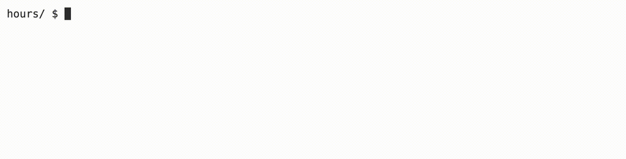

**Implementation Details**

The main function prompts the user for the number of weeks a user has been taking CS50, then creates an array with as many elements. Notice that, after retrieving some data, the program prompts the user to type in either “T” or “A”—”T” should (but doesn’t yet!) print the total number of hours the user entered, while “A” should (but doesn’t yet!) print the average hours the user entered. Notice that the `do while` loop uses `toupper` to capitalize the letter that’s input before it is saved in the variable output. Then, the printf function calls `calc_hours`. Note the syntax involved when passing an array to a function.

To complete `calc_hours`, first total up the hours saved in the array into a new variable. Then, depending on the value of output, return either this sum, or the average number of hours.

**Thought Question**

What is the advantage of using a function to calculate hours?

**Your program should behave per the examples below**

```
hours/ $ ./hours
Number of weeks taking CS50: 3
Week 0 HW Hours: 3
Week 1 HW Hours: 7
Week 2 HW Hours: 10
Enter T for total hours, A for average hours per week: A
6.7 hours

hours/ $ ./hours
Number of weeks taking CS50: 2
Week 0 HW Hours: 2
Week 1 HW Hours: 8
Enter T for total hours, A for average hours per week: T
10.0 hours
```

## W2 [N0 V0w3ls](https://cs50.harvard.edu/x/2023/problems/2/no-vowels/)

**Learning Goals**

- Practice using strings
- Practice using command-line arguments
- Write a program entirely from scratch

**Background**

If you’ve been on the internet, you might have seen “[leetspeak](https://en.wikipedia.org/wiki/Leet)” (or “l33tsp36k” for our purposes!), which involves the substitution of symbols for alphabetical characters, where those symbols somewhat resemble their alphabetical counterparts. In this lab, you’ll write a program to replace certain vowels with digits!

Up until now, you’ve frequently written programs for which you’ve been provided distribution code. You’ll notice when downloading the “distro” for this problem, you start with nothing more than a couple of commonly used libraries and an empty main function. In this problem, you will convert a word, which you will input at the command line, to a corresponding word with numbers replacing vowels.

- Do note that the main function in the distribution code uses `argc` and `argv`. Be sure to use these!
- Be sure to check for the correct number of command-line arguments before doing anything else in your main function.

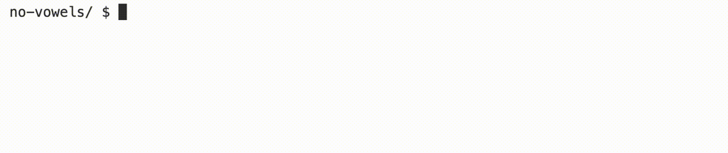

**Implementation Details**

1. Implement your program in a file called `no-vowels.c` in a directory called `no-vowels`.
2. Your program must accept a single command-line argument, which will be the word that you want to convert.
3. If your program is executed without any command-line arguments or with more than one command-line argument, your program should print an error message of your choice (with printf) and return from main a value of 1 (which tends to signify an error) immediately.
4. Your program must contain a function called `replace` which takes a string input and returns a string output.
5. This function will change the following vowels to numbers: `a` becomes 6, `e` becomes 3, `i` becomes 1, `o` becomes 0 and `u` does not change.
6. The input parameter for the `replace` function will be `argv[1]` and the return value is the converted word.
7. The main function will then print the converted word, followed by `\n`.
8. You may want to try using the `switch` statement in your replace function.

**Thought Question**

Why might you want to use command-line arguments rather than `get_string`, `get_int`, etc?

**Your program should behave per the examples below.**

```
no-vowels/ $ ./no-vowels
Usage: ./no-vowels word

no-vowels/ $ ./no-vowels hello
h3ll0

no-vowels/ $ ./no-vowels pseudocode
ps3ud0c0d3
```

## W2 [Password](https://cs50.harvard.edu/x/2023/problems/2/password/)

**Learning Goals**

- Practice iterating through a string
- Practice using the `ctype` library
- Practice using Boolean variables

As we all know by now, it’s important to use passwords that are not easy to guess! Many web apps now require passwords that require not only alphabetical characters, but also number and symbols.

In this lab, the user is prompted for a password, which will then be validated using a function check that you will complete. If the password contains at least one upper case letter, one lower case letter, a number, and a symbol (meaning a printable character that’s not a letter or number, such as ‘!’, ‘$’ and ‘#’), the function should return `true`. If not it should return `false`.

**Implementation Details**

Your function will iterate through the password that’s supplied to it as an argument. Since you have to find at least

- one lower case letter,
- one upper case letter,
- one number, and
- one symbol,

you may want to create a boolean variable for each and set each to false before you iterate through the string. If you then find a number, for instance you can set that boolean to `true`. If all booleans are `true` at the end of the function, it means all criteria are met, and you would return `true`.

**Thought Question**

How many different passwords do you think can be made that are 8 letters long, can use any of 95 printable ASCII characters?

```python
95**8
```

```
6634204312890625
```

**How to Test Your Code**

Your program should behave per the examples below.

```
password/ $ ./password
Enter your password: hello
Your password needs at least one uppercase letter, lowercase letter, number and symbol!

password/ $ ./password
Enter your password: h3ll(
Your password needs at least one uppercase letter, lowercase letter, number and symbol!

password/ $ ./password
Enter your password: h3LL0!
Your password is valid!
```

## W2 Readability

from Harvard CS50 [2023 Week 2](https://cs50.harvard.edu/x/2023/psets/2/readability/)

For this problem, you’ll implement a program that calculates the approximate grade level needed to comprehend some text, per the below.

```
$ ./readability
Text: Congratulations! Today is your day. You're off to Great Places! You're off and away!
Grade 3
```

```python
pwd
```

```
/home/commi/Yandex.Disk/it_learning/02_CS/07_Harvard
```

```python
cd Solutions
wget https://cdn.cs50.net/2022/fall/psets/2/readability.zip
unzip readability.zip
rm -f readability.zip
cd readability
ls
```

```
bash: cd: Solutions: No such file or directory
--2023-11-12 19:14:35--  https://cdn.cs50.net/2022/fall/psets/2/readability.zip
Resolving cdn.cs50.net (cdn.cs50.net)... 65.9.55.69, 65.9.55.9, 65.9.55.119, ...
Connecting to cdn.cs50.net (cdn.cs50.net)|65.9.55.69|:443... connected.
HTTP request sent, awaiting response... 200 OK
Length: 402 [application/zip]
Saving to: ‘readability.zip’

readability.zip     100%[===================>]     402  --.-KB/s    in 0s

2023-11-12 19:14:36 (2,18 MB/s) - ‘readability.zip’ saved [402/402]

Archive:  readability.zip
   creating: readability/
  inflating: readability/readability.c
readability.c
```

If all was successful, you should execute `ls` and see a file named `readability.c`. Executing code `readability.c` should open the file where you will type your code for this problem set. If not, retrace your steps and see if you can determine where you went wrong!

**Background**

According to [Scholastic](https://www.scholastic.com/teachers/teaching-tools/collections/guided-reading-book-lists-for-every-level.html), E.B. *White’s Charlotte’s Web* is between a second- and fourth-grade reading level, and Lois Lowry’s *The Giver* is between an eighth- and twelfth-grade reading level. What does it mean, though, for a book to be at a particular reading level?

Well, in many cases, a human expert might read a book and make a decision on the grade (i.e., year in school) for which they think the book is most appropriate. But an algorithm could likely figure that out too!

So what sorts of traits are characteristic of higher reading levels? Well, longer words probably correlate with higher reading levels. Likewise, longer sentences probably correlate with higher reading levels, too.

A number of “readability tests” have been developed over the years that define formulas for computing the reading level of a text. One such readability test is the **Coleman-Liau index**. The Coleman-Liau index of a text is designed to output that (U.S.) grade level that is needed to understand some text. The formula is

$$index = 0.0588 * L - 0.296 * S - 15.8$$

where

- `L` is the average number of letters per `100` words in the text, and
- `S` is the average number of sentences per `100` words in the text.

Let’s write a program called `readability` that takes a text and determines its reading level. For example, if user types in a line of text from Dr. Seuss, the program should behave as follows:

```
$ ./readability
Text: Congratulations! Today is your day. You're off to Great Places! You're off and away!
Grade 3
```

The text the user inputted has `65` letters, `4` sentences, and `14` words. `65` letters per `14` words is an average of about `464.29` letters per 100 words (because $\frac{65}{14} * 100 = 464.29$). And `4` sentences per `14` words is an average of about `28.57` sentences per `100` words (because $\frac{4}{14} * 100 = 28.57$). Plugged into the Coleman-Liau formula, and rounded to the nearest integer, we get an answer of `3` (because $0.0588 * 464.29 - 0.296 * 28.57 - 15.8 = 3$): so this passage is at a third-grade reading level.

Let’s try another one:

```
$ ./readability
Text: Harry Potter was a highly unusual boy in many ways. For one thing, he hated the summer holidays more than any other time of year. For another, he really wanted to do his homework, but was forced to do it in secret, in the dead of the night. And he also happened to be a wizard.
Grade 5
```

This text has `214` letters, `4` sentences, and `56` words. That comes out to about `382.14` letters per `100` words, and `7.14` sentences per `100` words. Plugged into the Coleman-Liau formula, we get a fifth-grade reading level.

As the average number of letters and words per sentence increases, the Coleman-Liau index gives the text a higher reading level. If you were to take this paragraph, for instance, which has longer words and sentences than either of the prior two examples, the formula would give the text an twelfth-grade reading level.

```
$ ./readability
Text: As the average number of letters and words per sentence increases, the Coleman-Liau index gives the text a higher reading level. If you were to take this paragraph, for instance, which has longer words and sentences than either of the prior two examples, the formula would give the text an twelfth-grade reading level.
Grade 12
```

**Specification**

Design and implement a program, `readability`, that computes the Coleman-Liau index of text.

- Implement your program in a file called `readability.c` in a directory called `readability`.
- Your program must prompt the user for a string of text using `get_string`.
- Your program should count the number of letters, words, and sentences in the text. You may assume that a letter is any lowercase character from `a` to `z` or any uppercase character from `A` to `Z`, any sequence of characters separated by spaces should count as a word, and that any occurrence of a period, exclamation point, or question mark indicates the end of a sentence.
- Your program should print as output `"Grade X"` where X is the grade level computed by the Coleman-Liau formula, rounded to the nearest integer.
- If the resulting index number is `16` or higher (equivalent to or greater than a senior undergraduate reading level), your program should output `"Grade 16+"` instead of giving the exact index number. If the index number is less than `1`, your program should output `"Before Grade 1"`.

**Getting User Input**

Let’s first write some `C` code that just gets some text input from the user, and prints it back out. Specifically, implement in `readability.c` a `main` function that prompts the user with `"Text: "` using `get_string` and then prints that same text using `printf`. And remember, as you work through this program, that if you make use of any library functions, be sure to `#include` any corresponding header files.

The program should behave per the below.

```
$ ./readability
Text: In my younger and more vulnerable years my father gave me some advice that I've been turning over in my mind ever since.
In my younger and more vulnerable years my father gave me some advice that I've been turning over in my mind ever since.
```

**Letters**

Now that you’ve collected input from the user, let’s begin to analyze that input by first counting the number of letters in the text. Consider letters to be uppercase or lowercase alphabetical character, not punctuation, digits, or other symbols.

Add to `readability.c`, below `main`, a function called `count_letters` that takes one argument, a string of text, and that returns an `int`, the number of letters in that text. Be sure to add the function’s prototype, too, atop your file, so that main knows how to call it. Odds are the prototype should resemble the below:

```
int count_letters(string text);
```

Then call that function in `main` so that, instead of printing out the text itself, your program now prints the number of letters in the text.

The program should now behave per the below.

```
$ ./readability
Text: Alice was beginning to get very tired of sitting by her sister on the bank, and of having nothing to do: once or twice she had peeped into the book her sister was reading, but it had no pictures or conversations in it, "and what is the use of a book," thought Alice "without pictures or conversation?"
235 letters
```

**Hint**

Declared in [`ctype.h`](https://www.tutorialspoint.com/c_standard_library/ctype_h.htm) is a function that you might find helpful, per `manual.cs50.io`. If you use it, be sure to include that header file atop your own code!

**Words**

The Coleman-Liau index cares not only about the number of letters but also about the number of words in a sentence. For the purpose of this problem, we’ll consider any sequence of characters separated by a space to be a word (so a hyphenated word like "sister-in-law" should be considered one word, not three).

Add to `readability.c`, below `main`, a function called `count_words` that takes one argument, a string of text, and that returns an int, the number of words in that text. Be sure to add the function’s prototype, too, atop your file, so that `main` knows how to call it. (We leave its prototype to you!)

Then call that function in `main` so that your program also prints the number of words in the text.

You may assume that a sentence:

- will contain at least one word;
- will not start or end with a space; and
- will not have multiple spaces in a row.

You are, of course, welcome to attempt a solution that will tolerate multiple spaces between words or indeed, no words!

The program should now behave per the below.

```
$ ./readability
Text: It was a bright cold day in April, and the clocks were striking thirteen. Winston Smith, his chin nuzzled into his breast in an effort to escape the vile wind, slipped quickly through the glass doors of Victory Mansions, though not quickly enough to prevent a swirl of gritty dust from entering along with him.
250 letters
55 words
```

**Sentences**

The last piece of information that the Coleman-Liau formula cares about, in addition to the number of letters and words, is the number of sentences. Determining the number of sentences can be surprisingly trickly. You might first imagine that a sentence is just any sequence of characters that ends with a period, but of course sentences could end with an exclamation point or a question mark as well. But of course, not all periods necessarily mean the sentence is over. For instance, consider the sentence below.

```
Mr. and Mrs. Dursley, of number four Privet Drive, were proud to say that they were perfectly normal, thank you very much.
```

This is just a single sentence, but there are three periods! For this problem, we’ll ask you to ignore that subtlety: you should consider any sequence of characters that ends with a `.` or a `!` or a `?` to be a sentence (so for the above “sentence”, you should count it as three sentences). In practice, sentence boundary detection needs to be a little more intelligent to handle these cases, but we’ll not worry about that for now.

Add to `readability.c`, below `main`, a function called `count_sentences` that takes one argument, a string of text, and that returns an `int`, the number of sentences in that text. Be sure to add the function’s prototype, too, atop your file, so that `main` knows how to call it. (We again leave its prototype to you!)

Then call that function in `main` so that your program also prints the number of sentences in the text.

The program should now behave per the below.

```
$ ./readability
Text: When he was nearly thirteen, my brother Jem got his arm badly broken at the elbow. When it healed, and Jem's fears of never being able to play football were assuaged, he was seldom self-conscious about his injury. His left arm was somewhat shorter than his right; when he stood or walked, the back of his hand was at right angles to his body, his thumb parallel to his thigh.
295 letters
70 words
3 sentences
```

**Putting it All Together**

Now it’s time to put all the pieces together! Recall that the Coleman-Liau index is computed using the formula:

$$index = 0.0588 * L - 0.296 * S - 15.8$$

where

- `L` is the average number of letters per 100 words in the text, and
- `S` is the average number of sentences per 100 words in the text.

Modify `main` in `readability.c` so that instead of outputting the number of letters, words, and sentences, it instead outputs (only) the grade level as defined by the Coleman-Liau index (e.g. "Grade 2" or "Grade 8" or the like). Be sure to round the resulting index number to the nearest `int`!

Recall that round is declared in math.h, per manual.cs50.io! Recall that, when dividing values of type int in C, the result will also be an int, with any remainder (i.e., digits after the decimal point) discarded. Put another way, the result will be “truncated.” You might want to cast your one or more values to float before performing division when calculating L and S! If the resulting index number is 16 or higher (equivalent to or greater than a senior undergraduate reading level), your program should output "Grade 16+" instead of outputting an exact index number. If the index number is less than 1, your program should output "Before Grade 1".

**Hints**

- Recall that round is declared in `math.h`, per [manual.cs50.io](https://manual.cs50.io/)!
- Recall that, when dividing values of type int in C, the result will also be an `int`, with any remainder (i.e., digits after the decimal point) discarded. Put another way, the result will be “truncated.” You might want to cast your one or more values to float before performing division when calculating L and S!

If the resulting index number is `16` or higher (equivalent to or greater than a senior undergraduate reading level), your program should output `"Grade 16+"` instead of outputting an exact index number. If the index number is less than `1`, your program should output `"Before Grade 1"`.

**How to Test Your Code**

Try running your program on the following texts, to ensure you see the specified grade level. Be sure to copy only the text, no extra spaces.

- One fish. Two fish. Red fish. Blue fish. (Before Grade 1)
- Would you like them here or there? I would not like them here or there. I would not like them anywhere. (Grade 2)
- Congratulations! Today is your day. You're off to Great Places! You're off and away! (Grade 3)
- Harry Potter was a highly unusual boy in many ways. For one thing, he hated the summer holidays more than any other time of year. For another, he really wanted to do his homework, but was forced to do it in secret, in the dead of the night. And he also happened to be a wizard. (Grade 5)
- In my younger and more vulnerable years my father gave me some advice that I've been turning over in my mind ever since. (Grade 7)
- Alice was beginning to get very tired of sitting by her sister on the bank, and of having nothing to do: once or twice she had peeped into the book her sister was reading, but it had no pictures or conversations in it, "and what is the use of a book," thought Alice "without pictures or conversation?" (Grade 8)
- When he was nearly thirteen, my brother Jem got his arm badly broken at the elbow. When it healed, and Jem's fears of never being able to play football were assuaged, he was seldom self-conscious about his injury. His left arm was somewhat shorter than his right; when he stood or walked, the back of his hand was at right angles to his body, his thumb parallel to his thigh. (Grade 8)
- There are more things in Heaven and Earth, Horatio, than are dreamt of in your philosophy. (Grade 9)
- It was a bright cold day in April, and the clocks were striking thirteen. Winston Smith, his chin nuzzled into his breast in an effort to escape the vile wind, slipped quickly through the glass doors of Victory Mansions, though not quickly enough to prevent a swirl of gritty dust from entering along with him. (Grade 10)
- A large class of computational problems involve the determination of properties of graphs, digraphs, integers, arrays of integers, finite families of finite sets, boolean formulas and elements of other countable domains. (Grade 16+)

### Solution in C

`clang -o readability readability.c -lcs50 -lm`

```
#include <cs50.h>
#include <stdio.h>
#include <ctype.h>
#include <string.h>
#include <math.h>

int count_letters(char *text);
int count_words(char *text);
int count_sentences(char *text);

int main(void)
{
	char *text = get_string("Text: ");
	// printf("%s\n", text);

	int letters = count_letters(text);
	int words = count_words(text);
	int sentences = count_sentences(text);

	double L = (double)letters / (double)words * 100;
	double S = (double)sentences / (double)words * 100;
    double index = 0.0588*L - 0.296*S - 15.8;

	int grade = (int)round(index);

//	printf("%i letters\n", letters);
//	printf("%i words\n", words);
//	printf("%i sentences\n", sentences);

	if (grade < 1)
	{
		printf("Before Grade 1\n");
	}
	else if (grade > 15)
	{
		printf("Grade 16+\n");
	}
	else
	{
		printf("Grade %i\n", grade);
	}
	return 0;
}

int count_letters(char *text)
{
	int letters_sum = 0;

	for (int i = 0; i < strlen(text); i++)
	{
		char letter = text[i];
		if (islower(letter) || isupper(letter))
		{
			letters_sum++;
		}
	}

	return letters_sum;
}

int count_words(char *text)
{
	int words = 1;

	for (int i = 0; i < strlen(text); i++)
	{
		if (isspace(text[i]))
		{
			words++;
		}
	}

	return words;
}


int count_sentences(char *text)
{
	int sentences = 0;
	int p = (int)'.';

	for (int i = 0; i < strlen(text); i++)
	{
		char s = text[i];

		if (s == p && text[i+1] == p && text[i+2] == p)
		{
			sentences++;
			i += 2;
		}
		else if (s == p || s == (int)'!' || s == (int)'?')
		{
			sentences++;
		}
	}

	return sentences;
}
```

# Week 3 Algorithms

## W3 Recursion examples

```python
height = int(input("Height: "))

def draw(n):

    # base case
    if n < 1:
        return None

    # recursive case
    draw(n - 1)
    for i in range(n):
        print('#', end='')
    print('\n', end='')

draw(height)
```

```
#
##
###
####
```

Multiple recursive cases

```python
def collatz(n):
    # base case
    if n == 1:
        return 0
    # even case
    elif n%2 == 0:
        return 1 + collatz(n/2)
    # odd case
    else:
        return 1 + collatz(3*n + 1)

collatz(3)
```

```
7
```

## W3 Factorial exercise

Recursive function

```python
def factorial(n):

    # base case
    if n == 1:
        return 1
    # recursive case
    elif n > 1:
        return n * factorial(n-1)
    else:
        print("The number is not natural")
        exit(1)

factorial(4)
```

```
24
```

```python
def factorial(n):
    # base case
    if n == 1:
        return 1
    # recursive case
    return n * factorial(n-1)

factorial(4)
```

```
24
```

## W3 [Plurality](https://cs50.harvard.edu/x/2023/psets/3/plurality/)

For this program, you’ll implement a program that runs a plurality election, per the below.

```
$ ./plurality Alice Bob Charlie
Number of voters: 4
Vote: Alice
Vote: Bob
Vote: Charlie
Vote: Alice
Alice
```

**Background**

Elections come in all shapes and sizes. In the UK, the Prime Minister is officially appointed by the monarch, who generally chooses the leader of the political party that wins the most seats in the House of Commons. The United States uses a multi-step Electoral College process where citizens vote on how each state should allocate Electors who then elect the President.

Perhaps the simplest way to hold an election, though, is via a method commonly known as the “plurality vote” (also known as “first-past-the-post” or “winner take all”). In the plurality vote, every voter gets to vote for one candidate. At the end of the election, whichever candidate has the greatest number of votes is declared the winner of the election.

**Understanding**

Let’s take a look at `plurality.c` and read through the distribution code that’s been provided to you.

The line `#define MAX 9` is some syntax used here to mean that `MAX` is a constant (equal to `9`) that can be used throughout the program. Here, it represents the maximum number of candidates an election can have.

The file then defines a `struct` called a `candidate`. Each candidate has two fields: a `string` called `name` representing the candidate’s name, and an `int` called `votes` representing the number of votes the candidate has. Next, the file defines a `global array` of candidates, where each element is itself a candidate.

Now, take a look at the `main` function itself. See if you can find where the program sets a global variable `candidate_count` representing the number of candidates in the election, copies command-line arguments into the array candidates, and asks the user to type in the number of voters. Then, the program lets every voter type in a vote (see how?), calling the vote function on each candidate voted for. Finally, main makes a call to the print_winner function to print out the winner (or winners) of the election.

If you look further down in the file, though, you’ll notice that the `vote` and `print_winner` functions have been left blank. This part is up to you to complete!

**Specification**

Complete the implementation of `plurality.c` in such a way that the program simulates a plurality vote election.

- Complete the `vote` function. `vote` takes a single argument, a string called name, representing the name of the candidate who was voted for.
  - If name matches one of the names of the candidates in the election, then update that candidate’s vote total to account for the new vote. The vote function in this case should return `true` to indicate a successful ballot.
  - If name does not match the name of any of the candidates in the election, no vote totals should change, and the `vote` function should return `false` to indicate an invalid ballot.
  - You may assume that no two candidates will have the same name.
- Complete the `print_winner` function.
  - The function should print out the name of the candidate who received the most votes in the election, and then print a newline.
  - It is possible that the election could end in a tie if multiple candidates each have the maximum number of votes. In that case, you should output the names of each of the winning candidates, each on a separate line.

You should not modify anything else in `plurality.c` other than the implementations of the `vote` and `print_winner` functions (and the inclusion of additional header files, if you’d like).

**Usage**

Your program should behave per the examples below.

```
$ ./plurality Alice Bob
Number of voters: 3
Vote: Alice
Vote: Bob
Vote: Alice
Alice

$ ./plurality Alice Bob
Number of voters: 3
Vote: Alice
Vote: Charlie
Invalid vote.
Vote: Alice
Alice

$ ./plurality Alice Bob Charlie
Number of voters: 5
Vote: Alice
Vote: Charlie
Vote: Bob
Vote: Bob
Vote: Alice
Alice
Bob
```

```
#include <cs50.h>
#include <stdio.h>
#include <string.h>

// Max number of candidates
#define MAX 9

// Candidates have name and vote count
typedef struct
{
    string name;
    int votes;
}
candidate;

// Array of candidates
candidate candidates[MAX];

// Number of candidates
int candidate_count;

// Function prototypes
bool vote(string name);
void print_winner(void);

int main(int argc, string argv[])
{
    // Check for invalid usage
    if (argc < 2)
    {
        printf("Usage: plurality [candidate ...]\n");
        return 1;
    }

    // Populate array of candidates
    candidate_count = argc - 1;
    if (candidate_count > MAX)
    {
        printf("Maximum number of candidates is %i\n", MAX);
        return 2;
    }
    for (int i = 0; i < candidate_count; i++)
    {
        candidates[i].name = argv[i + 1];
        candidates[i].votes = 0;
    }

    int voter_count = get_int("Number of voters: ");

    // Loop over all voters
    for (int i = 0; i < voter_count; i++)
    {
        string name = get_string("Vote: ");

        // Check for invalid vote
        if (!vote(name))
        {
            printf("Invalid vote.\n");
        }
    }

    // Display winner of election
    print_winner();
}

// Update vote totals given a new vote
bool vote(string name)
{
    // TODO
    return false;
}

// Print the winner (or winners) of the election
void print_winner(void)
{
    // TODO
    return;
}
```

## W3 [Tideman](https://cs50.harvard.edu/x/2023/psets/3/tideman/)

For this program, you’ll implement a program that runs a Tideman election, per the below.

```
$ ./tideman Alice Bob Charlie
Number of voters: 5
Rank 1: Alice
Rank 2: Charlie
Rank 3: Bob

Rank 1: Alice
Rank 2: Charlie
Rank 3: Bob

Rank 1: Bob
Rank 2: Charlie
Rank 3: Alice

Rank 1: Bob
Rank 2: Charlie
Rank 3: Alice

Rank 1: Charlie
Rank 2: Alice
Rank 3: Bob

Charlie
```

**Background**

You already know about plurality elections, which follow a very simple algorithm for determining the winner of an election: every voter gets one vote, and the candidate with the most votes wins.

But the plurality vote does have some disadvantages. What happens, for instance, in an election with three candidates, and the ballots below are cast?

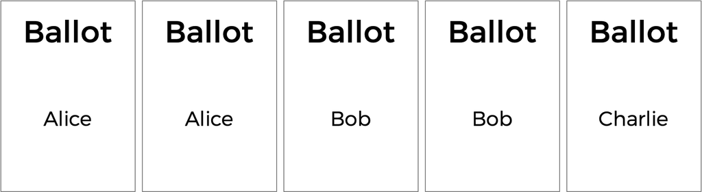

A plurality vote would here declare a tie between Alice and Bob, since each has two votes. But is that the right outcome?

There’s another kind of voting system known as a **ranked-choice voting system**. In a ranked-choice system, voters can vote for more than one candidate. Instead of just voting for their top choice, they can rank the candidates in order of preference. The resulting ballots might therefore look like the below.

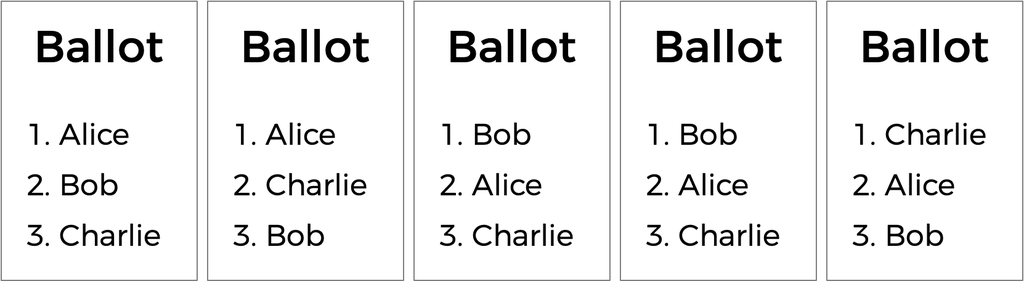

Here, each voter, in addition to specifying their first preference candidate, has also indicated their second and third choices. And now, what was previously a tied election could now have a winner. The race was originally tied between Alice and Bob. But the voter who chose Charlie preferred Alice over Bob, so Alice could here be declared the winner.

Ranked choice voting can also solve yet another potential drawback of plurality voting. Take a look at the following ballots.

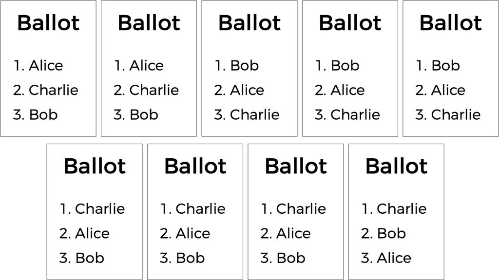

Who should win this election? In a **plurality vote** where each voter chooses their first preference only, Charlie wins this election with four votes compared to only three for Bob and two for Alice. (Note that, if you’re familiar with the instant **runoff voting system**, Charlie wins here under that system as well). Alice, however, might reasonably make the argument that she should be the winner of the election instead of Charlie: after all, of the nine voters, a majority (five of them) preferred Alice over Charlie, so most people would be happier with Alice as the winner instead of Charlie.

Alice is, in this election, the so-called “Condorcet winner” of the election: the person who would have won any head-to-head matchup against another candidate. If the election had been just Alice and Bob, or just Alice and Charlie, Alice would have won.

The **Tideman voting method** (also known as “**ranked pairs**”) is a ranked-choice voting method that’s guaranteed to produce the Condorcet winner of the election if one exists.

Generally speaking, the Tideman method works by constructing a “graph” of candidates, where an arrow (i.e. edge) from candidate `A` to candidate `B` indicates that candidate `A` wins against candidate `B` in a head-to-head matchup. The graph for the above election, then, would look like the below.

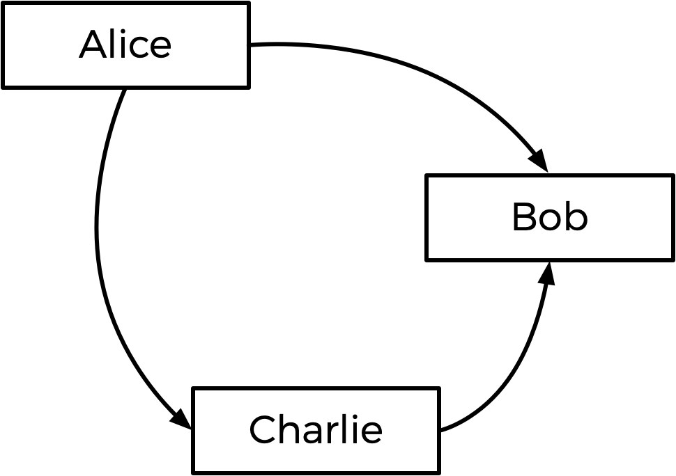

The arrow from Alice to Bob means that more voters prefer Alice to Bob (5 prefer Alice, 4 prefer Bob). Likewise, the other arrows mean that more voters prefer Alice to Charlie, and more voters prefer Charlie to Bob.

Looking at this graph, the Tideman method says the winner of the election should be the “source” of the graph (i.e. the candidate that has no arrow pointing at them). In this case, the source is Alice — Alice is the only one who has no arrow pointing at her, which means nobody is preferred head-to-head over Alice. Alice is thus declared the winner of the election.

It’s possible, however, that when the arrows are drawn, there is no Condorcet winner. Consider the below ballots.

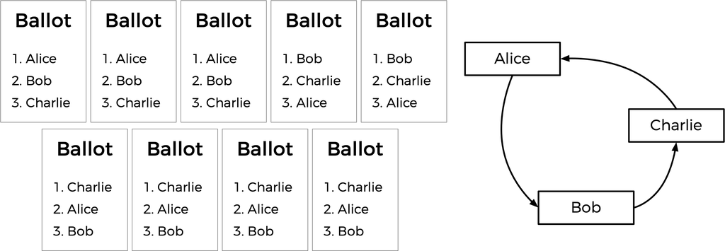

```python
import numpy as np

alice = np.mean([1, 1, 1, 3, 3, 2, 2, 2, 2])
bob = np.mean([2, 2, 2, 1, 1, 3, 3, 3, 3])
charlie = np.mean([3, 3, 3, 2, 2, 1, 1, 1, 1])

print(alice, bob, charlie)
```

```
1.8888888888888888 2.2222222222222223 1.8888888888888888
```

Between Alice and Bob, Alice is preferred over Bob by a 7-2 margin. Between Bob and Charlie, Bob is preferred over Charlie by a 5-4 margin. But between Charlie and Alice, Charlie is preferred over Alice by a 6-3 margin. If we draw out the graph, there is no source! We have a cycle of candidates, where Alice beats Bob who beats Charlie who beats Alice (much like a game of rock-paper-scissors). In this case, it looks like there’s no way to pick a winner.

To handle this, the Tideman algorithm must be careful to avoid creating cycles in the candidate graph. How does it do this? The algorithm locks in the strongest edges first, since those are arguably the most significant. In particular, the Tideman algorithm specifies that matchup edges should be “locked in” to the graph one at a time, based on the “strength” of the victory (the more people who prefer a candidate over their opponent, the stronger the victory). So long as the edge can be locked into the graph without creating a cycle, the edge is added; otherwise, the edge is ignored.

How would this work in the case of the votes above? Well, the biggest margin of victory for a pair is Alice beating Bob, since 7 voters prefer Alice over Bob (no other head-to-head matchup has a winner preferred by more than 7 voters). So the Alice-Bob arrow is locked into the graph first. The next biggest margin of victory is Charlie’s 6-3 victory over Alice, so that arrow is locked in next.

Next up is Bob’s 5-4 victory over Charlie. But notice: if we were to add an arrow from Bob to Charlie now, we would create a cycle! Since the graph can’t allow cycles, we should skip this edge, and not add it to the graph at all. If there were more arrows to consider, we would look to those next, but that was the last arrow, so the graph is complete.

This step-by-step process is shown below, with the final graph at right.

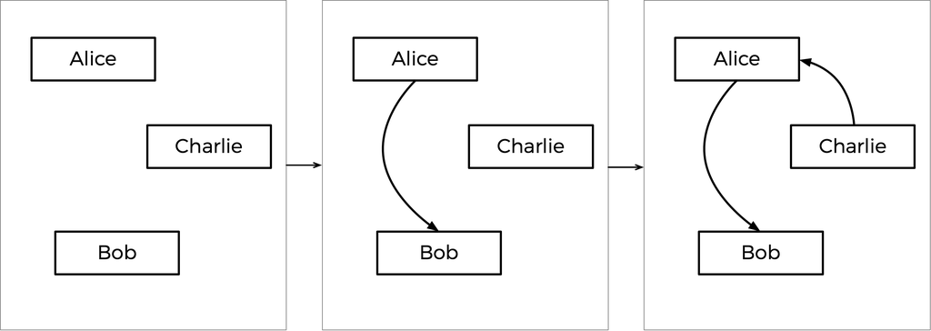

Based on the resulting graph, Charlie is the source (there’s no arrow pointing towards Charlie), so Charlie is declared the winner of this election.

Put more formally, the Tideman voting method consists of three parts:

- Tally: Once all of the voters have indicated all of their preferences, determine, for each pair of candidates, who the preferred candidate is and by what margin they are preferred.
- Sort: Sort the pairs of candidates in decreasing order of strength of victory, where strength of victory is defined to be the number of voters who prefer the preferred candidate.
- Lock: Starting with the strongest pair, go through the pairs of candidates in order and “lock in” each pair to the candidate graph, so long as locking in that pair does not create a cycle in the graph.

Once the graph is complete, the source of the graph (the one with no edges pointing towards it) is the winner!

**Understanding**

Let’s take a look at `tideman.c`.

First, notice the two-dimensional array preferences. The integer `preferences[i][j]` will represent the number of voters who prefer candidate `i` over candidate `j`.

The file also defines another two-dimensional array, called `locked`, which will represent the candidate graph. `locked` is a `boolean` array, so `locked[i][j]` being `true` represents the existence of an edge pointing from candidate `i` to candidate `j`; `false` means there is no edge. (If curious, this representation of a graph is known as an “[adjacency matrix](https://www.geeksforgeeks.org/graph-and-its-representations/)”).

Next up is a `struct` called `pair`, used to represent a pair of candidates: each pair includes the `winner`’s candidate index and the `loser`’s candidate index.

The candidates themselves are stored in the array `candidates`, which is an array of strings representing the names of each of the candidates. There’s also an array of `pairs`, which will represent all of the pairs of candidates (for which one is preferred over the other) in the election.

The program also has two global variables: `pair_count` and `candidate_count`, representing the number of pairs and number of candidates in the arrays pairs and candidates, respectively.

Now onto `main`. Notice that after determining the number of candidates, the program loops through the `locked` graph and initially sets all of the values to `false`, which means our initial graph will have no edges in it.

Next, the program loops over all of the voters and collects their preferences in an array called `ranks` (via a call to `vote`), where `ranks[i]` is the index of the candidate who is the `i`th preference for the voter. These ranks are passed into the `record_preference` function, whose job is to take those ranks and update the global `preferences` variable.

Once all of the votes are in, the pairs of candidates are added to the `pairs` array via a call to `add_pairs`, sorted via a call to `sort_pairs`, and locked into the graph via a call to `lock_pairs`. Finally, `print_winner` is called to print out the name of the election’s winner!

Further down in the file, you’ll see that the functions vote, record_preference, add_pairs,sort_pairs, lock_pairs, and print_winner are left blank. That’s up to you!

**Specification**

Complete the implementation of `tideman.c` in such a way that it simulates a Tideman election.

- Complete the `vote` function.
  - The function takes arguments `rank`, `name`, and `ranks`.
  - If name is a match for the name of a valid candidate, then you should update the `ranks` array to indicate that the voter has the candidate as their rank preference (where `0` is the first preference, `1` is the second preference, etc.). Recall that `ranks[i]` here represents the user’s `i`th preference.
  - The function should return `true` if the rank was successfully recorded, and `false` otherwise (if, for instance, `name` is not the name of one of the candidates).
  - You may assume that no two candidates will have the same name.
- Complete the `record_preferences` function.
  - The function is called once for each voter, and takes as argument the `ranks` array (recall that `ranks[i]` is the voter’s `i`th preference, where `ranks[0]` is the first preference).
  - The function should update the global `preferences` array to add the current voter’s preferences. Recall that `preferences[i][j]` should represent the number of voters who prefer candidate `i` over candidate `j`.
  - You may assume that every voter will rank each of the candidates.
- Complete the `add_pairs` function.
  - The function should add all pairs of candidates where one candidate is preferred to the `pairs` array. A pair of candidates who are tied (one is not preferred over the other) should not be added to the array.
  - The function should update the global variable `pair_count` to be the number of pairs of candidates. (The pairs should thus all be stored between `pairs[0]` and `pairs[pair_count - 1]`, inclusive).
- Complete the `sort_pairs` function.
  - The function should sort the `pairs` array in decreasing order of strength of victory, where strength of victory is defined to be the number of voters who prefer the preferred candidate.
  - If multiple pairs have the same strength of victory, you may assume that the order does not matter.
- Complete the `lock_pairs` function.
  - The function should create the `locked` graph, adding all edges in decreasing order of victory strength so long as the edge would not create a cycle.
- Complete the `print_winner` function.
  - The function should print out the name of the candidate who is the source of the graph. You may assume there will not be more than one source.

You should not modify anything else in `tideman.c` other than the implementations of the `vote`, `record_preferences`, `add_pairs`, `sort_pairs`, `lock_pairs`, and `print_winner` functions (and the inclusion of additional header files, if you’d like). You are permitted to add additional functions to `tideman.c`, so long as you do not change the declarations of any of the existing functions.

```
#include <cs50.h>
#include <stdio.h>

// Max number of candidates
#define MAX 9

// preferences[i][j] is number of voters who prefer i over j
int preferences[MAX][MAX];

// locked[i][j] means i is locked in over j
bool locked[MAX][MAX];

// Each pair has a winner, loser
typedef struct
{
    int winner;
    int loser;
}
pair;

// Array of candidates
string candidates[MAX];
pair pairs[MAX * (MAX - 1) / 2];

int pair_count;
int candidate_count;

// Function prototypes
bool vote(int rank, string name, int ranks[]);
void record_preferences(int ranks[]);
void add_pairs(void);
void sort_pairs(void);
void lock_pairs(void);
void print_winner(void);

int main(int argc, string argv[])
{
    // Check for invalid usage
    if (argc < 2)
    {
        printf("Usage: tideman [candidate ...]\n");
        return 1;
    }

    // Populate array of candidates
    candidate_count = argc - 1;
    if (candidate_count > MAX)
    {
        printf("Maximum number of candidates is %i\n", MAX);
        return 2;
    }
    for (int i = 0; i < candidate_count; i++)
    {
        candidates[i] = argv[i + 1];
    }

    // Clear graph of locked in pairs
    for (int i = 0; i < candidate_count; i++)
    {
        for (int j = 0; j < candidate_count; j++)
        {
            locked[i][j] = false;
        }
    }

    pair_count = 0;
    int voter_count = get_int("Number of voters: ");

    // Query for votes
    for (int i = 0; i < voter_count; i++)
    {
        // ranks[i] is voter's ith preference
        int ranks[candidate_count];

        // Query for each rank
        for (int j = 0; j < candidate_count; j++)
        {
            string name = get_string("Rank %i: ", j + 1);

            if (!vote(j, name, ranks))
            {
                printf("Invalid vote.\n");
                return 3;
            }
        }

        record_preferences(ranks);

        printf("\n");
    }

    add_pairs();
    sort_pairs();
    lock_pairs();
    print_winner();
    return 0;
}

// Update ranks given a new vote
bool vote(int rank, string name, int ranks[])
{
    // TODO
    return false;
}

// Update preferences given one voter's ranks
void record_preferences(int ranks[])
{
    // TODO
    return;
}

// Record pairs of candidates where one is preferred over the other
void add_pairs(void)
{
    // TODO
    return;
}

// Sort pairs in decreasing order by strength of victory
void sort_pairs(void)
{
    // TODO
    return;
}

// Lock pairs into the candidate graph in order, without creating cycles
void lock_pairs(void)
{
    // TODO
    return;
}

// Print the winner of the election
void print_winner(void)
{
    // TODO
    return;
}
```

**Usage**

Your program should behave per the example below:

```
./tideman Alice Bob Charlie
Number of voters: 5
Rank 1: Alice
Rank 2: Charlie
Rank 3: Bob

Rank 1: Alice
Rank 2: Charlie
Rank 3: Bob

Rank 1: Bob
Rank 2: Charlie
Rank 3: Alice

Rank 1: Bob
Rank 2: Charlie
Rank 3: Alice

Rank 1: Charlie
Rank 2: Alice
Rank 3: Bob

Charlie
```

**Testing**

Be sure to test your code to make sure it handles…

- An election with any number of candidate (up to the MAX of 9)
- Voting for a candidate by name
- Invalid votes for candidates who are not on the ballot
- Printing the winner of the election.

## W3 [Recursive `atoi`](https://cs50.harvard.edu/x/2023/problems/3/atoi/)

**Learning Goals**

- Deepen an understanding of strings
- Practice creating recursive functions

**Background**

Imagine that you travel back in time to the 1970’s, when the C programming language was first created. You are hired as a programmer to come up with a way to convert strings to ints. (You may have used a function just like this in Week 2, called atoi). You want to be thorough in your development process and plan to try several approaches before deciding on the most efficient.

In this problem, you will start with a simple implementation of `atoi` that handles positive ints using loops. You want to rework this into an implementation that uses recursion. Recusive functions can be memory intensive and are not always the best solution, but there are some problems in which using recursion can provide a simpler and more elegant solution.

(Scroll to the bottom of this page to see what an implementation of `atoi` might actually look like.)

**Implementation Details**

In the recursive version of convert, start with the last `char` and `convert` it into an integer value. Then shorten the string, removing the last `char`, and then recursively call `convert` using the shortened string as input, where the next `char` will be processed.

**Thought Question**

Why do you need a base case whenever you create a recursive function?

**How to Test Your Code**

Your program should behave per the examples below.

```
atoi/ $ ./atoi
Enter a positive integer: 3432
3432
atoi/ $ ./atoi
Enter a positive integer: 98765
98765
```

**A More Thorough Implementation**

The actual version of `atoi` must handle negative numbers, as well as leading spaces and non-numeric characters. It might look something like this:

```
#include <stdio.h>

// Iterative function to implement `atoi()` function in C
long atoi(const char S[])
{
    long num = 0;
    int i = 0, sign = 1;

    // skip white space characters
    while (S[i] == ' ' || S[i] == '\n' || S[i] == '\t') {
        i++;
    }

    // note sign of the number
    if (S[i] == '+' || S[i] == '-')
    {
        if (S[i] == '-') {
            sign = -1;
        }
        i++;
    }

    // run till the end of the string is reached, or the
    // current character is non-numeric
    while (S[i] && (S[i] >= '0' && S[i] <= '9'))
    {
        num = num * 10 + (S[i] - '0');
        i++;
    }

    return sign * num;
}

// Implement `atoi()` function in C
int main(void)
{
    char S[] = " -1234567890";

    printf("%ld ", atoi(S));

    return 0;
}
```

From techiedelight.com/implement-atoi-function-c-iterative-recursive.

```python
#include <stdio.h>

// Iterative function to implement `atoi()` function in C
long atoi(const char S[])
{
    long num = 0;
    int i = 0, sign = 1;

    // skip white space characters
    while (S[i] == ' ' || S[i] == '\n' || S[i] == '\t') {
        i++;
    }

    // note sign of the number
    if (S[i] == '+' || S[i] == '-')
    {
        if (S[i] == '-') {
            sign = -1;
        }
        i++;
    }

    // run till the end of the string is reached, or the
    // current character is non-numeric
    while (S[i] && (S[i] >= '0' && S[i] <= '9'))
    {
        num = num * 10 + (S[i] - '0');
        i++;
    }

    return sign * num;
}

// Implement `atoi()` function in C
int main(void)
{
    char S[] = " -1234567890";
    printf("%ld ", atoi(S));
    return 0;
}
```

```
-1234567890
```

# Week 4 Memory

## Lab 4: [Smiley](https://cs50.harvard.edu/x/2023/labs/4/smiley/)

- Learn how to work with images
- Practice manipulating pixels

**Background**

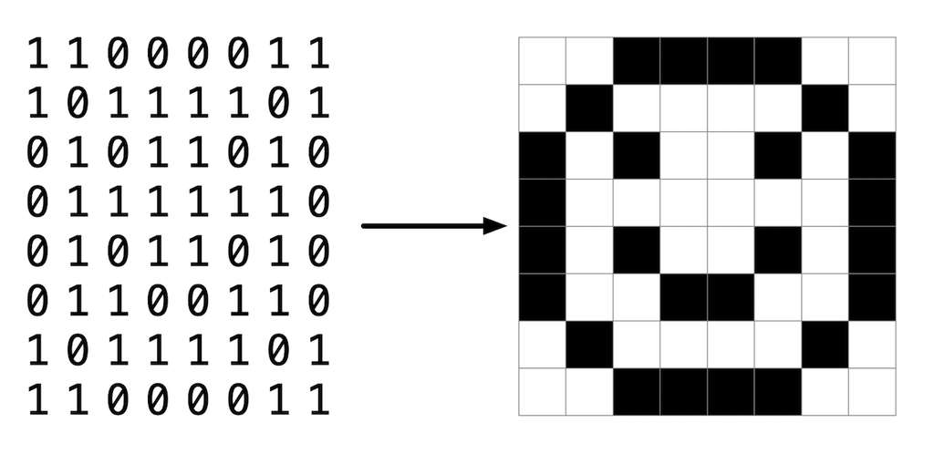

You’ve seen in lecture a bit about how images are stored on a computer. In this lab, you’ll practice working with a BMP file, actually the smiley face pictured here, and change all the black pixels to a color of your choosing.

However, the smiley face you’ll be working with is not just made of of 0’s and 1’s, or black and white pixels, but consists of 24 bits per pixel. It uses eight bits to represent red values, eight bits for green and eight bits for blue. Since each color uses eight bits or one byte, we can use a number in the range of `0` to `255` to represent its color value. In hexadecimal, this is represented by `0x00` to `0xff`. By mixing together these red, green and blue values, we can create millions of possible colors.

If you look at `bmp.h`, one of the the helper files in the distribution code, you’ll see how each RGB triple is represented by a `struct` like:

```
typedef struct
{
    BYTE rgbtBlue;
    BYTE rgbtGreen;
    BYTE rgbtRed;
}
RGBTRIPLE;
```

where `BYTE` is defined as an 8-bit integer.

You’ll notice several files provided in the distribution code to handle the reading and writing of an image file, as well as handling the image’s metadata or “headers”. You’ll be completing the function colorize in `helpers.c`, which already has as input parameters, the image’s height, width, and a two-dimensional array of `RGBTRIPLE`’s which create the image itself.

> Hints: If we were to save the first pixel as `RGBTRIPLE pixel = image[0][0]` we could then access each of the individual colors of pixel as `pixel.rgbtBlue`, `pixel.rgbtGreen`, and `pixel.rgbtRed`.

**Getting Started**

Use Bash:

```python
cd Solutions
wget https://cdn.cs50.net/2022/fall/labs/4/smiley.zip
unzip smiley.zip
rm smiley.zip
cd smiley
ls
```

```
--2023-08-15 00:42:18--  https://cdn.cs50.net/2022/fall/labs/4/smiley.zip
Resolving cdn.cs50.net (cdn.cs50.net)... 65.9.55.119, 65.9.55.9, 65.9.55.69, ...
Connecting to cdn.cs50.net (cdn.cs50.net)|65.9.55.119|:443... connected.
HTTP request sent, awaiting response... 200 OK
Length: 3155 (3,1K) [application/zip]
Saving to: ‘smiley.zip’

smiley.zip          100%[===================>]   3,08K  --.-KB/s    in 0s

2023-08-15 00:42:19 (49,8 MB/s) - ‘smiley.zip’ saved [3155/3155]

Archive:  smiley.zip
   creating: smiley/
  inflating: smiley/Makefile
  inflating: smiley/bmp.h
  inflating: smiley/helpers.c
  inflating: smiley/smiley.bmp
  inflating: smiley/helpers.h
  inflating: smiley/colorize.c
bmp.h  colorize.c  helpers.c  helpers.h  Makefile  smiley.bmp
```

and you should see `bmp.h`, `colorize.c`, `helpers.c`, `helpers.h`, `Makefile`, and `smiley.bmp`.

**Implementation Details**

Open up `helpers.c` and notice that the `colorize` function is incomplete. Note that the image’s height, width and a two-dimensional array of pixels is set up as the input parameters for this function. You are to implement this function to change all the black pixels in the image to a color of your choosing.

You can compile your code by simply typing `make` at the `$` prompt.

You then execute the program by typing:

`./colorize smiley.bmp outfile.bmp`

where `outfile.bmp` is the name of the new bmp you are creating.

```python
cat helpers.c
```

```
#include "helpers.h"

void colorize(int height, int width, RGBTRIPLE image[height][width])
{
    // Change all black pixels to a color of your choosing
}
```

```python
cat colorize.c
```

```
#include <stdio.h>
#include <stdlib.h>

#include "helpers.h"

int main(int argc, char *argv[])
{
    // ensure proper usage
    if (argc != 3)
    {
        printf("Usage: colorize infile outfile\n");
        return 1;
    }

    // remember filenames
    char *infile = argv[1];
    char *outfile = argv[2];

    // open input file
    FILE *inptr = fopen(infile, "r");
    if (inptr == NULL)
    {
        printf("Could not open %s.\n", infile);
        return 4;
    }

    // open output file
    FILE *outptr = fopen(outfile, "w");
    if (outptr == NULL)
    {
        fclose(inptr);
        printf("Could not create %s.\n", outfile);
        return 5;
    }

    // read infile's BITMAPFILEHEADER
    BITMAPFILEHEADER bf;
    fread(&bf, sizeof(BITMAPFILEHEADER), 1, inptr);

    // read infile's BITMAPINFOHEADER
```

[output cut: 56 more lines]

```
            fputc(0x00, outptr);
        }
    }

    // free memory for image
    free(image);

    // close infile
    fclose(inptr);

    // close outfile
    fclose(outptr);

    return 0;
}
```

**Thought Question**

- How do you think you represent a black pixel when using a 24-bit color BMP file?
- Is this the same or different when mixing paints to repesent various colors?

Your program should behave per the examples below.

```
smiley/ $ ./colorize smiley.bmp smiley_out.bmp
```

When your program is working correctly, you should see a new file, `smiley_out.bmp` in your `smiley` directory. Open it up and see if the black pixels are now the color you’ve specified.

**Solution**

```
#include "helpers.h"

void colorize(int height, int width, RGBTRIPLE [height][width])
{
	// Change all black image[i][j]s to a color of your choosing
	for (int i = 0; i < height; i++)
	{
		for (int j = 0; j < width; j++)
		{
			if (image[i][j].rgbtRed == 0x00 && image[i][j].rgbtGreen == 0x00 && image[i][j].rgbtBlue == 0x00)
			{
				image[i][j].rgbtBlue = 0xff;
				// image[i][j].rgbtRed = 0x88;
				// image[i][j].rgbtGreen = 0xa4;
			}
		}
	}
}
```

## Lab 4: [Volume](https://cs50.harvard.edu/x/2023/labs/4/volume/)

Write a program to modify the volume of an audio file.

```
$ ./volume INPUT.wav OUTPUT.wav 2.0
```

Where `INPUT.wav` is the name of an original audio file and `OUTPUT.wav` is the name of an audio file with a volume that has been scaled by the given factor (e.g., 2.0).

**WAV Files**

[WAV files](https://docs.fileformat.com/audio/wav/) are a common file format for representing audio. WAV files store audio as a sequence of “samples”: numbers that represent the value of some audio signal at a particular point in time. WAV files begin with a **44-byte “header”** that contains information about

- the file itself, including the size of the file, the number of samples per second, and
- the size of each sample.

After the header, the WAV file contains a **sequence of samples**, each a single **2-byte** (16-bit) integer representing the audio signal at a particular point in time.

Scaling each sample value by a given factor has the effect of changing the volume of the audio. Multiplying each sample value by 2.0, for example, will have the effect of doubling the volume of the origin audio. Multiplying each sample by 0.5, meanwhile, will have the effect of cutting the volume in half.

**Types**

So far, we’ve seen a number of different types in C, including `int`, `bool`, `char`, `double`, `float`, and `long`. Inside a header file called `stdint.h`are the declarations of a number of other types that allow us to very precisely define

- the size (in bits) and
- sign (signed or unsigned)

of an integer. Two types in particular will be useful to us in this lab.

- `uint8_t` is a type that stores an 8-bit unsigned (i.e., not negative) integer. We can treat each byte of a WAV file’s header as a `uint8_t` value.
- `int16_t` is a type that stores a 16-bit signed (i.e., positive or negative) integer. We can treat each sample of audio in a WAV file as an `int16_t` value.

Use Bash:

```python
cd Solutions
wget https://cdn.cs50.net/2022/fall/labs/4/volume.zip
unzip volume.zip
rm volume.zip
cd volume
ls
```

```
--2023-08-18 21:31:56--  https://cdn.cs50.net/2022/fall/labs/4/volume.zip
Resolving cdn.cs50.net (cdn.cs50.net)... 65.9.55.69, 65.9.55.105, 65.9.55.119, ...
Connecting to cdn.cs50.net (cdn.cs50.net)|65.9.55.69|:443... connected.
HTTP request sent, awaiting response... 200 OK
Length: 313630 (306K) [application/zip]
Saving to: ‘volume.zip’

volume.zip          100%[===================>] 306,28K  --.-KB/s    in 0,1s

2023-08-18 21:31:56 (2,00 MB/s) - ‘volume.zip’ saved [313630/313630]

Archive:  volume.zip
   creating: volume/
  inflating: volume/volume.c
  inflating: volume/input.wav
input.wav  volume.c
```

and you should see a `volume.c` file alongside an `input.wav` file.

**Implementation Details**

Complete the implementation of `volume.c`, such that it changes the volume of a sound file by a given factor.

- The program accepts three command-line arguments: `input` represents the name of the original audio file, `output` represents the name of the new audio file that should be generated, and `factor` is the amount by which the volume of the original audio file should be scaled.
  - For example, if factor is 2.0, then your program should double the volume of the audio file in input and save the newly generated audio file in output.
- Your program should first read the header from the input file and write the header to the output file. Recall that this header is always exactly 44 bytes long.
  - Note that `volume.c` already defines a variable for you called `HEADER_SIZE`, equal to the number of bytes in the header.
- Your program should then read the rest of the data from the WAV file, one 16-bit (2-byte) sample at a time. Your program should multiply each sample by the factor and write the new sample to the output file.
  - You may assume that the WAV file will use 16-bit signed values as samples. In practice, WAV files can have varying numbers of bits per sample, but we’ll assume 16-bit samples for this lab.
- Your program, if it uses `malloc`, must not leak any memory.

**Hints**

You’ll likely want to create an array of bytes to store the data from the WAV file header that you’ll read from the input file. Using the `uint8_t` type to represent a byte, you can create an array of `n` bytes for your header with syntax like

```
uint8_t header[n];
```

replacing `n` with the number of bytes. You can then use header as an argument to fread or fwrite to read into or write from the header.

You’ll likely want to create a “buffer” in which to store audio samples that you read from the WAV file. Using the `int16_t` type to store an audio sample, you can create a buffer variable with syntax like

```
int16_t buffer;
```

You can then use `&buffer` as an argument to fread or fwrite to read into or write from the buffer. (Recall that the `&` operator is used to get the address of the variable.)

You may find the documentation for fread and fwrite helpful here.

- In particular, note that both functions accept the following arguments:
  - `ptr`: a pointer to the location in memory to store data (when reading from a file) or from which to write data (when writing data to a file)
  - `size`: the number of bytes in an item of data
  - `nmemb`: the number of items of data (each of size bytes) to read or write
  - `stream`: the file pointer to be read from or written to
- Per its documentation, fread will return the number of items of data successfully read. You may find this useful to check for when you’ve reached the end of the file!

**How to Test Your Code**

Your program should behave per the examples below.

```
$ ./volume input.wav output.wav 2.0
```

When you listen to `output.wav` (as by control-clicking on `output.wav` in the file browser, choosing `Download`, and then opening the file in an audio player on your computer), it should be twice as loud as `input.wav`!

```
$ ./volume input.wav output.wav 0.5
```

When you listen to `output.wav`, it should be half as loud as `input.wav`!

**Solution**

```
// Modifies the volume of an audio file

#include <stdint.h>
#include <stdio.h>
#include <stdlib.h>

// Number of bytes in .wav header
const int HEADER_SIZE = 44;

int main(int argc, char *argv[])
{
    // Check command-line arguments
    if (argc != 4)
    {
        printf("Usage: ./volume input.wav output.wav factor\n");
        return 1;
    }

    // Open files and determine scaling factor
    FILE *input = fopen(argv[1], "r");
    if (input == NULL)
    {
        printf("Could not open file.\n");
        return 1;
    }

    FILE *output = fopen(argv[2], "w");
    if (output == NULL)
    {
        printf("Could not open file.\n");
        return 1;
    }

    float factor = atof(argv[3]);

    // TODO: Copy header from input file to output file
	uint8_t header[HEADER_SIZE];
   	// list is already a pointer to the 1st element - uint8_t *

	fread(header, HEADER_SIZE, 1, input);
    fwrite(header, HEADER_SIZE, 1, output);

    // TODO: Read samples from input file and write updated data to output file
    int16_t buffer;
    while (fread(&buffer, 2, 1, input))
    {
    buffer *= factor;
    fwrite(&buffer, 2, 1, output);
    }

    // Close files
    fclose(input);
    fclose(output);
}
```

## W4 [Filter](https://cs50.harvard.edu/x/2023/psets/4/filter/more/)

Implement a program that applies filters to BMPs, per the below.

```
$ ./filter -r IMAGE.bmp REFLECTED.bmp
```

where `IMAGE.bmp` is the name of an image file and `REFLECTED.bmp` is the name given to an output image file, now reflected.

**Background**

**Bitmaps**

Perhaps the simplest way to represent an image is with a grid of pixels (i.e., dots), each of which can be of a different color. For black-and-white images, we thus need 1 bit per pixel, as 0 could represent black and 1 could represent white, as in the below.

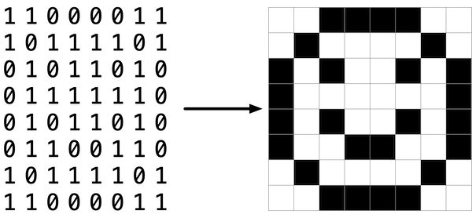

In this sense, then, is an image just a bitmap (i.e., a map of bits). For more colorful images, you simply need more bits per pixel. A file format (like BMP, JPEG, or PNG) that supports “24-bit color” uses 24 bits per pixel. (BMP actually supports 1-, 4-, 8-, 16-, 24-, and 32-bit color.)

A 24-bit BMP uses 8 bits to signify the amount of red in a pixel’s color, 8 bits to signify the amount of green in a pixel’s color, and 8 bits to signify the amount of blue in a pixel’s color. If you’ve ever heard of RGB color, well, there you have it: red, green, blue.

If the R, G, and B values of some pixel in a BMP are, say, 0xff, 0x00, and 0x00 in hexadecimal, that pixel is purely red, as 0xff (otherwise known as 255 in decimal) implies “a lot of red,” while 0x00 and 0x00 imply “no green” and “no blue,” respectively.

**A Bit(map) More Technical**

Recall that a file is just a sequence of bits, arranged in some fashion. A 24-bit BMP file, then, is essentially just a sequence of bits, (almost) every 24 of which happen to represent some pixel’s color. But a BMP file also contains some “metadata,” information like an image’s height and width. That metadata is stored at the beginning of the file in the form of two data structures generally referred to as **“headers”**, not to be confused with C’s header files. (Incidentally, these headers have evolved over time. This problem uses the latest version of Microsoft’s BMP format, 4.0, which debuted with Windows 95.)

The first of these headers, called **BITMAPFILEHEADER**, is 14 bytes long. (Recall that 1 byte equals 8 bits.) The second of these headers, called **BITMAPINFOHEADER**, is 40 bytes long. Immediately following these headers is the actual bitmap: an array of bytes, triples of which represent a pixel’s color. However, BMP stores these triples backwards (i.e., as BGR), with 8 bits for blue, followed by 8 bits for green, followed by 8 bits for red. (Some BMPs also store the entire bitmap backwards, with an image’s top row at the end of the BMP file. But we’ve stored this problem set’s BMPs as described herein, with each bitmap’s top row first and bottom row last.) In other words, were we to convert the 1-bit smiley above to a 24-bit smiley, substituting red for black, a 24-bit BMP would store this bitmap as follows, where 0000ff signifies red and ffffff signifies white; we’ve highlighted in red all instances of 0000ff.

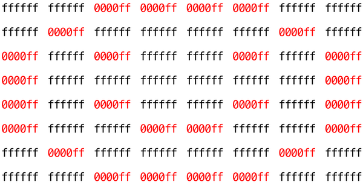

Because we’ve presented these bits from left to right, top to bottom, in 8 columns, you can actually see the red smiley if you take a step back.

To be clear, recall that a hexadecimal digit represents 4 bits. Accordingly, `ffffff` in hexadecimal actually signifies `111111111111111111111111` in binary.

Notice that you could represent a bitmap as a 2-dimensional array of pixels: where the image is an array of rows, each row is an array of pixels. Indeed, that’s how we’ve chosen to represent bitmap images in this problem.

**Image Filtering**

What does it even mean to filter an image? You can think of filtering an image as taking the pixels of some original image, and modifying each pixel in such a way that a particular effect is apparent in the resulting image.

**Grayscale**

One common filter is the “grayscale” filter, where we take an image and want to convert it to black-and-white. How does that work?

Recall that if the red, green, and blue values are all set to 0x00 (hexadecimal for 0), then the pixel is black. And if all values are set to 0xff (hexadecimal for 255), then the pixel is white. So long as the red, green, and blue values are all equal, the result will be varying shades of gray along the black-white spectrum, with higher values meaning lighter shades (closer to white) and lower values meaning darker shades (closer to black).

So to convert a pixel to grayscale, we just need to make sure the red, green, and blue values are all the same value. But how do we know what value to make them? Well, it’s probably reasonable to expect that if the original red, green, and blue values were all pretty high, then the new value should also be pretty high. And if the original values were all low, then the new value should also be low.

In fact, to ensure each pixel of the new image still has the same general brightness or darkness as the old image, we can take the average of the red, green, and blue values to determine what shade of grey to make the new pixel.

If you apply that to each pixel in the image, the result will be an image converted to grayscale.

**Reflection**

Some filters might also move pixels around. Reflecting an image, for example, is a filter where the resulting image is what you would get by placing the original image in front of a mirror. So any pixels on the left side of the image should end up on the right, and vice versa.

Note that all of the original pixels of the original image will still be present in the reflected image, it’s just that those pixels may have rearranged to be in a different place in the image.

**Blur**

There are a number of ways to create the effect of blurring or softening an image. For this problem, we’ll use the **“box blur”** which works by taking each pixel and, for each color value, giving it a new value by averaging the color values of neighboring pixels.

Consider the following grid of pixels, where we’ve numbered each pixel.

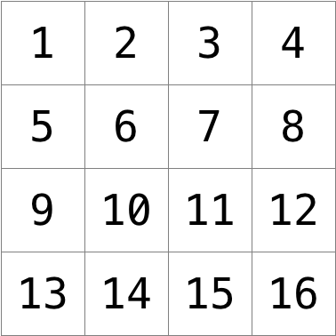

The new value of each pixel would be the average of the values of all of the pixels that are within 1 row and column of the original pixel (forming a 3x3 box). For example, each of the color values for pixel 6 would be obtained by averaging the original color values of pixels 1, 2, 3, 5, 6, 7, 9, 10, and 11 (note that pixel 6 itself is included in the average). Likewise, the color values for pixel 11 would be obtained by averaging the color values of pixels 6, 7, 8, 10, 11, 12, 14, 15 and 16.

For a pixel along the edge or corner, like pixel 15, we would still look for all pixels within 1 row and column: in this case, pixels 10, 11, 12, 14, 15, and 16.

**Edges**

In artificial intelligence algorithms for image processing, it is often useful to detect edges in an image: lines in the image that create a boundary between one object and another. One way to achieve this effect is by applying the **Sobel operator** to the image.

Like image blurring, edge detection also works by taking each pixel, and modifying it based on the `3x3` grid of pixels that surrounds that pixel. But instead of just taking the average of the nine pixels, the Sobel operator computes the new value of each pixel by taking a weighted sum of the values for the surrounding pixels. And since edges between objects could take place in both a vertical and a horizontal direction, you’ll actually compute two weighted sums: one for detecting edges in the x direction, and one for detecting edges in the y direction. In particular, you’ll use the following two “kernels”:

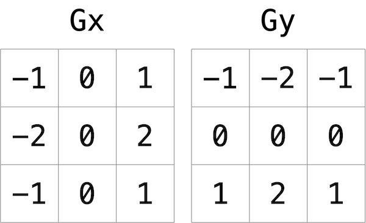

How to interpret these kernels? In short, for each of the three color values for each pixel, we’ll compute two values `Gx` and `Gy`. To compute `Gx` for the red channel value of a pixel, for instance, we’ll

- take the original red values for the nine pixels that form a `3x3` box around the pixel,
- multiply them each by the corresponding value in the `Gx` kernel, and
- take the sum of the resulting values.

Why these particular values for the kernel? In the `Gx` direction, for instance, we’re multiplying the pixels to the right of the target pixel by a positive number, and multiplying the pixels to the left of the target pixel by a negative number. When we take the sum, if the pixels on the right are a similar color to the pixels on the left, the result will be close to `0` (the numbers cancel out). But if the pixels on the right are very different from the pixels on the left, then the resulting value will be very positive or very negative, indicating a change in color that likely is the result of a boundary between objects. And a similar argument holds true for calculating edges in the `y` direction.

Using these kernels, we can generate a `Gx` and `Gy` value for each of the red, green, and blue channels for a pixel. But each channel can only take on one value, not two: so we need some way to combine `Gx` and `Gy` into a single value. The Sobel filter algorithm combines `Gx` and `Gy` into a final value by calculating the square root of $Gx^2 + Gy^2$. And since channel values can only take on integer values from 0 to 255, be sure the resulting value is rounded to the nearest integer and capped at 255!

And what about handling pixels at the edge, or in the corner of the image? There are many ways to handle pixels at the edge, but for the purposes of this problem, we’ll ask you to treat the image as if there was a 1 pixel solid black border around the edge of the image: therefore, trying to access a pixel past the edge of the image should be treated as a solid black pixel (values of `0` for each of red, green, and blue). This will effectively ignore those pixels from our calculations of `Gx` and `Gy`.

**Getting Started**

```python
cd Solutions
wget https://cdn.cs50.net/2022/fall/psets/4/filter-more.zip
unzip filter-more.zip
rm filter-more.zip
cd filter-more
ls
```

```
--2023-09-04 12:18:23--  https://cdn.cs50.net/2022/fall/psets/4/filter-more.zip
Resolving cdn.cs50.net (cdn.cs50.net)... 65.9.55.119, 65.9.55.105, 65.9.55.69, ...
Connecting to cdn.cs50.net (cdn.cs50.net)|65.9.55.119|:443... connected.
HTTP request sent, awaiting response... 200 OK
Length: 2159629 (2,1M) [application/zip]
Saving to: ‘filter-more.zip’

filter-more.zip     100%[===================>]   2,06M  4,21MB/s    in 0,5s

2023-09-04 12:18:24 (4,21 MB/s) - ‘filter-more.zip’ saved [2159629/2159629]

Archive:  filter-more.zip
   creating: filter-more/
   creating: filter-more/images/
  inflating: filter-more/images/courtyard.bmp
  inflating: filter-more/images/tower.bmp
  inflating: filter-more/images/yard.bmp
  inflating: filter-more/images/stadium.bmp
  inflating: filter-more/Makefile
  inflating: filter-more/bmp.h
  inflating: filter-more/filter.c
  inflating: filter-more/helpers.c
  inflating: filter-more/helpers.h
bmp.h  filter.c  helpers.c  helpers.h  images  Makefile
```

```python
pwd
```

```
/home/commi/Yandex.Disk/it_learning/02_CS/07_Harvard/Solutions/filter-more
```

You should see a few files: `bmp.h`, `filter.c`, `helpers.h`, `helpers.c`, and `Makefile`. You should also see a folder called `images` with four BMP files.

**Understanding**

Let’s now take a look at some of the files provided to you as distribution code to get an understanding for what’s inside of them.

```
bmp.h
```

Open up `bmp.h` (as by double-clicking on it in the file browser) and have a look.

You’ll see definitions of the headers we’ve mentioned (`BITMAPINFOHEADER` and `BITMAPFILEHEADER`). In addition, that file defines `BYTE`, `DWORD`, `LONG`, and `WORD`, data types normally found in the world of Windows programming. Notice how they’re just aliases for primitives with which you are (hopefully) already familiar. It appears that `BITMAPFILEHEADER` and `BITMAPINFOHEADER` make use of these types.

Perhaps most importantly for you, this file also defines a struct called `RGBTRIPLE` that, quite simply, “encapsulates” three bytes: one blue, one green, and one red (the order, recall, in which we expect to find RGB triples actually on disk).

Why are these structs useful? Well, recall that a file is just a sequence of bytes (or, ultimately, bits) on disk. But those bytes are generally ordered in such a way that the first few represent something, the next few represent something else, and so on. “File formats” exist because the world has standardized what bytes mean what. Now, we could just read a file from disk into RAM as one big array of bytes. And we could just remember that the byte at `array[i]` represents one thing, while the byte at `array[j]` represents another. But why not give some of those bytes names so that we can retrieve them from memory more easily? That’s precisely what the structs in `bmp.h` allow us to do. Rather than think of some file as one long sequence of bytes, we can instead think of it as a sequence of structs.

```
filter.c
```

Now, let’s open up `filter.c`. This file has been written already for you, but there are a couple important points worth noting here.

First, notice the definition of filters on line `10`. That string tells the program what the allowable command-line arguments to the program are: `b`, `e`, `g`, and `r`. Each of them specifies a different filter that we might apply to our images: blur, edge detection, grayscale, and reflection.

The next several lines open up an image file, make sure it’s indeed a BMP file, and read all of the pixel information into a 2D array called `image`.

Scroll down to the `switch` statement that begins on line `101`. Notice that, depending on what filter we’ve chosen, a different function is called: if the user chooses filter `b`, the program calls the `blur` function; if `e`, then `edges` is called; if `g`, then `grayscale` is called; and if `r`, then `reflect` is called. Notice, too, that each of these functions take as arguments the height of the image, the width of the image, and the 2D array of pixels.

These are the functions you’ll (soon!) implement. As you might imagine, the goal is for each of these functions to edit the 2D array of pixels in such a way that the desired filter is applied to the image.

The remaining lines of the program take the resulting image and write them out to a new image file.

```
helpers.h
```

Next, take a look at `helpers.h`. This file is quite short, and just provides the function prototypes for the functions you saw earlier.

Here, take note of the fact that each function takes a 2D array called `image` as an argument, where `image` is an array of height many rows, and each row is itself another array of width many `RGBTRIPLE`s. So if image represents the whole picture, then `image[0]` represents the first row, and `image[0][0]` represents the pixel in the upper-left corner of the image.

```
helpers.c
```

Now, open up `helpers.c`. Here’s where the implementation of the functions declared in `helpers.h` belong. But note that, right now, the implementations are missing! This part is up to you.

```
Makefile
```

Finally, let’s look at `Makefile`. This file specifies what should happen when we run a terminal command like `make` filter. Whereas programs you may have written before were confined to just one file, filter seems to use multiple files: `filter.c` and `helpers.c`. So we’ll need to tell `make` how to compile this file.

Try compiling filter for yourself by going to your terminal and running

```
$ make filter
```

Then, you can run the program by running:

```
$ ./filter -g images/yard.bmp out.bmp
```

which takes the image at `images/yard.bmp`, and generates a new image called `out.bmp` after running the pixels through the `grayscale` function. `grayscale` doesn’t do anything just yet, though, so the output image should look the same as the original yard.

**Specification**

Implement the functions in `helpers.c` such that a user can apply `grayscale`, `reflection`, `blur`, or `edge` detection filters to their images.

- The function `grayscale` should take an image and turn it into a black-and-white version of the same image.
- The `reflect` function should take an image and reflect it horizontally.
- The `blur` function should take an image and turn it into a box-blurred version of the same image.
- The `edges` function should take an image and highlight the edges between objects, according to the Sobel operator.

You should not modify any of the function signatures, nor should you modify any other files other than `helpers.c`.

**Usage**

Your program should behave per the examples below. `INFILE.bmp` is the name of the input image and `OUTFILE.bmp` is the name of the resulting image after a filter has been applied.

```
$ ./filter -g INFILE.bmp OUTFILE.bmp
$ ./filter -r INFILE.bmp OUTFILE.bmp
$ ./filter -b INFILE.bmp OUTFILE.bmp
$ ./filter -e INFILE.bmp OUTFILE.bmp
```

**Hints**

The values of a pixel’s `rgbtRed`, `rgbtGreen`, and `rgbtBlue` components are all integers, so be sure to round any floating-point numbers to the nearest integer when assigning them to a pixel value!

**Solution**

```
#include <getopt.h>
#include <stdio.h>
#include <stdlib.h>

#include "helpers.h"

int main(int argc, char *argv[])
{
    // Define allowable filters
    char *filters = "begr";

    // Get filter flag and check validity
    char filter = getopt(argc, argv, filters);
    if (filter == '?')
    {
        printf("Invalid filter.\n");
        return 1;
    }

    // Ensure only one filter
    if (getopt(argc, argv, filters) != -1)
    {
        printf("Only one filter allowed.\n");
        return 2;
    }

    // Ensure proper usage
    if (argc != optind + 2)
    {
        printf("Usage: ./filter [flag] infile outfile\n");
        return 3;
    }

    // Remember filenames
    char *infile = argv[optind];
    char *outfile = argv[optind + 1];

    // Open input file
    FILE *inptr = fopen(infile, "r");
    if (inptr == NULL)
    {
        printf("Could not open %s.\n", infile);
        return 4;
    }

    // Open output file
    FILE *outptr = fopen(outfile, "w");
    if (outptr == NULL)
    {
        fclose(inptr);
        printf("Could not create %s.\n", outfile);
        return 5;
    }

    // Read infile's BITMAPFILEHEADER
    BITMAPFILEHEADER bf;
    fread(&bf, sizeof(BITMAPFILEHEADER), 1, inptr);

    // Read infile's BITMAPINFOHEADER
    BITMAPINFOHEADER bi;
    fread(&bi, sizeof(BITMAPINFOHEADER), 1, inptr);

    // Ensure infile is (likely) a 24-bit uncompressed BMP 4.0
    if (bf.bfType != 0x4d42 || bf.bfOffBits != 54 || bi.biSize != 40 ||
        bi.biBitCount != 24 || bi.biCompression != 0)
    {
        fclose(outptr);
        fclose(inptr);
        printf("Unsupported file format.\n");
        return 6;
    }

    // Get image's dimensions
    int height = abs(bi.biHeight);
    int width = bi.biWidth;

    // Allocate memory for image
    RGBTRIPLE(*image)[width] = calloc(height, width * sizeof(RGBTRIPLE));
    if (image == NULL)
    {
        printf("Not enough memory to store image.\n");
        fclose(outptr);
        fclose(inptr);
        return 7;
    }

    // Determine padding for scanlines
    int padding = (4 - (width * sizeof(RGBTRIPLE)) % 4) % 4;

    // Iterate over infile's scanlines
    for (int i = 0; i < height; i++)
    {
        // Read row into pixel array
        fread(image[i], sizeof(RGBTRIPLE), width, inptr);

        // Skip over padding
        fseek(inptr, padding, SEEK_CUR);
    }

    // Filter image
    switch (filter)
    {
        // Blur
        case 'b':
            blur(height, width, image);
            break;

        // Edges
        case 'e':
            edges(height, width, image);
            break;

        // Grayscale
        case 'g':
            grayscale(height, width, image);
            break;

        // Reflect
        case 'r':
            reflect(height, width, image);
            break;
    }

    // Write outfile's BITMAPFILEHEADER
    fwrite(&bf, sizeof(BITMAPFILEHEADER), 1, outptr);

    // Write outfile's BITMAPINFOHEADER
    fwrite(&bi, sizeof(BITMAPINFOHEADER), 1, outptr);

    // Write new pixels to outfile
    for (int i = 0; i < height; i++)
    {
        // Write row to outfile
        fwrite(image[i], sizeof(RGBTRIPLE), width, outptr);

        // Write padding at end of row
        for (int k = 0; k < padding; k++)
        {
            fputc(0x00, outptr);
        }
    }

    // Free memory for image
    free(image);

    // Close files
    fclose(inptr);
    fclose(outptr);
    return 0;
}
```

## W4 [Reverse](https://cs50.harvard.edu/x/2023/psets/4/reverse/)

Implement a program that reverses a WAV file, per the below.

```
./reverse input.wav output.wav
```

**Background**

In Electric Light Orchestra’s [“Fire on High”](https://www.youtube.com/watch?v=J9iyqMwYtG4), there’s something a little off about the first minute or so of the music. If you take a listen, it sounds almost like the audio is playing backwards. As it turns out, if you play the beginning section of the song in reverse, you’ll hear the following:

*“The music is reversible. Time is not. Turn back, turn back!”*

Creepy, right? This is a technique called “backmasking,” or hiding messages in music that can only be heard when the song is played backwards. Many artists have used (or been suspected of using) this technique in their songs. To be able to do our own investigation into backmasking, we’ve asked you to write a program that can reverse WAV files for us!

Unlike MP3 audio files, WAV files are not compressed. This makes the files much easier to edit and manipulate, which is useful for the task at hand. To learn a little more about WAV files, we need to take a closer look at the WAV file format.

**Getting Started**

```python
pwd
```

```
/home/vadim/Yandex.Disk/it_learning/02_CS/07_Harvard
```

```python
cd Solutions
wget https://cdn.cs50.net/2022/fall/psets/4/reverse.zip
unzip reverse.zip
rm reverse.zip
cd reverse
ls
```

```
--2023-09-10 17:40:10--  https://cdn.cs50.net/2022/fall/psets/4/reverse.zip
Resolving cdn.cs50.net (cdn.cs50.net)... 65.9.55.9, 65.9.55.69, 65.9.55.105, ...
Connecting to cdn.cs50.net (cdn.cs50.net)|65.9.55.9|:443... connected.
HTTP request sent, awaiting response... 200 OK
Length: 314148 (307K) [application/zip]
Saving to: ‘reverse.zip’

reverse.zip         100%[===================>] 306.79K  1.75MB/s    in 0.2s

2023-09-10 17:40:11 (1.75 MB/s) - ‘reverse.zip’ saved [314148/314148]

Archive:  reverse.zip
   creating: reverse/
  inflating: reverse/wav.h
  inflating: reverse/input.wav
  inflating: reverse/reverse.c
input.wav  reverse.c  wav.h
```

and see a file named `reverse.c`. Executing code `reverse.c` should open the file where you will type your code for this problem set.

**The WAV File Format**

Notice that, in the visual below, a WAV file is broken into three chunks. Each chunk has a few blocks of data inside of it.

The first chunk contains information about the file’s type. In particular, see how the “File Format” block in the first chunk spells out ‘W’ ‘A’ ‘V’ ‘E’ in bytes 8–11, to indicate the file is a WAV file.

The second chunk contains information about the upcoming audio data, including how many “channels” of audio are present and how many bits are in each audio “sample”. Audio files have 1 channel when they’re “monophonic”: if you were to wear headphones, you’d hear the same audio in your left and right ear. Audio files have 2 channels when they’re “stereophonic”: wearing headphones, you’d hear slightly different audio in your left and right ear, creating a sense of spaciousness. Samples are the individual chunks of bits which make up the audio you hear. With more bits per sample, an audio file can have greater clarity (at the cost of more memory used!).

Finally, the third chunk contains the audio data itself—those samples we mentioned just above.

Everything before the audio data is considered part of the WAV “header”. Recall that a file header is simply some metadata about the file. In this case, the header is 44 bytes long.

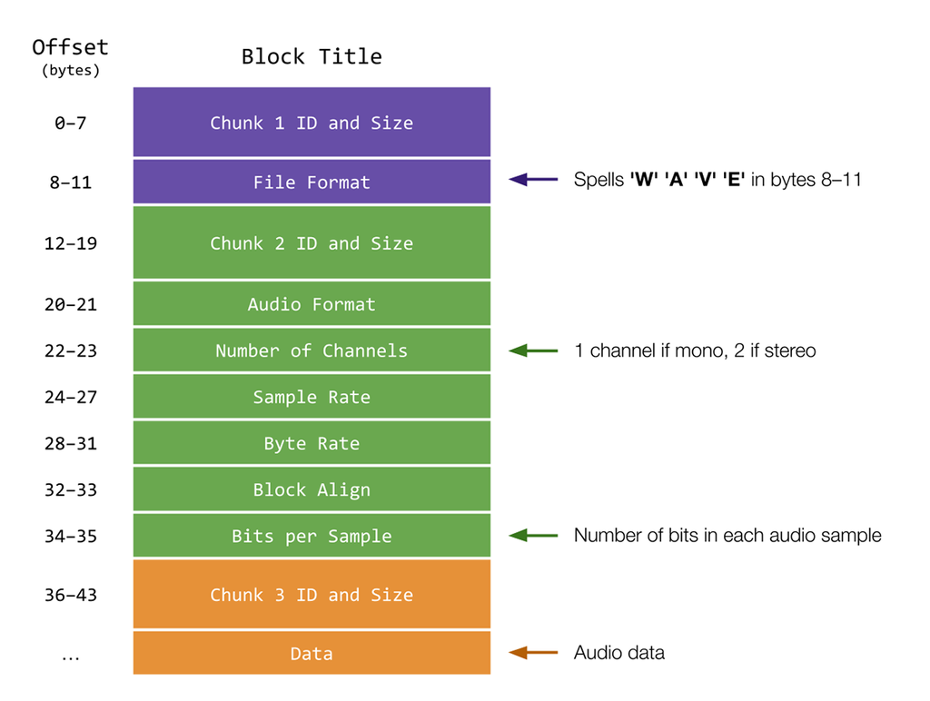

A more technical explanation of WAV headers can be found [here](http://soundfile.sapp.org/doc/WaveFormat/), which is the resource by which this visual was inspired. Notice that we’ve included a file, `wav.h`, which implements all these details for you in a struct called `WAVHEADER`.

**Specification**

Let’s write a program called `reverse` that enables us to reverse a WAV file given by the user and create a new WAV file that contains the resulting reversed audio. For simplicity’s sake, we’ll limit the files we deal with to the WAV format. At the time the user executes the program, they should provide, using two command-line arguments, the name of the input file to be read and reversed, and the name of the output file they would like to save the resulting audio in. A successfully executed program should not output any text, and should create a WAV file with the user-specified name that plays the audio of the input WAV file in reverse. For example:

```
$ ./reverse input.wav output.wav
```

In `reverse.c`, you’ll notice that a few helpful libraries have been included, as well as a header file, `wav.h`. You’ll likely find these to be useful when implementing your program. We’ve left eight TODOs and two helper functions for you to fill in, and we recommend you tackle them in order from 1 to 8.

In the first TODO, you should ensure the program accepts two command-line arguments: the name of the input WAV file and the name of the output WAV file. If the program does not meet these conditions, you should print an appropriate error message and return `1`, ending the program.

**Hint**

In the second TODO, you should open your input file. We’ll need to open the input file in “read-only” mode, since we’ll only read data from the input file. It may be wise to check that the file has been opened successfully. Otherwise, you should print an appropriate error message and return `1`, exiting the program. We should hold off on opening the output file, though, lest we create a new WAV file before knowing the input file is valid!

**Hint**

In the third TODO, you should read the header from the input file. Recall that, in `wav.h`, we’ve already implemented a `struct` that can store a WAV file’s header. Since we’ve written `#include "wav.h"` at the top of `reverse.c`, you, too, can use the `WAVHEADER` struct.

In the fourth TODO, you should complete the `check_format` function. `check_format` takes a single argument, a `WAVHEADER` called `header`, representing a struct containing the input file’s header. If header indicates the file is indeed a WAV file, the `check_format` function should return `true`. If not, `check_format` should return `false`. To check if a file is of the WAV format, we can compare the elements from the input file header to those we would expect from a WAV file. It suffices to show the `“WAVE”` marker characters are found in the format member of the `WAVHEADER` struct (see *Background* for more detail on WAV file headers).

In the fifth TODO, you can now safely open the output file for writing. It would still be wise to check that the file has been opened successfully.

**Hints**

This may be a good place to stop and test that your program behaves as expected. If implemented properly, your program should open a new file when executed with the proper command-line arguments.

If at any point you find it necessary to delete a file, execute the following command in your current working directory.

```
$ rm file_name.wav
```

If you’d rather not be prompted to confirm each deletion, execute the command below instead.

```
$ rm -f file_name.wav
```

Just be careful with that `-f` switch, as it “forces” deletion without prompting you.

Next, now that the file type has been verified, the sixth TODO tells us to write the header to the output file. The reversed WAV file will still have the same underlying file structure as the input file (same size, number of channels, bits per sample, etc.), so it suffices to copy the header we read in from the input file in the third TODO to the output file.

In the seventh TODO, you should implement the `get_block_size` function. `get_block_size`, like `check_format`, takes a single argument: this is a `WAVHEADER` called `header`, representing the struct containing the input file’s header. `get_block_size` should return an integer representing the block size of the given WAV file, in bytes. We can think of a block as a unit of auditory data. For audio, we calculate the size of each block with the following calculation:

- number of channels multiplied by bytes per sample.

Luckily, the header contains all the information we need to compute these values. Be sure to reference the *Background* section for a more in-depth explanation as to what these values mean and how they are stored. See too `wav.h`, to determine which members of `WAVHEADER` might be useful.

**Hints**

The eighth and final TODO is where the actual reversing of the audio takes place. To do this, we need to read in each block of auditory data starting from the very end of the input file and moving backwards, simultaneously writing each block to the output file so they are written in reverse order. First, we should declare an array to store each block we read in. Then, it’s up to you to iterate through the input file audio data. You’ll want to be sure you read through all of the audio, but don’t erroneously copy any of the data from the header! Additionally, for testing purposes, we would like to maintain the order of the channels for each audio block. For example, in a WAV file with two channels (stereophonic sound), we want to make sure that the first channel of the last audio block in the input becomes the first channel of the first audio block in the output.

**Hints**

Finally, be sure to close any files you’ve opened!

**Usage**

Here are a few examples of how the program should work. For example, if the user omits one of the command-line arguments:

```
$ ./reverse input.wav
Usage: ./reverse input.wav output.wav
```

Or if the user omits both of the command-line arugments:

```
$ ./reverse
Usage: ./reverse input.wav output.wav
```

Here’s how the program should work if the user provides an input file that is not an actual WAV file:

```
$ ./reverse image.jpg output.wav
Input is not a WAV file.
```

You may assume the user enters a valid output filename, such as `output.wav`.

A successfully executed program should not output any text, and should create a WAV file with the user-specified name that plays the audio of the input WAV file in reverse. For example:

```
$ ./reverse input.wav output.wav
```

```python
# bash
cd Solutions/reverse
ls
```

```
input.wav  reverse.c  wav.h
```

```python
#python

from scipy.io import wavfile
from IPython.display import Audio

input_file = './Solutions/reverse/input.wav'
inp_samplerate, inp_data = wavfile.read(input_file)

inp_samplerate
```

```
44100
```

```python
inp_data.shape
```

```
(88200, 2)
```

```python
inp_data
```

```
array([[    0,     0],
       [    0,     0],
       [    0,     0],
       ...,
       [-2041, -1524],
       [-1923, -1462],
       [-1843, -1420]], dtype=int16)
```

```python
Audio(inp_data.T, rate=inp_samplerate)
```

[interactive chart not shown]

```python
output_file = './Solutions/reverse/output.wav'
output_samplerate, output_data = wavfile.read(output_file)
Audio(output_data.T, rate=output_samplerate)
```

[interactive chart not shown]

**Solution**

```
#include <stdint.h>
#include <stdio.h>
#include <stdlib.h>

#include "wav.h"

int check_format(WAVHEADER header);
int get_block_size(WAVHEADER header);

int main(int argc, char *argv[])
{
    // Ensure proper usage
    // TODO #1
	if (argc != 3)
	{
		printf("Usage: ./reverse input.wav output.wav\n");
		return 1;
	}

    // Open input file for reading
    // TODO #2
	FILE *input = fopen(argv[1], "r");
	if (input == NULL)
	{
		printf("Could not open a file\n");
		return 2;
	}

    // Read header
    // TODO #3
	WAVHEADER buffer;
	fread(&buffer, sizeof(WAVHEADER), 1, input);

    // Use check_format to ensure WAV format
    // TODO #4
	check_format(buffer);

    // Open output file for writing
    // TODO #5
	FILE *output = fopen(argv[2], "w");
	if (output == NULL)
	{
		printf("Could not open a file\n");
		return 5;
	}

    // Write header to file
    // TODO #6
	fwrite(&buffer, sizeof(WAVHEADER), 1, output);

    // Use get_block_size to calculate size of block
    // TODO #7;
	int block_size = get_block_size(buffer);

    // Write reversed audio to file
    // TODO #8

	// find the size without header to count blocks
	fseek(input, 0, SEEK_END);
	int inp_file_size = ftell(input) - sizeof(WAVHEADER);



	int blocks_qty = inp_file_size / block_size;

	// buffer for each block
	int one_block;
	// starting carret position
	int seek_position = block_size;
	// main loop for all blocks
	while (blocks_qty > 0)
	{
		// set carret to the end and count back blocks
		fseek(input, -seek_position, SEEK_END);
		// read and write each block backwards
		fread(&one_block, block_size, 1, input);
		fwrite(&one_block, block_size, 1, output);
		// update carret position
		seek_position += block_size;
		// one block away
		blocks_qty--;
	}

	fclose(input);
	fclose(output);

}

int check_format(WAVHEADER header)
{
    // TODO #4
	char *check = "WAVE";
	for (int i = 0; i < 4; i++)
	{
		int letter = check[i];
		if (header.format[i] != letter)
		{
			printf("This is not a WAV file.")
			return 4;
		}
	}
    return 0;
}

int get_block_size(WAVHEADER header)
{
    // TODO #7
	int block_size;
	block_size = header.numChannels * header.bitsPerSample / 8;
    return block_size;
}
```

## W4 [Recover](https://cs50.harvard.edu/x/2023/psets/4/recover/)

Implement a program that recovers JPEGs from a forensic image, per the below.

```
$ ./recover card.raw
```

**Background**

In anticipation of this problem, we spent the past several days taking photos around campus, all of which were saved on a digital camera as JPEGs on a memory card. Unfortunately, we somehow deleted them all! Thankfully, in the computer world, “deleted” tends not to mean “deleted” so much as “forgotten.” Even though the camera insists that the card is now blank, we’re pretty sure that’s not quite true. Indeed, we’re hoping (er, expecting!) you can write a program that recovers the photos for us!

Even though JPEGs are more complicated than BMPs, JPEGs have “signatures,” patterns of bytes that can distinguish them from other file formats. Specifically, the first three bytes of JPEGs are

```
0xff 0xd8 0xff
```

from first byte to third byte, left to right. The fourth byte, meanwhile, is either `0xe0`, `0xe1`, `0xe2`, `0xe3`, `0xe4`, `0xe5`, `0xe6`, `0xe7`, `0xe8`, `0xe9`, `0xea`, `0xeb`, `0xec`, `0xed`, `0xee`, or `0xef`. Put another way, the fourth byte’s first four bits are `1110`.

Odds are, if you find this pattern of four bytes on media known to store photos (e.g., my memory card), they demarcate the start of a JPEG. To be fair, you might encounter these patterns on some disk purely by chance, so data recovery isn’t an exact science.

Fortunately, digital cameras tend to store photographs contiguously on memory cards, whereby each photo is stored immediately after the previously taken photo. Accordingly, the start of a JPEG usually demarks the end of another. However, digital cameras often initialize cards with a FAT file system whose “block size” is 512 bytes (B). The implication is that these cameras only write to those cards in units of 512 B. A photo that’s 1 MB (i.e., `1,048,576` B) thus takes up $1048576 ÷ 512 = 2048$ “blocks” on a memory card.

```python
# python
one_byte = 1
one_kbyte = 1024 * one_byte
one_mb = 1024 * 1024
print(f"One megabyte consists of\t{one_mb} bytes")

block_size = 512 * one_byte
print(f"One megabyte is divided into\t{int(one_mb/block_size)} blocks")
```

```
One megabyte consists of	1048576 bytes
One megabyte is divided into	2048 blocks
```

But so does a photo that’s, say, one byte smaller (i.e., `1,048,575` B)! The wasted space on disk is called **slack space**. Forensic investigators often look at slack space for remnants of suspicious data.

The implication of all these details is that you, the investigator, can probably write a program that iterates over a copy of my memory card, looking for JPEGs’ signatures. Each time you find a signature, you can open a new file for writing and start filling that file with bytes from my memory card, closing that file only once you encounter another signature. Moreover, rather than read my memory card’s bytes one at a time, you can read 512 of them at a time into a buffer for efficiency’s sake. Thanks to FAT, you can trust that JPEGs’ signatures will be “block-aligned.” That is, you need only look for those signatures in a block’s first four bytes.

Realize, of course, that JPEGs can span contiguous blocks. Otherwise, no JPEG could be larger than 512 B. But the last byte of a JPEG might not fall at the very end of a block. Recall the possibility of slack space. But not to worry. Because this memory card was brand-new when I started snapping photos, odds are it’d been “zeroed” (i.e., filled with 0s) by the manufacturer, in which case any slack space will be filled with 0s. It’s okay if those trailing 0s end up in the JPEGs you recover; they should still be viewable.

Now, I only have one memory card, but there are a lot of you! And so I’ve gone ahead and created a “forensic image” of the card, storing its contents, byte after byte, in a file called `card.raw`. So that you don’t waste time iterating over millions of 0s unnecessarily, I’ve only imaged the first few megabytes of the memory card. But you should ultimately find that the image contains `50` JPEGs.

```python
# bash
cd ./Solutions
wget https://cdn.cs50.net/2022/fall/psets/4/recover.zip
unzip recover.zip
rm recover.zip
cd recover
ls
```

```
--2023-09-23 20:36:36--  https://cdn.cs50.net/2022/fall/psets/4/recover.zip
Resolving cdn.cs50.net (cdn.cs50.net)... 65.9.55.119, 65.9.55.9, 65.9.55.69, ...
Connecting to cdn.cs50.net (cdn.cs50.net)|65.9.55.119|:443... connected.
HTTP request sent, awaiting response... 200 OK
Length: 485306 (474K) [application/zip]
Saving to: 'recover.zip'

recover.zip         100%[===================>] 473.93K  1.24MB/s    in 0.4s

2023-09-23 20:36:37 (1.24 MB/s) - 'recover.zip' saved [485306/485306]

Archive:  recover.zip
   creating: recover/
  inflating: recover/card.raw
  inflating: recover/recover.c
card.raw  recover.c
```

You should see two files: `recover.c` and `card.raw`.

**Specification**

Implement a program called `recover` that recovers JPEGs from a forensic image.

- Implement your program in a file called `recover.c` in a directory called recover.
- Your program should accept exactly one command-line argument, the `name` of a forensic image from which to recover JPEGs.
- If your program is not executed with exactly one command-line argument, it should remind the user of correct usage, and `main` should return `1`.
- If the forensic image cannot be opened for reading, your program should inform the user as much, and main should return `1`.
- The files you generate should each be named `###.jpg`, where `###` is a three-digit decimal number, starting with `000` for the first image and counting up.
- Your program, if it uses `malloc`, must not leak any memory.

**Usage**

Your program should behave per the examples below.

```
$ ./recover
Usage: ./recover IMAGE
```

where `IMAGE` is the name of the forensic image. For example:

```
$ ./recover card.raw
```

**Hints**

Keep in mind that you can open `card.raw` programmatically with `fopen`, as with the below, provided `argv[1]` exists.

```
FILE *file = fopen(argv[1], "r");
```

When executed, your program should recover every one of the JPEGs from `card.raw`, storing each as a separate file in your current working directory. Your program should number the files it outputs by naming each `###.jpg`, where `###` is three-digit decimal number from `000` on up. Befriend `sprintf` and note that `sprintf` stores a formatted string at a location in memory. Given the prescribed `###.jpg` format for a JPEG’s filename, how many bytes should you allocate for that string? (Don’t forget the NUL character!)

You need not try to recover the JPEGs’ original names. To check whether the JPEGs your program spit out are correct, simply double-click and take a look! If each photo appears intact, your operation was likely a success!

Odds are, though, the JPEGs that the first draft of your code spits out won’t be correct. (If you open them up and don’t see anything, they’re probably not correct!) Execute the command below to delete all JPEGs in your current working directory.

```
$ rm *.jpg
```

If you’d rather not be prompted to confirm each deletion, execute the command below instead.

```
$ rm -f *.jpg
```

Just be careful with that `-f` switch, as it “forces” deletion without prompting you.

If you’d like to create a new type to store a byte of data, you can do so via the below, which defines a new type called `BYTE` to be a `uint8_t` (a type defined in `stdint.h`, representing an 8-bit unsigned integer).

```
typedef uint8_t BYTE;
```

Keep in mind, too, that you can read data from a file using `fread`, which will read data from a file into a location in memory. Per its manual page, `fread` returns the number of bytes that it has read, in which case it should either return `512` or `0`, given that `card.raw` contains some number of 512-byte blocks. In order to read every block from `card.raw`, after opening it with `fopen`, it should suffice to use a loop like:

```
while (fread(buffer, 1, BLOCK_SIZE, raw_file) == BLOCK_SIZE)
{


}
```

That way, as soon as `fread` returns `0` (which is effectively false), your loop will end.

**Solution**

```
#include <stdio.h>
#include <stdlib.h>
#include <stdint.h>

int main(int argc, char *argv[])
{
	typedef uint8_t BYTE;

	if (argc != 2)
	{
		printf("Usage: ./recover IMAGE\n");
		return 1;
	}

	FILE *input = fopen(argv[1], "r");
	if (input == NULL)
	{
		printf("File cannot be opened. Try another file\n");
		return 2;
	}

	const int BLOCK_SIZE = 512;
	BYTE *buffer = malloc(BLOCK_SIZE);
	char *pic_name = malloc(9);
	int number = 0;
	FILE *image;


	BYTE check_array[] = {0xff, 0xd8, 0xff, 0xe0};
	while ( fread(buffer, 1, BLOCK_SIZE, input) )
	{
		// check for start of jpeg
		int check = 1;
		for (int i = 0, n = 3; i < n; i++)
		{
			if	(buffer[i] != check_array[i] || (buffer[n] & 0xf0) != 0xe0)
			{
				check = 0;
				break;
			}
		}

		if (check)
		{
			if (number != 0)
			{
				fclose(image);
			}

			sprintf(pic_name, "%03i.jpeg", number);
			image = fopen(pic_name, "w");
			fwrite(buffer, 1, BLOCK_SIZE, image);
			number++;
		}

		else if (number != 0)
		{
			fwrite(buffer, 1, BLOCK_SIZE, image);
		}
	}

	fclose(image);
    free(buffer);
    free(pic_name);
}
```

## W4 [License](https://cs50.harvard.edu/x/2023/problems/4/license/)

**Learning Goals**

- Practice working with files and file pointers
- More work with strings and arrays
- Debugging with debug50
- Use `valgrind` to check for memory leaks

**Background**

Suppose you work for a company that develops AI-enhanced license plate recognition technology. As you develop your technology, you may want to use actual license plate numbers as test data. You have a text file with some plate numbers you want to analyze, so you first try reading from that text file and printing out the license plates, to test your file-reading logic. But when you run your program, only the last number prints 8 times! What went wrong?

```python
pwd
```

```
/home/commi/Yandex.Disk/it_learning/02_CS/07_Harvard
```

```python
cd Solutions
wget https://cdn.cs50.net/2022/fall/labs/4/license.zip
unzip license.zip
rm license.zip
cd license
ls
```

```
--2023-10-01 14:57:21--  https://cdn.cs50.net/2022/fall/labs/4/license.zip
Resolving cdn.cs50.net (cdn.cs50.net)... 65.9.55.105, 65.9.55.69, 65.9.55.9, ...
Connecting to cdn.cs50.net (cdn.cs50.net)|65.9.55.105|:443... connected.
HTTP request sent, awaiting response... 200 OK
Length: 887 [application/zip]
Saving to: ‘license.zip’

license.zip         100%[===================>]     887  --.-KB/s    in 0s

2023-10-01 14:57:22 (12,9 MB/s) - ‘license.zip’ saved [887/887]

Archive:  license.zip
   creating: license/
  inflating: license/plates.txt
  inflating: license/license.c
license.c  plates.txt
```

**Implementation Details**

If you open the `plates.txt` file, you’ll notice that there are actually 8 different license plate numbers. There are a few errors in the distribution code that are causing this to happen. Let’s start by walking through the code.

We first check for command-line arguments, since `argv[1]` should be the text file that contains the license plates. We then create a character array of length `7`, since the plate numbers are `6` chars long and we need to save space for the `NUL` terminator. Now we create an array of `char *’s` (character pointers, otherwise known as strings!) to store the `8` plate numbers. We create a file pointer to our external text file, create a variable to hold the index of each array element, and begin reading the file and saving the plate numbers to the array. Finally, to test that we did this correctly, we print out the values in the array.

However, when we compile and execute this code, something is clearly wrong. You’ll need to make the appropriate corrections!

**Debugging**

Take a close look at what values are actually being added to the array. You can experiment with `debug50` to find the error in the distribution code.

**Hints**

- What exactly does the variable `buffer` hold that’s being assigned to each element of the `plates` array?
- Note that the `plates` array as an array of `char *’s` or string pointers.
- So when we assign the char array `buffer` to a `char *`, what actually happens?

Is there a better way to copy license plate numbers to the `license` array?

**More hints**

- Would `strcpy` come in useful here?
- If you copy data to a pointer, where will that data go?
- Is `malloc` required here?

**Checking for Memory Leaks**

Once your program seems to be working properly, run `valgrind` to make sure there are no memory leaks.

```
valgrind ./license plates.txt
```

You may end up with something like this:

```
==24478== HEAP SUMMARY:
==24478==     in use at exit: 528 bytes in 9 blocks
==24478==   total heap usage: 10 allocs, 1 frees, 4,624 bytes allocated
==24478==
==24478== 56 bytes in 8 blocks are definitely lost in loss record 1 of 2
==24478==    at 0x4848899: malloc (in /usr/libexec/valgrind/vgpreload_memcheck-amd64-linux.so)
==24478==    by 0x109207: main (license.c:30)
==24478==
==24478== 472 bytes in 1 blocks are still reachable in loss record 2 of 2
==24478==    at 0x4848899: malloc (in /usr/libexec/valgrind/vgpreload_memcheck-amd64-linux.so)
==24478==    by 0x4A086CD: __fopen_internal (iofopen.c:65)
==24478==    by 0x4A086CD: fopen@@GLIBC_2.2.5 (iofopen.c:86)
==24478==    by 0x1091CD: main (license.c:20)
==24478==
==24478== LEAK SUMMARY:
==24478==    definitely lost: 56 bytes in 8 blocks
==24478==    indirectly lost: 0 bytes in 0 blocks
==24478==      possibly lost: 0 bytes in 0 blocks
==24478==    still reachable: 472 bytes in 1 blocks
==24478==         suppressed: 0 bytes in 0 blocks
==24478==
==24478== For lists of detected and suppressed errors, rerun with: -s
==24478== ERROR SUMMARY: 1 errors from 1 contexts (suppressed: 0 from 0)
```

There seem to be two kinds of memory errors here that need to be corrected!

**Hint**

Your line numbers may be different, but note here that there seems to be a memory problem in `main` on line 30 (something to do with `malloc`?), and line 20 (a problem related to `fopen`?). What might the distribution code be missing?

**Solution**

`clang -o licence license.c -lcs50`

```
#include <stdio.h>
#include <stdlib.h>
#include <string.h>

int main(int argc, char *argv[])
{
    // Check for command line args
    if (argc != 2)
    {
        printf("Usage: ./read infile\n");
        return 1;
    }

    // Create buffer to read into
    char *buffer = malloc(7);

    // Create array to store plate numbers
    char *plates[8];  // 8 arrays of 7 chars

    FILE *infile = fopen(argv[1], "r");

    int idx = 0;

    while (fread(buffer, 1, 7, infile) == 7)
    {
        // Replace '\n' with '\0'
        buffer[6] = '\0';

		// check what the buffer contains
//		printf("%s\n", buffer);

		// Save plate number in array
		plates[idx] = malloc(7);
		strcpy(plates[idx], buffer);
        idx++;

		// check the plates array at each iteration
//		for (int j = 0; j < 8; j++)
//		{
//			printf("%s ", plates[j]);
//		}
//		printf("\n");
    }

//	printf("\n");

    for (int i = 0; i < 8; i++)
    {
        printf("%s\n", plates[i]);
    }

	free(buffer);
	for (int i = 0; i < 8; i ++)
	{
		free(plates[i]);
	}
	fclose(infile);
}
```

## W4 [Bottom Up](https://cs50.harvard.edu/x/2023/problems/4/bottomup/)

**Learning Goals**

- Practice working with images
- Learn about metadata
- Learn more about how structs can be useful

**Background**

Imagine an image you need to present to your boss for a major presentation somehow got corrupted! Upon investigating, you find that the image is mostly intact. Except, when you view the image, it now appears to be upside down!

Recall that a digital image file is just a sequence of bits, arranged in some fashion. A 24-bit BMP file, then, is essentially just a sequence of bits, (almost) every 24 of which happen to represent some pixel’s color. But a BMP file also contains some **metadata**, information like an image’s height and width. That metadata is stored at the beginning of the file in the form of two data structures generally referred to as **headers**, not to be confused with C’s header files. The first of these headers, called `BITMAPFILEHEADER`, is `14` bytes long. (Recall that 1 byte equals 8 bits.) The second of these headers, called `BITMAPINFOHEADER`, is `40` bytes long. Immediately following these headers is the actual bitmap: an array of bytes, triples of which represent a pixel’s color.

Your job is to edit the metadata programmatically so that the bitmap’s top row is first and bottom row last. Best to avoid editing the pixels directly, lest you further corrupt the file!

**Hints**

- Be sure to look carefully at the members of the `BITMAPINFOHEADER` struct in `bmp.h`.
- If you read the documentation) for each of these members, which should you modify? How so?

```python
cd Solutions
wget https://cdn.cs50.net/2022/fall/labs/4/bottomup.zip
unzip bottomup.zip
rm -f bottomup.zip
ls bottomup
```

```
--2023-10-07 19:18:03--  https://cdn.cs50.net/2022/fall/labs/4/bottomup.zip
Resolving cdn.cs50.net (cdn.cs50.net)... 65.9.55.69, 65.9.55.105, 65.9.55.119, ...
Connecting to cdn.cs50.net (cdn.cs50.net)|65.9.55.69|:443... connected.
HTTP request sent, awaiting response... 200 OK
Length: 5121216 (4.9M) [application/zip]
Saving to: 'bottomup.zip'

bottomup.zip        100%[===================>]   4.88M  2.54MB/s    in 1.9s

2023-10-07 19:18:06 (2.54 MB/s) - 'bottomup.zip' saved [5121216/5121216]

Archive:  bottomup.zip
   creating: bottomup/
  inflating: bottomup/bmp.h
  inflating: bottomup/bottomup.c
  inflating: bottomup/harvard_bottomup.bmp
bmp.h  bottomup.c  harvard_bottomup.bmp
```

**Implementation Details**

Go ahead and pull up the URLs to which `BITMAPFILEHEADER` and `BITMAPINFOHEADER` are attributed, per the comments in `bmp.h`. Take a close look at the members of the `BITMAPINFOHEADER` struct. Use that information to write a bit of code in `bottomup.c` to change the image from bottom-up to top-down. The code in question needn’t be very complicated, particularly if you know what you’re doing!

**Thought Question**

Why do image files need metadata?

**How to Test Your Code**

Your program should behave per the examples below.

```
bottomup/ $ ./bottomup harvard_bottomup.bmp harvard_topdown.bmp
```

When your program is working correctly, you should see a new file, `harvard_topdown.bmp` in your bottomup directory. Open it up and see if the orientation of the image is correct.

**Solution**

`clang -o bottomup bottomup.c -lcs50`

```
// Copies a BMP file

#include <stdio.h>
#include <stdlib.h>

#include "bmp.h"

int main(int argc, char *argv[])
{
    // Ensure proper usage
    if (argc != 3)
    {
        printf("Usage: copy infile outfile\n");
        return 1;
    }

    // Remember filenames
    char *infile = argv[1];
    char *outfile = argv[2];

    // Open input file
    FILE *inptr = fopen(infile, "r");
    if (inptr == NULL)
    {
        printf("Could not open %s.\n", infile);
        return 2;
    }

    // Open output file
    FILE *outptr = fopen(outfile, "w");
    if (outptr == NULL)
    {
        fclose(inptr);
        printf("Could not create %s.\n", outfile);
        return 3;
    }

    // Read infile's BITMAPFILEHEADER
    BITMAPFILEHEADER bf;
    fread(&bf, sizeof(BITMAPFILEHEADER), 1, inptr);

    // Read infile's BITMAPINFOHEADER
    BITMAPINFOHEADER bi;
    fread(&bi, sizeof(BITMAPINFOHEADER), 1, inptr);

    // Ensure infile is (likely) a 24-bit uncompressed BMP 4.0
    if (bf.bfType != 0x4d42 || bf.bfOffBits != 54 || bi.biSize != 40 ||
        bi.biBitCount != 24 || bi.biCompression != 0)
    {
        fclose(outptr);
        fclose(inptr);
        printf("Unsupported file format.\n");
        return 4;
    }

    // Write outfile's BITMAPFILEHEADER
    fwrite(&bf, sizeof(BITMAPFILEHEADER), 1, outptr);

	// solution line
	bi.biHeight = -bi.biHeight;
    // Write outfile's BITMAPINFOHEADER
    fwrite(&bi, sizeof(BITMAPINFOHEADER), 1, outptr);

    // Determine padding for scanlines
    int padding = (4 - (bi.biWidth * sizeof(RGBTRIPLE)) % 4) % 4;

    // Iterate over infile's scanlines
    for (int i = 0, biHeight = abs(bi.biHeight); i < biHeight; i++)
    {
        // Iterate over pixels in scanline
        for (int j = 0; j < bi.biWidth; j++)
        {
            // Temporary storage
            RGBTRIPLE triple;

            // Read RGB triple from infile
            fread(&triple, sizeof(RGBTRIPLE), 1, inptr);

            // Write RGB triple to outfile
            fwrite(&triple, sizeof(RGBTRIPLE), 1, outptr);
        }

        // Skip over padding, if any
        fseek(inptr, padding, SEEK_CUR);

        // Then add it back (to demonstrate how)
        for (int k = 0; k < padding; k++)
        {
            fputc(0x00, outptr);
        }
    }

    // Close infile
    fclose(inptr);

    // Close outfile
    fclose(outptr);

    // Success
    return 0;
}
```

# Week 5 Data Structures

## W5 [Inheritance](https://cs50.harvard.edu/x/2023/labs/5/)

Simulate the inheritance of blood types for each member of a family.

```
$ ./inheritance
Child (Generation 0): blood type OO
    Parent (Generation 1): blood type AO
        Grandparent (Generation 2): blood type OA
        Grandparent (Generation 2): blood type BO
    Parent (Generation 1): blood type OB
        Grandparent (Generation 2): blood type AO
        Grandparent (Generation 2): blood type BO
```

**Background**

A person’s blood type is determined by two alleles (i.e., different forms of a gene). The three possible alleles are `A`, `B`, and `O`, of which each person has two (possibly the same, possibly different). Each of a child’s parents randomly passes one of their two blood type alleles to their child. The possible blood type combinations, then, are: `OO`, `OA`, `OB`, `AO`, `AA`, `AB`, `BO`, `BA`, and `BB`.

For example, if one parent has blood type `AO` and the other parent has blood type `BB`, then the child’s possible blood types would be `AB` and `OB`, depending on which allele is received from each parent. Similarly, if one parent has blood type `AO` and the other `OB`, then the child’s possible blood types would be `AO`, `OB`, `AB`, and `OO`.

```python
pwd
ls
```

```
/home/commi/Yandex.Disk/it_learning/02_CS/07_Harvard
data            HarvardCS50_problems.ipynb  README.md
EssentialC.pdf  HarvardCS50_theory.ipynb    Solutions
```

```python
cd Solutions
wget https://cdn.cs50.net/2022/fall/labs/5/inheritance.zip
unzip inheritance.zip
rm -f inheritance.zip
cd inheritance
ls
```

```
--2023-10-20 21:17:57--  https://cdn.cs50.net/2022/fall/labs/5/inheritance.zip
Resolving cdn.cs50.net (cdn.cs50.net)... 65.9.55.9, 65.9.55.69, 65.9.55.105, ...
Connecting to cdn.cs50.net (cdn.cs50.net)|65.9.55.9|:443... connected.
HTTP request sent, awaiting response... 200 OK
Length: 1269 (1,2K) [application/zip]
Saving to: ‘inheritance.zip’

inheritance.zip     100%[===================>]   1,24K  --.-KB/s    in 0s

2023-10-20 21:17:58 (44,8 MB/s) - ‘inheritance.zip’ saved [1269/1269]

Archive:  inheritance.zip
   creating: inheritance/
  inflating: inheritance/inheritance.c
inheritance.c
```

and you should see `inheritance.c`.

**Understanding**

Take a look at the distribution code in `inheritance.c`.

```
// Simulate genetic inheritance of blood type

#include <stdbool.h>
#include <stdio.h>
#include <stdlib.h>
#include <time.h>

// Each person has two parents and two alleles
typedef struct person
{
    struct person *parents[2];
    char alleles[2];
}
person;

const int GENERATIONS = 3;
const int INDENT_LENGTH = 4;

person *create_family(int generations);
void print_family(person *p, int generation);
void free_family(person *p);
char random_allele();

int main(void)
{
    // Seed random number generator
    srand(time(0));

    // Create a new family with three generations
    person *p = create_family(GENERATIONS);

    // Print family tree of blood types
    print_family(p, 0);

    // Free memory
    free_family(p);
}

// Create a new individual with `generations`
person *create_family(int generations)
{
    // TODO: Allocate memory for new person

    // If there are still generations left to create
    if (generations > 1)
    {
        // Create two new parents for current person by recursively calling create_family
        person *parent0 = create_family(generations - 1);
        person *parent1 = create_family(generations - 1);

        // TODO: Set parent pointers for current person

        // TODO: Randomly assign current person's alleles based on the alleles of their parents

    }

    // If there are no generations left to create
    else
    {
        // TODO: Set parent pointers to NULL

        // TODO: Randomly assign alleles

    }

    // TODO: Return newly created person
    return NULL;
}

// Free `p` and all ancestors of `p`.
void free_family(person *p)
{
    // TODO: Handle base case

    // TODO: Free parents recursively

    // TODO: Free child

}

// Print each family member and their alleles.
void print_family(person *p, int generation)
{
    // Handle base case
    if (p == NULL)
    {
        return;
    }

    // Print indentation
    for (int i = 0; i < generation * INDENT_LENGTH; i++)
    {
        printf(" ");
    }

    // Print person
    if (generation == 0)
    {
        printf("Child (Generation %i): blood type %c%c\n", generation, p->alleles[0], p->alleles[1]);
    }
    else if (generation == 1)
    {
        printf("Parent (Generation %i): blood type %c%c\n", generation, p->alleles[0], p->alleles[1]);
    }
    else
    {
        for (int i = 0; i < generation - 2; i++)
        {
            printf("Great-");
        }
        printf("Grandparent (Generation %i): blood type %c%c\n", generation, p->alleles[0], p->alleles[1]);
    }

    // Print parents of current generation
    print_family(p->parents[0], generation + 1);
    print_family(p->parents[1], generation + 1);
}

// Randomly chooses a blood type allele.
char random_allele()
{
    int r = rand() % 3;
    if (r == 0)
    {
        return 'A';
    }
    else if (r == 1)
    {
        return 'B';
    }
    else
    {
        return 'O';
    }
}
```

Notice the definition of a type called `person`. Each person has an array of two parents, each of which is a pointer to another person struct. Each person also has an array of two alleles, each of which is a char (either 'A', 'B', or 'O').

```
// Each person has two parents and two alleles
typedef struct person
{
    struct person *parents[2];
    char alleles[2];
}
person;
```

Now, take a look at the `main` function. The function begins by “seeding” (i.e., providing some initial input to) a random number generator, which we’ll use later to generate random alleles. The `main` function then calls the `create_family` function to simulate the creation of `person` structs for a family of 3 generations (i.e. a person, their parents, and their grandparents). We then call `print_family` to print out each of those family members and their blood types. Finally, the function calls `free_family` to free any memory that was previously allocated with `malloc`.

The `create_family` and `free_family` functions are left to you to write!

**Implementation Details**

Complete the implementation of `inheritance.c`, such that it creates a family of a specified generation size and assigns blood type alleles to each family member. The oldest generation will have alleles assigned randomly to them.

- The `create_family` function takes an integer (generations) as input and should allocate (as via `malloc`) one person for each member of the family of that number of generations, returning a pointer to the person in the youngest generation.
  - For example, `create_family(3)` should return a pointer to a person with two parents, where each parent also has two parents.
  - Each person should have alleles assigned to them. The oldest generation should have alleles randomly chosen (as by calling the random_allele function), and younger generations should inherit one allele (chosen at random) from each parent.
  - Each person should have parents assigned to them. The oldest generation should have both parents set to `NULL`, and younger generations should have parents be an array of two pointers, each pointing to a different parent.

We’ve divided the `create_family` function into a few `TODOs` for you to complete.

- First, you should allocate memory for a new person. Recall that you can use `malloc` to allocate memory, and `sizeof(person)` to get the number of bytes to allocate.
- Next, we’ve included a condition to check `if generations > 1`.
  - If `generations > 1`, then there are more generations that still need to be allocated. We’ve already created two new parents, parent0 and parent1, by recursively calling `create_family`. Your `create_family` function should then set the parent pointers of the new person you created. Finally, assign both alleles for the new person by randomly choosing one allele from each parent.
  - Otherwise (`if generations == 1`), then there will be no parent data for this person. Both parents of your new person should be set to NULL, and each allele should be generated randomly.
- Finally, your function should return a pointer for the person that was allocated.

The `free_family` function should accept as input a pointer to a person, free memory for that person, and then recursively free memory for all of their ancestors.

- Since this is a recursive function, you should first handle the base case. If the input to the function is `NULL`, then there’s nothing to free, so your function can return immediately.
- Otherwise, you should recursively free both of the person’s parents before freeing the child.

**Hints**

- You might find the `rand()` function useful for randomly assigning alleles. This function returns an integer between 0 and RAND_MAX, or 2147483647.
  - In particular, to generate a pseudorandom number that is either `0` or `1`, you can use the expression `rand() % 2`.
- Remember, to allocate memory for a particular person, we can use `malloc(n)`, which takes a size as argument and will allocate `n` bytes of memory.
- Remember, to access a variable via a pointer, we can use arrow notation.
  - For example, if p is a pointer to a person, then a pointer to this person’s first parent can be accessed by `p->parents[0]`.

**How to Test Your Code**

Upon running `./inheritance`, your program should adhere to the rules described in the background. The child should have two alleles, one from each parent. The parents should each have two alleles, one from each of their parents.

For example, in the example below, the child in Generation 0 received an O allele from both Generation 1 parents. The first parent received an A from the first grandparent and a O from the second grandparent. Similarly, the second parent received an O and a B from their grandparents.

```
$ ./inheritance
Child (Generation 0): blood type OO
    Parent (Generation 1): blood type AO
        Grandparent (Generation 2): blood type OA
        Grandparent (Generation 2): blood type BO
    Parent (Generation 1): blood type OB
        Grandparent (Generation 2): blood type AO
        Grandparent (Generation 2): blood type BO
```

**Solution**

```
// Simulate genetic inheritance of blood type

#include <stdbool.h>
#include <stdio.h>
#include <stdlib.h>
#include <time.h>

// Each person has two parents and two alleles
typedef struct person
{
    struct person *parents[2];
    char alleles[2];
}
person;

const int GENERATIONS = 3;
const int INDENT_LENGTH = 4;

person *create_family(int generations);
void print_family(person *p, int generation);
void free_family(person *p);
char random_allele();

int main(void)
{
    // Seed random number generator
    srand(time(0));

    // Create a new family with three generations
    person *p = create_family(GENERATIONS);

    // Print family tree of blood types
    print_family(p, 0);

    // Free memory
    free_family(p);
}

// Create a new individual with `generations`
person *create_family(int generations)
{
    // TODO: Allocate memory for new person
	person *buddy = malloc(sizeof(person));

    // If there are still generations left to create
    if (generations > 1)
    {
        // Create two new parents for current person by recursively calling create_family
        person *parent0 = create_family(generations - 1);
        person *parent1 = create_family(generations - 1);

        // TODO: Set parent pointers for current person
		buddy->parents[0] = parent0;
		buddy->parents[1] = parent1;

        // TODO: Randomly assign current person's alleles based on the alleles of their parents
		for (int i = 0; i < 2; i++)
		{
			char ra = random_allele();
			while (buddy->parents[i]->alleles[0] != ra &&
				   buddy->parents[i]->alleles[1] != ra)
			{
				ra = random_allele();
			}
			buddy->alleles[i] = ra;
		}
	}

    // If there are no generations left to create
    else
    {
        // TODO: Set parent pointers to NULL
        // TODO: Randomly assign alleles
        for (int i = 0; i < 2; i++)
		{
			buddy->parents[i] = NULL;
			buddy->alleles[i] = random_allele();
		}
    }

    // TODO: Return newly created person
    return buddy;
}

// Free `p` and all ancestors of `p`.
void free_family(person *p)
{
    // TODO: Handle base case
	if (p->parents[0] == NULL)
	{
		free(p);
		return;
	}
    // TODO: Free parents recursively
	free_family(p->parents[0]);
	free_family(p->parents[1]);
    // TODO: Free child
	free(p);
}

// Print each family member and their alleles.
void print_family(person *p, int generation)
{
    // Handle base case
    if (p == NULL)
    {
        return;
    }

    // Print indentation
    for (int i = 0; i < generation * INDENT_LENGTH; i++)
    {
        printf(" ");
    }

    // Print person
    if (generation == 0)
    {
        printf("Child (Generation %i): blood type %c%c\n", generation, p->alleles[0], p->alleles[1]);
    }
    else if (generation == 1)
    {
        printf("Parent (Generation %i): blood type %c%c\n", generation, p->alleles[0], p->alleles[1]);
    }
    else
    {
        for (int i = 0; i < generation - 2; i++)
        {
            printf("Great-");
        }
        printf("Grandparent (Generation %i): blood type %c%c\n", generation, p->alleles[0], p->alleles[1]);
    }

    // Print parents of current generation
    print_family(p->parents[0], generation + 1);
    print_family(p->parents[1], generation + 1);
}

// Randomly chooses a blood type allele.
char random_allele()
{
    int r = rand() % 3;
    if (r == 0)
    {
        return 'A';
    }
    else if (r == 1)
    {
        return 'B';
    }
    else
    {
        return 'O';
    }
}
```

**Official Solution**

```
void create_family(person *p)
{
    person *p = malloc(sizeof(person));

    if (generations > 1)
    {
        p->parents[0] = create_family(generations - 1);
        p->parents[1] = create_family(generations - 1);

        p->alleles[0] = p->parents->alleles[rand() % 2];
        p->alleles[1] = p->parents->alleles[rand() % 2];
    }
    else  // base case
    {
        p->parents[0] = NULL;
        p->parents[1] = NULL;

        p->alleles[0] = random_allele();
        p->alleles[1] = random_allele();
    }
}

void free_family(person *p)
{
    // base case
    if (p == NULL)
    {
        return;
    }

    // free parents
    free_family(p->parents[0]);
    free_family(p->parents[1]);

    // free child
    free(p);
}
```

## W5 [Speller](https://cs50.harvard.edu/x/2023/psets/5/speller/)

For this problem, you’ll implement a program that spell-checks a file, a la the below, using a hash table.

```
$ ./speller texts/lalaland.txt
MISSPELLED WORDS

[...]
AHHHHHHHHHHHHHHHHHHHHHHHHHHHT
[...]
Shangri
[...]
fianc
[...]
Sebastian's
[...]

WORDS MISSPELLED:
WORDS IN DICTIONARY:
WORDS IN TEXT:
TIME IN load:
TIME IN check:
TIME IN size:
TIME IN unload:
TIME IN TOTAL:
```

```python
pwd
ls
```

```
/home/commi/Yandex.Disk/it_learning/02_CS/07_Harvard
data            HarvardCS50_problems.ipynb  License    Solutions
EssentialC.pdf  HarvardCS50_theory.ipynb    README.md
```

```python
cd Solutions
wget https://cdn.cs50.net/2022/fall/psets/5/speller.zip
unzip speller.zip
rm -f speller.zip
cd speller
ls
```

```
--2023-10-22 17:57:51--  https://cdn.cs50.net/2022/fall/psets/5/speller.zip
Resolving cdn.cs50.net (cdn.cs50.net)... 65.9.55.105, 65.9.55.119, 65.9.55.9, ...
Connecting to cdn.cs50.net (cdn.cs50.net)|65.9.55.105|:443... connected.
HTTP request sent, awaiting response... 200 OK
Length: 12986501 (12M) [application/zip]
Saving to: ‘speller.zip’

speller.zip         100%[===================>]  12,38M  3,67MB/s    in 3,5s

2023-10-22 17:57:55 (3,55 MB/s) - ‘speller.zip’ saved [12986501/12986501]

Archive:  speller.zip
   creating: speller/
  inflating: speller/dictionary.c
  inflating: speller/speller.c
  inflating: speller/Makefile
  inflating: speller/speller50
  inflating: speller/dictionary.h
   creating: speller/texts/
  inflating: speller/texts/aca.txt
  inflating: speller/texts/tolstoy.txt
  inflating: speller/texts/constitution.txt
  inflating: speller/texts/federalist.txt
  inflating: speller/texts/whittier.txt
  inflating: speller/texts/burnett.txt
  inflating: speller/texts/xueqin2.txt
  inflating: speller/texts/revenant.txt
  inflating: speller/texts/carroll.txt
  inflating: speller/texts/xueqin1.txt
  inflating: speller/texts/stoker.txt
  inflating: speller/texts/wells.txt
  inflating: speller/texts/austen.txt
  inflating: speller/texts/frankenstein.txt
  inflating: speller/texts/homer.txt
  inflating: speller/texts/mansfield.txt
  inflating: speller/texts/pneumonoultramicroscopicsilicovolcanoconiosis.txt
  inflating: speller/texts/holmes.txt
  inflating: speller/texts/birdman.txt
  inflating: speller/texts/stein.txt
  inflating: speller/texts/grimm.txt
```

[output cut: 26 more lines]

```
  inflating: speller/keys/birdman.txt
  inflating: speller/keys/stein.txt
  inflating: speller/keys/grimm.txt
  inflating: speller/keys/surgery.txt
  inflating: speller/keys/rinehart.txt
  inflating: speller/keys/lalaland.txt
  inflating: speller/keys/wordsworth.txt
  inflating: speller/keys/cat.txt
  inflating: speller/keys/shakespeare.txt
  inflating: speller/keys/her.txt
   creating: speller/dictionaries/
  inflating: speller/dictionaries/large
 extracting: speller/dictionaries/small
dictionaries  dictionary.h  Makefile   speller.c
dictionary.c  keys          speller50  texts
```

You should see a few files and folders:

```
dictionaries/  dictionary.c  dictionary.h  keys/  Makefile  speller.c  speller50  texts/
```

### Distribution

#### Understanding

Theoretically, on input of size `n`, an algorithm with a running time of `n` is “asymptotically equivalent,” in terms of `O`, to an algorithm with a running time of `2n`. Indeed, when describing the running time of an algorithm, we typically focus on the dominant (i.e., most impactful) term (i.e., `n` in this case, since `n` could be much larger than `2`). In the real world, though, the fact of the matter is that `2n` feels twice as slow as `n`.

The challenge ahead of you is to implement the fastest spell checker you can! By “fastest,” though, we’re talking actual “wall-clock,” not asymptotic, time.

In `speller.c`, we’ve put together a program that’s designed to spell-check a file after loading a dictionary of words from disk into memory. That dictionary, meanwhile, is implemented in a file called `dictionary.c`. (It could just be implemented in `speller.c`, but as programs get more complex, it’s often convenient to break them into multiple files.) The prototypes for the functions therein, meanwhile, are defined not in `dictionary.c` itself but in `dictionary.h` instead. That way, both `speller.c` and `dictionary.c` can `#include` the file. Unfortunately, we didn’t quite get around to implementing the loading part. Or the checking part. Both (and a bit more) we leave to you! But first, a tour.

#### `dictionary.h`

Open up `dictionary.h`, and you’ll see some new syntax, including a few lines that mention `DICTIONARY_H`. No need to worry about those, but, if curious, those lines just ensure that, even though `dictionary.c` and `speller.c` (which you’ll see in a moment) `#include` this file, `clang` will only compile it once.

```python
cat dictionary.h
```

```
// Declares a dictionary's functionality

#ifndef DICTIONARY_H
#define DICTIONARY_H

#include <stdbool.h>

// Maximum length for a word
// (e.g., pneumonoultramicroscopicsilicovolcanoconiosis)
#define LENGTH 45

// Prototypes
bool check(const char *word);
unsigned int hash(const char *word);
bool load(const char *dictionary);
unsigned int size(void);
bool unload(void);

#endif // DICTIONARY_H
```

Next notice how we `#include` a file called `stdbool.h`. That’s the file in which bool itself is defined. You’ve not needed it before, since the CS50 Library used to `#include` that for you.

Also notice our use of `#define`, a “preprocessor directive” that defines a “constant” called `LENGTH` that has a value of `45`. It’s a constant in the sense that you can’t (accidentally) change it in your own code. In fact, `clang` will replace any mentions of `LENGTH` in your own code with, literally, `45`. In other words, it’s not a variable, just a find-and-replace trick.

Finally, notice the prototypes for five functions: `check`, `hash`, `load`, `size`, and `unload`. Notice how three of those take a pointer as an argument, per the `*`:

```
bool check(const char *word);
unsigned int hash(const char *word);
bool load(const char *dictionary);
```

Recall that `char *` is what we used to call `string`. So those three prototypes are essentially just:

```
bool check(const string word);
unsigned int hash(const string word);
bool load(const string dictionary);
```

And `const`, meanwhile, just says that those strings, when passed in as arguments, must remain constant; you won’t be able to change them, accidentally or otherwise!

#### `dictionary.c`

Now open up `dictionary.c`. Notice how, atop the file, we’ve defined a `struct` called `node` that represents a node in a hash table. And we’ve declared a global pointer array, `table`, which will (soon) represent the hash table you will use to keep track of words in the dictionary. The array contains `N` node pointers, and we’ve set `N` equal to `26` for now, to match with the default hash function as described below. You will likely want to increase this depending on your own implementation of hash.

```python
cat dictionary.c
```

```
// Implements a dictionary's functionality

#include <ctype.h>
#include <stdbool.h>

#include "dictionary.h"

// Represents a node in a hash table
typedef struct node
{
    char word[LENGTH + 1];
    struct node *next;
}
node;

// TODO: Choose number of buckets in hash table
const unsigned int N = 26;

// Hash table
node *table[N];

// Returns true if word is in dictionary, else false
bool check(const char *word)
{
    // TODO
    return false;
}

// Hashes word to a number
unsigned int hash(const char *word)
{
    // TODO: Improve this hash function
    return toupper(word[0]) - 'A';
}

// Loads dictionary into memory, returning true if successful, else false
bool load(const char *dictionary)
{
    // TODO
    return false;
}

// Returns number of words in dictionary if loaded, else 0 if not yet loaded
unsigned int size(void)
{
    // TODO
    return 0;
}

// Unloads dictionary from memory, returning true if successful, else false
bool unload(void)
{
    // TODO
    return false;
}
```

Next, notice that we’ve implemented `load`, `check`, `size`, and `unload`, but only barely, just enough for the code to compile. Notice too that we’ve implemented `hash` with a sample algorithm based on the first letter of the word. Your job, ultimately, is to re-implement those functions as cleverly as possible so that this spell checker works as advertised. And fast!

#### `speller.c`

Okay, next open up `speller.c` and spend some time looking over the code and comments therein. You won’t need to change anything in this file, and you don’t need to understand its entirety, but do try to get a sense of its functionality nonetheless. Notice how, by way of a function called `getrusage`, we’ll be “benchmarking” (i.e., timing the execution of) your implementations of `check`, `load`, `size`, and `unload`. Also notice how we go about passing `check`, word by word, the contents of some file to be spell-checked. Ultimately, we report each misspelling in that file along with a bunch of statistics.

```python
cat speller.c
```

```
// Implements a spell-checker

#include <ctype.h>
#include <stdio.h>
#include <sys/resource.h>
#include <sys/time.h>

#include "dictionary.h"

// Undefine any definitions
#undef calculate
#undef getrusage

// Default dictionary
#define DICTIONARY "dictionaries/large"

// Prototype
double calculate(const struct rusage *b, const struct rusage *a);

int main(int argc, char *argv[])
{
    // Check for correct number of args
    if (argc != 2 && argc != 3)
    {
        printf("Usage: ./speller [DICTIONARY] text\n");
        return 1;
    }

    // Structures for timing data
    struct rusage before, after;

    // Benchmarks
    double time_load = 0.0, time_check = 0.0, time_size = 0.0, time_unload = 0.0;

    // Determine dictionary to use
    char *dictionary = (argc == 3) ? argv[1] : DICTIONARY;

    // Load dictionary
    getrusage(RUSAGE_SELF, &before);
    bool loaded = load(dictionary);
```

[output cut: 141 more lines]

```
double calculate(const struct rusage *b, const struct rusage *a)
{
    if (b == NULL || a == NULL)
    {
        return 0.0;
    }
    else
    {
        return ((((a->ru_utime.tv_sec * 1000000 + a->ru_utime.tv_usec) -
                  (b->ru_utime.tv_sec * 1000000 + b->ru_utime.tv_usec)) +
                 ((a->ru_stime.tv_sec * 1000000 + a->ru_stime.tv_usec) -
                  (b->ru_stime.tv_sec * 1000000 + b->ru_stime.tv_usec)))
                / 1000000.0);
    }
}
```

Notice, incidentally, that we have defined the usage of speller to be

```
Usage: speller [dictionary] text
```

where dictionary is assumed to be a file containing a list of lowercase words, one per line, and text is a file to be spell-checked. As the brackets suggest, provision of dictionary is optional; if this argument is omitted, speller will use `dictionaries/large` by default. In other words, running

```
./speller text
```

will be equivalent to running

```
./speller dictionaries/large text
```

where text is the file you wish to spell-check. Suffice it to say, the former is easier to type! (Of course, speller will not be able to load any dictionaries until you implement load in `dictionary.c`! Until then, you’ll see `Could not load`.)

Within the default dictionary, mind you, are `143,091` words, all of which must be loaded into memory! In fact, take a peek at that file to get a sense of its structure and size.

```python
head -n 50 dictionaries/large
```

```
a
aaa
aaas
aachen
aalborg
aalesund
aardvark
aardvark's
aardvarks
aardwolf
aargau
aarhus
aaron
aaronic
aau
ab
abac
abaca
aback
abacterial
abactinal
abacus
abacuses
abadan
abaddon
abaft
abakan
abalone
abalone's
abalones
abamp
abampere
abandon
abandoned
abandonee
abandoner
abandoning
abandonment
abandonments
abandons
abase
abased
abasement
abasements
abaser
abases
abash
abashed
abashes
abashing
```

Notice that every word in that file appears in lowercase (even, for simplicity, proper nouns and acronyms). From top to bottom, the file is sorted lexicographically, with only one word per line (each of which ends with `\n`). No word is longer than 45 characters, and no word appears more than once. During development, you may find it helpful to provide speller with a dictionary of your own that contains far fewer words, lest you struggle to debug an otherwise enormous structure in memory. In `dictionaries/small` is one such dictionary. To use it, execute

```
./speller dictionaries/small text
```

where `text` is the file you wish to spell-check. Don’t move on until you’re sure you understand how speller itself works!

Odds are, you didn’t spend enough time looking over `speller.c`. Go back one square and walk yourself through it again!

#### **texts/**

So that you can test your implementation of speller, we’ve also provided you with a whole bunch of texts, among them the script from "La La Land", the text of the "Affordable Care Act", three million bytes from Tolstoy, some excerpts from "The Federalist Papers" and Shakespeare, and more. So that you know what to expect, open and skim each of those files, all of which are in a directory called `texts`.

```python
ls texts
```

```
aca.txt           mansfield.txt
austen.txt        pneumonoultramicroscopicsilicovolcanoconiosis.txt
birdman.txt       revenant.txt
burnett.txt       rinehart.txt
carroll.txt       shakespeare.txt
cat.txt           stein.txt
constitution.txt  stoker.txt
federalist.txt    surgery.txt
frankenstein.txt  tolstoy.txt
grimm.txt         wells.txt
her.txt           whittier.txt
holmes.txt        wordsworth.txt
homer.txt         xueqin1.txt
lalaland.txt      xueqin2.txt
```

Now, as you should know from having read over `speller.c` carefully, the output of speller, if executed with, say,

```
./speller texts/lalaland.txt
```

will eventually resemble the below.

Below’s some of the output you’ll see. For information’s sake, we’ve excerpted some examples of “misspellings.” And lest we spoil the fun, we’ve omitted our own statistics for now.

```
MISSPELLED WORDS

[...]
AHHHHHHHHHHHHHHHHHHHHHHHHHHHT
[...]
Shangri
[...]
fianc
[...]
Sebastian's
[...]

WORDS MISSPELLED:
WORDS IN DICTIONARY:
WORDS IN TEXT:
TIME IN load:
TIME IN check:
TIME IN size:
TIME IN unload:
TIME IN TOTAL:
```

`TIME IN load` represents the number of seconds that speller spends executing your implementation of load. `TIME IN check` represents the number of seconds that speller spends, in total, executing your implementation of check. `TIME IN size` represents the number of seconds that speller spends executing your implementation of size. `TIME IN unload` represents the number of seconds that speller spends executing your implementation of unload. `TIME IN TOTAL` is the sum of those four measurements.

Note that these times may vary somewhat across executions of speller, depending on what else your codespace is doing, even if you don’t change your code.

Incidentally, to be clear, by “misspelled” we simply mean that some word is not in the dictionary provided.

#### **Makefile**

And, lastly, recall that `make` automates compilation of your code so that you don’t have to execute `clang` manually along with a whole bunch of switches. However, as your programs grow in size, `make` won’t be able to infer from context anymore how to compile your code; you’ll need to start telling `make` how to compile your program, particularly when they involve multiple source (i.e., `.c`) files, as in the case of this problem. And so we’ll utilize a `Makefile`, a configuration file that tells make exactly what to do. Open up Makefile, and you should see four lines:

```python
cat Makefile
```

```
speller:
	clang -ggdb3 -gdwarf-4 -O0 -Qunused-arguments -std=c11 -Wall -Werror -Wextra -Wno-gnu-folding-constant -Wno-sign-compare -Wno-unused-parameter -Wno-unused-variable -Wshadow -c -o speller.o speller.c
	clang -ggdb3 -gdwarf-4 -O0 -Qunused-arguments -std=c11 -Wall -Werror -Wextra -Wno-gnu-folding-constant -Wno-sign-compare -Wno-unused-parameter -Wno-unused-variable -Wshadow -c -o dictionary.o dictionary.c
	clang -ggdb3 -gdwarf-4 -O0 -Qunused-arguments -std=c11 -Wall -Werror -Wextra -Wno-gnu-folding-constant -Wno-sign-compare -Wno-unused-parameter -Wno-unused-variable -Wshadow -o speller speller.o dictionary.o -lm
```

- The first line tells `make` to execute the subsequent lines whenever you yourself execute `make speller` (or just `make`).
- The second line tells `make` how to compile `speller.c` into machine code (i.e., `speller.o`).
- The third line tells `make` how to compile `dictionary.c` into machine code (i.e., `dictionary.o`).
- The fourth line tells `make` to link `speller.o` and `dictionary.o` in a file called `speller`.

Be sure to compile `speller` by executing `make speller` (or just `make`). Executing `make dictionary` won’t work!

### Specification

Alright, the challenge now before you is to implement, in order, `load`, `hash`, `size`, `check`, and `unload` as efficiently as possible using a hash table in such a way that `TIME IN load`, `TIME IN check`, `TIME IN size`, and `TIME IN unload` are all minimized. To be sure, it’s not obvious what it even means to be minimized, inasmuch as these benchmarks will certainly vary as you feed `speller` different values for dictionary and for text. But therein lies the challenge, if not the fun, of this problem. This problem is your chance to design. Although we invite you to minimize space, your ultimate enemy is time. But before you dive in, some specifications from us.

- You may not alter `speller.c` or `Makefile`.
- You may alter `dictionary.c` (and, in fact, must in order to complete the implementations of `load`, `hash`, `size`, `check`, and `unload`), but you may not alter the declarations (i.e., prototypes) of `load`, `hash`, `size`, `check`, or `unload`. You may, though, add new functions and (local or global) variables to `dictionary.c`.
- You may change the value of `N` in `dictionary.c`, so that your hash table can have more buckets.
- You may alter `dictionary.h`, but you may not alter the declarations of `load`, `hash`, `size`, `check`, or `unload`.
- Your implementation of `check` must be case-insensitive. In other words, if `foo` is in dictionary, then `check` should return `true` given any capitalization thereof; none of `foo`, `foO`, `fOo`, `fOO`, `fOO`, `Foo`, `FoO`, `FOo`, and `FOO` should be considered misspelled.
- Capitalization aside, your implementation of `check` should only return `true` for words actually in dictionary. Beware hard-coding common words (e.g., `the`), lest we pass your implementation a dictionary without those same words. Moreover, the only possessives allowed are those actually in dictionary. In other words, even if `foo` is in dictionary, `check` should return false given `foo's` if `foo's` is not also in dictionary.
- You may assume that any dictionary passed to your program will be structured exactly like ours, alphabetically sorted from top to bottom with one word per line, each of which ends with `\n`. You may also assume that dictionary will contain at least one word, that no word will be longer than `LENGTH` (a constant defined in `dictionary.h`) characters, that no word will appear more than once, that each word will contain only lowercase alphabetical characters and possibly apostrophes, and that no word will start with an apostrophe.
- You may assume that `check` will only be passed words that contain (uppercase or lowercase) alphabetical characters and possibly apostrophes.
- Your spell checker may only take text and, optionally, dictionary as input. Although you might be inclined (particularly if among those more comfortable) to “pre-process” our default dictionary in order to derive an “ideal hash function” for it, you may not save the output of any such pre-processing to disk in order to load it back into memory on subsequent runs of your spell checker in order to gain an advantage.
- Your spell checker must not leak any memory. Be sure to check for leaks with `valgrind`.
- **The hash function you write should ultimately be your own, not one you search for online**. There are many ways to implement a hash function beyond using the first character (or characters) of a word. Consider a hash function that uses a sum of ASCII values or the length of a word.

> A good hash function tends to reduce “collisions” and has a fairly even distribution across hash table “buckets”.

Alright, ready to go?

- Implement `load`.
- Implement `hash`.
- Implement `size`.
- Implement `check`.
- Implement `unload`.

### Hints

To compare two strings case-insensitively, you may find `strcasecmp` (declared in `strings.h`) useful! You’ll likely also want to ensure that your hash function is case-insensitive, such that `foo` and `FOO` have the same hash value.

Ultimately, be sure to `free` in `unload` any memory that you allocated in `load`! Recall that `valgrind` is your newest best friend. Know that `valgrind` watches for leaks while your program is actually running, so be sure to provide command-line arguments if you want `valgrind` to analyze `speller` while you use a particular dictionary and/or text, as in the below. Best to use a small text, though, else `valgrind` could take quite a while to run.

```
valgrind ./speller texts/cat.txt
```

If you run `valgrind` without specifying a text for `speller`, your implementations of load and unload won’t actually get called (and thus analyzed).

### Testing

How to check whether your program is outting the right misspelled words? Well, you’re welcome to consult the “answer keys” that are inside of the `keys` directory that’s inside of your `speller` directory. For instance, inside of `keys/lalaland.txt` are all of the words that your program should think are misspelled.

You could therefore run your program on some text in one window, as with the below.

```
./speller texts/lalaland.txt
```

And you could then run the staff’s solution on the same text in another window, as with the below.

```
./speller50 texts/lalaland.txt
```

And you could then compare the windows visually side by side. That could get tedious quickly, though. So you might instead want to “redirect” your program’s output to a file, as with the below.

```
./speller texts/lalaland.txt > student.txt
./speller50 texts/lalaland.txt > staff.txt
```

You can then compare both files side by side in the same window with a program like `diff`, as with the below.

```
diff -y student.txt staff.txt
```

Alternatively, to save time, you could just compare your program’s output (assuming you redirected it to, e.g., `student.txt`) against one of the answer keys without running the staff’s solution, as with the below.

```
diff -y student.txt keys/lalaland.txt
```

If your program’s output matches the staff’s, `diff` will output two columns that should be identical except for, perhaps, the running times at the bottom. If the columns differ, though, you’ll see a `>` or `|` where they differ. For instance, if you see

```
MISSPELLED WORDS                                                MISSPELLED WORDS

TECHNO                                                          TECHNO
L                                                               L
                                                              > Thelonious
Prius                                                           Prius
                                                              > MIA
L                                                               L
```

that means your program (whose output is on the left) does not think that `Thelonious` or `MIA` is misspelled, even though the staff’s output (on the right) does, as is implied by the absence of, say, `Thelonious` in the lefthand column and the presence of `Thelonious` in the righthand column.

Finally, be sure to test with both the default large and small dictionaries. Be careful not to assume that if your solution runs successfully with the large dictionary it will also run successfully with the small one. Here’s how to try the small dictionary:

```
./speller dictionaries/small texts/cat.txt
```

### Staff’s Solution

How to assess just how fast (and correct) your code is? Well, as always, feel free to play with the staff’s solution, as with the below, and compare its numbers against yours.

```
./speller50 texts/lalaland.txt
```

### Solution

```
// Implements a dictionary's functionality

#include <stdio.h>
#include <ctype.h>
#include <stdbool.h>
#include <string.h>
#include <strings.h>
#include <stdlib.h>

#include "dictionary.h"

// Represents a node in a hash table
typedef struct node
{
    char word[LENGTH + 1];
    struct node *next;
}
node;

// TODO: Choose number of buckets in hash table
const unsigned int N = 100000;

// Hash table
node *table[N];

// words in dictionary counter
int cntr = 0;

// Returns true if word is in dictionary, else false
bool check(const char *word)
{
    // TODO
	node *dct_word = table[hash(word)];

	while (dct_word != NULL)
	{
		if(strcasecmp(word, dct_word->word) == 0)
		{
			return true;
		}
		else
		{
			dct_word = dct_word->next;
		}
	}
    return false;
}

// Hashes word to a number
unsigned int hash(const char *word)
{
    // TODO: Improve this hash function
	int word_length = strlen(word);
	int hash_code = 0;
    if (word_length != 0)
	{
		for (int i = 0; i < word_length; i++)
		{
			hash_code += tolower(word[i]);
		}
	}
	return hash_code % N;
}

// Loads dictionary into memory, returning true if successful, else false
bool load(const char *dictionary)
{
    // TODO
	FILE *input = fopen(dictionary, "r");
	if (input == NULL)
	{
		fclose(input);
		printf("Could not open a dictionary file error.\n");
		return false;
	}

	char word[LENGTH+1];
	while(fscanf(input, "%s", word) != EOF)
	{
		node *n = malloc(sizeof(node));
		if (n == NULL)
		{
			fclose(input);
			printf("Could not allocate memory error.\n");
			return false;
		}

		strcpy(n->word, word);

		int idx = hash(word);
		n->next = table[idx];
		table[idx] = n;
		cntr++;
	}
	fclose(input);
    return true;
}

// Returns number of words in dictionary if loaded, else 0 if not yet loaded
unsigned int size(void)
{
    // TODO
    return cntr;
}

// Unloads dictionary from memory, returning true if successful, else false
bool unload(void)
{
    // TODO
	for (int i = 0; i < N; i ++)
	{
		node *dct_word = table[i];
		while(dct_word != NULL)
		{
			node *next = dct_word->next;
			free(dct_word);
			dct_word = next;
		}
	}
    return true;
}
```

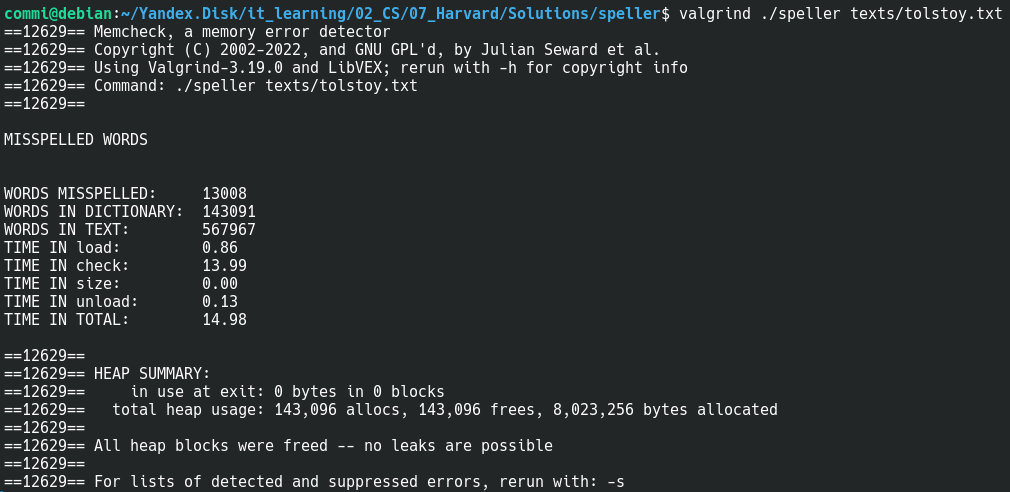

*valgrind ./speller*

## W5 [Trie](https://cs50.harvard.edu/x/2023/problems/5/trie/)

**Learning Goals**

- Learn more about data structures
- Work with a trie

**Background**

Imagine you just rescued a dog and you’re deciding on a name. You found a file online with a list of about 150 of the most popular dog names! You are curious as to whether or not the names you are considering are on this list. Since trie’s are great for data lookups, we’ve given you some (almost!) complete code in `trie.c`. There is one function, `check`, which is not yet implemented. Your job is to complete this function.

```python
pwd
```

```
/home/commi/Yandex.Disk/it_learning/02_CS/07_Harvard
```

```python
cd Solutions
wget https://cdn.cs50.net/2022/fall/labs/5/trie.zip
unzip trie.zip
rm -f trie.zip
cd trie
ls
```

```
--2023-11-03 23:21:12--  https://cdn.cs50.net/2022/fall/labs/5/trie.zip
Resolving cdn.cs50.net (cdn.cs50.net)... 52.85.49.57, 52.85.49.70, 52.85.49.79, ...
Connecting to cdn.cs50.net (cdn.cs50.net)|52.85.49.57|:443... connected.
HTTP request sent, awaiting response... 200 OK
Length: 2164 (2,1K) [application/zip]
Saving to: ‘trie.zip’

trie.zip            100%[===================>]   2,11K  --.-KB/s    in 0s

2023-11-03 23:21:12 (36,5 MB/s) - ‘trie.zip’ saved [2164/2164]

Archive:  trie.zip
   creating: trie/
  inflating: trie/dog_names.txt
  inflating: trie/trie.c
dog_names.txt  trie.c
```

**Implementation Details**

Notice that the trie itself is implemented through the creative use of several structs called `node`. Each `node` in a trie has an array of (potential) children, with size 26 — one potential child for each letter of the alphabet! Adding words to this trie, notice that — for every letter in a word — we create a new `node` child whose parent is either the root `node` (for the first letter) or the previous letter (if not the first letter). On the very last letter, we set the `is_word` attribute of the child node to true. Now, checking if a word is in our trie is as easy as following each letter of that word through our trie. If we get to the final letter and see that `is_word` is true, well, that name is in our trie!

```python
cat trie.c
```

```
// Saves popular dog names in a trie
// https://www.dailypaws.com/dogs-puppies/dog-names/common-dog-names

#include <cs50.h>
#include <ctype.h>
#include <stdbool.h>
#include <stdio.h>
#include <stdlib.h>
#include <string.h>

#define SIZE_OF_ALPHABET 26
#define MAXCHAR 20

typedef struct node
{
    bool is_word;
    struct node *children[SIZE_OF_ALPHABET];
} node;

// Function prototypes
bool check(char *word);
bool unload(void);
void unloader(node *current);

// Root of trie
node *root;

// Buffer to read dog names into
char name[MAXCHAR];

int main(int argc, char *argv[])
{
    // Check for command line args
    if (argc != 2)
    {
        printf("Usage: ./trie infile\n");
        return 1;
    }

    // File with names
```

[output cut: 86 more lines]

```

    // Iterate over all the children to see if they point to anything and go
    // there if they do point
    for (int i = 0; i < SIZE_OF_ALPHABET; i++)
    {
        if (current->children[i] != NULL)
        {
            unloader(current->children[i]);
        }
    }

    // After we check all the children point to null we can get rid of the node
    // and return to the previous iteration of this function.
    free(current);
}
```

**Hints**

- You probably want to start by setting a `node` pointer, cursor to the root of the trie.
- Iterate through every letter in the argument word and, as you do, determine the array index that corresponds to that letter.
- You can use the index for a letter to check if `children[index]` is a `NULL` pointer, meaning the word does not exist in the trie.
- If `children[index]` is in fact a `node`, you can reset cursor to this `node` and check for the next letter in its children nodes.
- Remember that the lookup should be case-insensitive. For instance, `A` and `a` should correspond to `0`, `B` and `b` corresponds to `1`, etc.

**Thought Question**

When might you want to use a trie as a data structure? When might you not?

**How to Test Your Code**

Your program should behave per the examples below.

```
trie/ $ ./trie dog_names.txt
Check word: Molly
Found!
trie/ $ ./trie dog_names.txt
Check word: Lucy
Found!
trie/ $ ./trie dog_names.txt
Check word: Prudence
Not Found.
```

### Solution

```
// Saves popular dog names in a trie
// https://www.dailypaws.com/dogs-puppies/dog-names/common-dog-names

#include <cs50.h>
#include <ctype.h>
#include <stdbool.h>
#include <stdio.h>
#include <stdlib.h>
#include <string.h>

#define SIZE_OF_ALPHABET 26
#define MAXCHAR 20

typedef struct node
{
    bool is_word;
    struct node *children[SIZE_OF_ALPHABET];
} node;

// Function prototypes
bool check(char *word);
bool unload(void);
void unloader(node *current);

// Root of trie
node *root;

// Buffer to read dog names into
char name[MAXCHAR];

int main(int argc, char *argv[])
{
    // Check for command line args
    if (argc != 3)
    {
        printf("Usage: ./trie infile name\n");
        return 1;
    }

    // File with names
    FILE *infile = fopen(argv[1], "r");
    if (!infile)
    {
        printf("Error opening file!\n");
        return 1;
    }

    // Allocate root of trie
    root = malloc(sizeof(node));

    if (root == NULL)
    {
        return 1;
    }

    root->is_word = false;
    for (int i = 0; i < SIZE_OF_ALPHABET; i++)
    {
        root->children[i] = NULL;
    }

    // Add words to the trie
    while (fscanf(infile, "%s", name) == 1)
    {
        node *cursor = root;

        for (int i = 0, n = strlen(name); i < n; i++)
        {
            int index = tolower(name[i]) - 'a';
            if (cursor->children[index] == NULL)
            {

                // Make node
                node *new = malloc(sizeof(node));
                new->is_word = false;
                for (int j = 0; j < SIZE_OF_ALPHABET; j++)
                {
                    new->children[j] = NULL;
                }
                cursor->children[index] = new;
            }

            // Go to node which we may have just been made
            cursor = cursor->children[index];
        }

        // if we are at the end of the word, mark it as being a word
        cursor->is_word = true;
    }

	printf("Check word: %s\n", argv[2]);
    if (check(argv[2]))
    {
        printf("Found!\n");
    }
    else
    {
        printf("Not Found.\n");
    }

    if (!unload())
    {
        printf("Problem freeing memory!\n");
        return 1;
    }

    fclose(infile);
}

// TODO: Complete the check function, return true if found, false if not found
bool check(char *word)
{
	node *cursor = root;
	for (int i = 0, n = strlen(word); i < n; i++)
	{
		int idx = tolower(word[i]) - 'a';
		if (cursor->children[idx] == NULL)
		{
			return false;
		}
		cursor = cursor->children[idx];
	}
    return true;
}

// Unload trie from memory
bool unload(void)
{

    // The recursive function handles all of the freeing
    unloader(root);

    return true;
}

void unloader(node *current)
{

    // Iterate over all the children to see if they point to anything and go
    // there if they do point
    for (int i = 0; i < SIZE_OF_ALPHABET; i++)
    {
        if (current->children[i] != NULL)
        {
            unloader(current->children[i]);
        }
    }

    // After we check all the children point to null we can get rid of the node
    // and return to the previous iteration of this function.
    free(current);
}
```

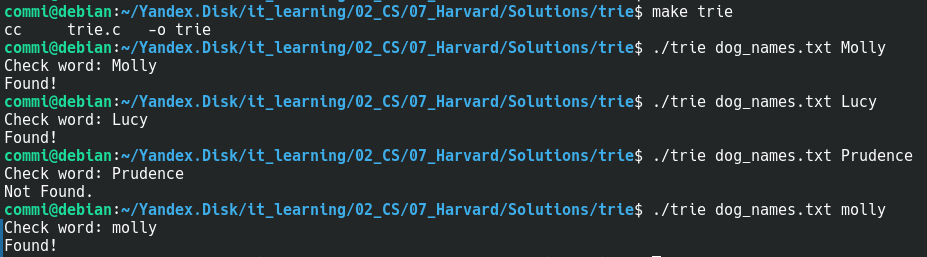

*Trie Dog Names*

# Week 6 Python

## Lab 6: [World Cup](https://cs50.harvard.edu/x/2023/labs/6/)

Write a program to run simulations of the FIFA World Cup.

```
$ python tournament.py 2018m.csv
Belgium: 20.9% chance of winning
Brazil: 20.3% chance of winning
Portugal: 14.5% chance of winning
Spain: 13.6% chance of winning
Switzerland: 10.5% chance of winning
Argentina: 6.5% chance of winning
England: 3.7% chance of winning
France: 3.3% chance of winning
Denmark: 2.2% chance of winning
Croatia: 2.0% chance of winning
Colombia: 1.8% chance of winning
Sweden: 0.5% chance of winning
Uruguay: 0.1% chance of winning
Mexico: 0.1% chance of winning
```

**Background**

In soccer’s World Cup, the knockout round consists of 16 teams. In each round, each team plays another team and the losing teams are eliminated. When only two teams remain, the winner of the final match is the champion.

In soccer, teams are given FIFA Ratings, which are numerical values representing each team’s relative skill level. Higher FIFA ratings indicate better previous game results, and given two teams’ FIFA ratings, it’s possible to estimate the probability that either team wins a game based on their current ratings. The FIFA Ratings from previous World Cups are available as the [May 2018 Men’s FIFA Ratings](https://www.fifa.com/fifa-world-ranking/ranking-table/men/rank/id12189/) and [March 2019 Women’s FIFA Ratings](https://www.fifa.com/fifa-world-ranking/ranking-table/women/rank/ranking_20190329/).

Using this information, we can simulate the entire tournament by repeatedly simulating rounds until we’re left with just one team. And if we want to estimate how likely it is that any given team wins the tournament, we might simulate the tournament many times (e.g. `1000` simulations) and count how many times each team wins a simulated tournament. `1000` simulations might seem like many, but with today’s computing power we can accomplish those simulations in a matter of milliseconds. At the end of this lab, we’ll experiment with how worthwhile it might be to increase the number of simulations we run, given the trade-off of runtime.

Your task in this lab is to do just that using Python!

```python
pwd
```

```
/home/commi/Yandex.Disk/it_learning/02_CS/07_Harvard
```

```python
cd Solutions
wget https://cdn.cs50.net/2022/fall/labs/6/world-cup.zip
unzip world-cup.zip
rm -f world-cup.zip
cd world-cup
ls
```

```
--2023-11-04 23:02:24--  https://cdn.cs50.net/2022/fall/labs/6/world-cup.zip
Resolving cdn.cs50.net (cdn.cs50.net)... 108.157.214.7, 108.157.214.44, 108.157.214.93, ...
Connecting to cdn.cs50.net (cdn.cs50.net)|108.157.214.7|:443... connected.
HTTP request sent, awaiting response... 200 OK
Length: 2052 (2,0K) [application/zip]
Saving to: ‘world-cup.zip’

world-cup.zip       100%[===================>]   2,00K  --.-KB/s    in 0s

2023-11-04 23:02:25 (5,39 MB/s) - ‘world-cup.zip’ saved [2052/2052]

Archive:  world-cup.zip
   creating: world-cup/
  inflating: world-cup/2018m.csv
  inflating: world-cup/answers.txt
  inflating: world-cup/2019w.csv
  inflating: world-cup/tournament.py
2018m.csv  2019w.csv  answers.txt  tournament.py
```

and you should see the following files:

```
answers.txt  2018m.csv  2019w.csv  tournament.py
```

**Understanding**

Start by taking a look at the `2018m.csv` file. This file contains the `16` teams in the knockout round of the 2018 Men’s World Cup and the ratings for each team. Notice that the CSV file has two columns, one called `team` (representing the team’s country name) and one called `rating` (representing the team’s rating).

The order in which the teams are listed determines which teams will play each other in each round (in the first round, for example, Uruguay will play Portugal and France will play Argentina; in the next round, the winner of the Uruguay-Portugal match will play the winner of the France-Argentina match). So be sure not to edit the order in which teams appear in this file!

```python
import pandas as pd

trm2018 = pd.read_csv("./Solutions/world-cup/2018m.csv")

trm2018.head(12)
```

|  | team | rating |
| --- | --- | --- |
| 0 | Uruguay | 976 |
| 1 | Portugal | 1306 |
| 2 | France | 1166 |
| 3 | Argentina | 1254 |
| 4 | Brazil | 1384 |
| 5 | Mexico | 1008 |
| 6 | Belgium | 1346 |
| 7 | Japan | 528 |
| 8 | Spain | 1162 |
| 9 | Russia | 493 |
| 10 | Croatia | 975 |
| 11 | Denmark | 1054 |

Ultimately, in Python, we can represent each team as a dictionary that contains two values: the `team` name and the `rating`. Uruguay, for example, we would want to represent in Python as `{"team": "Uruguay", "rating": 976}`.

Next, take a look at `2019w.csv`, which contains data formatted the same way for the 2019 Women’s World Cup.

```python
trm2019 = pd.read_csv("./Solutions/world-cup/2019w.csv")

trm2019.head(12)
```

|  | team | rating |
| --- | --- | --- |
| 0 | Norway | 1915 |
| 1 | Australia | 2003 |
| 2 | England | 2049 |
| 3 | Cameroon | 1499 |
| 4 | France | 2043 |
| 5 | Brazil | 1944 |
| 6 | Spain | 1913 |
| 7 | United States | 2101 |
| 8 | Italy | 1868 |
| 9 | China PR | 1866 |
| 10 | Netherlands | 1967 |
| 11 | Japan | 1991 |

Now, open `tournament.py` and see that we’ve already written some code for you. The variable `N` at the top represents how many World Cup simulations to run: in this case, `1000`.

```
# Simulate a sports tournament

import csv
import sys
import random

# Number of simluations to run
N = 1000


def main():

    # Ensure correct usage
    if len(sys.argv) != 2:
        sys.exit("Usage: python tournament.py FILENAME")

    teams = []
    # TODO: Read teams into memory from file

    counts = {}
    # TODO: Simulate N tournaments and keep track of win counts

    # Print each team's chances of winning, according to simulation
    for team in sorted(counts, key=lambda team: counts[team], reverse=True):
        print(f"{team}: {counts[team] * 100 / N:.1f}% chance of winning")


def simulate_game(team1, team2):
    """Simulate a game. Return True if team1 wins, False otherwise."""
    rating1 = team1["rating"]
    rating2 = team2["rating"]
    probability = 1 / (1 + 10 ** ((rating2 - rating1) / 600))
    return random.random() < probability


def simulate_round(teams):
    """Simulate a round. Return a list of winning teams."""
    winners = []

    # Simulate games for all pairs of teams
    for i in range(0, len(teams), 2):
        if simulate_game(teams[i], teams[i + 1]):
            winners.append(teams[i])
        else:
            winners.append(teams[i + 1])

    return winners


def simulate_tournament(teams):
    """Simulate a tournament. Return name of winning team."""
    # TODO


if __name__ == "__main__":
    main()
```

The `simulate_game` function accepts two teams as inputs (recall that each team is a dictionary containing the `team` name and the team’s `rating`), and simulates a game between them. If the first team wins, the function returns `True`; otherwise, the function returns False.

The `simulate_round` function accepts a list of teams (in a variable called `teams`) as input, and simulates games between each pair of teams. The function then returns a list of all of the teams that won the round.

In the `main` function, notice that we first ensure that `len(sys.argv)` (the number of command-line arguments) is `2`. We’ll use command-line arguments to tell Python which team CSV file to use to run the tournament simulation. We’ve then defined a list called `teams` (which will eventually be a list of teams) and a dictionary called `counts` (which will associate team names with the number of times that team won a simulated tournament). Right now they’re both empty, so populating them is left up to you!

Finally, at the end of main, we sort the teams in descending order of how many times they won simulations (according to counts) and print the estimated probability that each team wins the World Cup.

Populating `teams` and `counts` and writing the `simulate_tournament` function are left up to you!

**Implementation Details**

Complete the implementation of `tournament.py`, such that it simulates a number of tournaments and outputs each team’s probability of winning.

First, in `main`, read the team data from the CSV file into your program’s memory, and add each team to the list teams.

- The file to use will be provided as a command-line argument. You can access the name of the file, then, with `sys.argv[1]`.
- Recall that you can open a file `with open(filename)`, where filename is a variable storing the name of the file.
- Once you have a file `f`, you can use `csv.DictReader(f)` to give you a “reader”: an object in Python that you can loop over to read the file one row at a time, treating each row as a dictionary.
- By default, all values read from the file will be strings. So be sure to first convert the team’s rating to an `int` (you can use the `int` function in Python to do this).
- Ultimately, append each team’s dictionary to teams. The function call `teams.append(x)` will append `x` to the list `teams`.
- Recall that each team should be a dictionary with a team `name` and a `rating`.

Next, implement the `simulate_tournament` function. This function should accept as input a list of teams and should repeatedly simulate rounds until you’re left with one team. The function should then return the name of that team.

- You can call the `simulate_round` function, which simulates a single round, accepting a list of teams as input and returning a list of all of the winners.
- Recall that if `x` is a list, you can use `len(x)` to determine the length of the list.
- You should not assume the number of teams in the tournament, but you may assume it will be a power of `2`.

Finally, back in the `main` function, run `N` tournament simulations, and keep track of how many times each team wins in the counts dictionary.

- For example, if Uruguay won 2 tournaments and Portugal won 3 tournaments, then your counts dictionary should be {"Uruguay": 2, "Portugal": 3}.
- You should use your `simulate_tournament` to simulate each tournament and determine the winner.
- Recall that if `counts` is a dictionary, then syntax like `counts[team_name] = x` will associate the key stored in `team_name` with the value stored in `x`.
- You can use the `in` keyword in Python to check if a dictionary has a particular key already. For example, `if "Portugal" in counts:` will check to see if "Portugal" already has an existing value in the counts dictionary.

**Hints**

When reading in the file, you may find this syntax helpful, with filename as the name of your file and file as a variable.

```
with open(filename) as file:
      reader = csv.DictReader(file)
```

In Python, to append to the end of a list, use the `.append()` function.

**Testing**

Your program should behave per the examples below. Since simulations have randomness within each, your output will likely not perfectly match the examples below.

```
$ python tournament.py 2018m.csv
Belgium: 20.9% chance of winning
Brazil: 20.3% chance of winning
Portugal: 14.5% chance of winning
Spain: 13.6% chance of winning
Switzerland: 10.5% chance of winning
Argentina: 6.5% chance of winning
England: 3.7% chance of winning
France: 3.3% chance of winning
Denmark: 2.2% chance of winning
Croatia: 2.0% chance of winning
Colombia: 1.8% chance of winning
Sweden: 0.5% chance of winning
Uruguay: 0.1% chance of winning
Mexico: 0.1% chance of winning

$ python tournament.py 2019w.csv
Germany: 17.1% chance of winning
United States: 14.8% chance of winning
England: 14.0% chance of winning
France: 9.2% chance of winning
Canada: 8.5% chance of winning
Japan: 7.1% chance of winning
Australia: 6.8% chance of winning
Netherlands: 5.4% chance of winning
Sweden: 3.9% chance of winning
Italy: 3.0% chance of winning
Norway: 2.9% chance of winning
Brazil: 2.9% chance of winning
Spain: 2.2% chance of winning
China PR: 2.1% chance of winning
Nigeria: 0.1% chance of winning
```

You might be wondering what actually happened at the 2018 and 2019 World Cups! For Men’s, France won, defeating Croatia in the final. Belgium defeated England for the third place position. For Women’s, the United States won, defeating the Netherlands in the final. England defeated Sweden for the third place position.

**Number of Simulations**

Once you’re sure your code is correct, let’s tinker with the value of `N`, the constant at the top of our file, to adjust the number of times we simulate the tournament. More tournament simulations will give us more accurate predictions (why?), at the cost of time.

We can time programs by prepending their execution at the command-line with `time`. For example, with `N` set to `1000` (the default) execute

```
time python tournament.py 2018m.csv
```

or

```
time python tournament.py 2019w.csv
```

which should output something like

```
real    0m0.037s
user    0m0.028s
sys     0m0.008s
```

though your own times might vary.

Pay attention to the real metric, which is the time, in total, it took `tournament.py` to run. And notice that you’re given time in minutes and seconds, with accuracy to thousandths of a second.

In `answers.txt`, keep track of how long it takes `tournament.py` to simulate…

```
10 (ten) tournaments
100 (one hundred) tournaments
1000 (one thousand) tournaments
10000 (ten thousand) tournaments
100000 (one hundred thousand) tournaments
1000000 (one million) tournaments
```

Each time you adjust `N`, record the real time in the appropriate `TODO` in `answers.txt` by using the same `0m0.000s` format. After timing each scenario, answer the two follow-up questions by overwriting the given `TODO`:

- Which predictions, if any, proved incorrect as you increased the number of simulations?
- Suppose you’re charged a fee for each second of compute time your program uses. After how many simulations would you call the predictions “good enough”?

### Solution

```
# Simulate a sports tournament

import csv
import sys
import random
from pathlib import Path

# Number of simluations to run
N = 100_000


def main():

    # Ensure correct usage
    if len(sys.argv) != 2:
        sys.exit("Usage: python tournament.py FILENAME")

    teams = []
    # TODO: Read teams into memory from file
    with open(sys.argv[1]) as f:
        reader = csv.DictReader(f)
        for pair in reader:
            pair['rating'] = int(pair['rating'])
            teams.append(pair)


    counts = {}
    # TODO: Simulate N tournaments and keep track of win counts
    for i in range(N):
        tournament_winner = simulate_tournament(teams)[0]['team']
        counts[tournament_winner] = counts.get(tournament_winner, 0) + 1


    # Print each team's chances of winning, according to simulation
    for team in sorted(counts, key=lambda team: counts[team], reverse=True):
        print(f"{team}: {counts[team] * 100 / N:.1f}% chance of winning")


def simulate_game(team1, team2):
    """Simulate a game. Return True if team1 wins, False otherwise."""
    rating1 = team1["rating"]
    rating2 = team2["rating"]
    probability = 1 / (1 + 10 ** ((rating2 - rating1) / 600))
    return random.random() < probability


def simulate_round(teams):
    """Simulate a round. Return a list of winning teams."""
    winners = []

    # Simulate games for all pairs of teams
    for i in range(0, len(teams), 2):
        if simulate_game(teams[i], teams[i + 1]):
            winners.append(teams[i])
        else:
            winners.append(teams[i + 1])

    return winners


def simulate_tournament(teams):
    """Simulate a tournament. Return name of winning team."""
    # TODO
    while(len(teams) > 1):
        teams = simulate_round(teams)
    return teams


if __name__ == "__main__":
    main()
```

**Academic Honesty**

- For `Hello`, `Mario`, `Cash`, `Credit`, and `Readability`, it is reasonable to look at your own implementations thereof in C and others’ implementations thereof in C.
- It is not reasonable to look at others’ implementations of the same in Python.

Insofar as a goal of these problems is to teach you how to teach yourself a new language, keep in mind that these acts are not only reasonable, per the syllabus, but encouraged toward that end:

- Incorporating a few lines of code that you find online or elsewhere into your own code, provided that those lines are not themselves solutions to assigned problems and that you cite the lines’ origins.
- Turning to the web or elsewhere for instruction beyond the course’s own, for references, and for solutions to technical difficulties, but not for outright solutions to problem set’s problems or your own final project.

## W6 [Hello](https://cs50.harvard.edu/x/2023/psets/6/hello/)

```python
def main():
    name = input("What is your name?")
    print(f"Hello, {name}! You're awesome!")

main()
```

```
Hello, Lenin! You're awesome!
```

## W6 [Mario](https://cs50.harvard.edu/x/2023/psets/6/mario/more/)

[figure not shown]

Implement a program that prints out a double half-pyramid of a specified height, per the below.

```
$ python mario.py
Height: 4
   #  #
  ##  ##
 ###  ###
####  ####
```

**Specification**

- Write, in a file called `mario.py`, a program that recreates these half-pyramids using hashes (`#`) for blocks, exactly as you did in Problem Set 1, except that your program this time should be written in Python.
- To make things more interesting, first prompt the user with `get_int` for the half-pyramid’s height, a positive integer between `1` and `8`, inclusive. (The height of the half-pyramids pictured above happens to be `4`, the width of each half-pyramid `4`, with a gap of size `2` separating them).
- If the user fails to provide a positive integer no greater than `8`, you should re-prompt for the same again.
- Then, generate (with the help of `print` and one or more loops) the desired half-pyramids.
- Take care to align the bottom-left corner of your pyramid with the left-hand edge of your terminal window, and ensure that there are two spaces between the two pyramids, and that there are no additional spaces after the last set of hashes on each row.

**Usage**

- Your program should behave per the example below.

```
$ python mario.py
Height: 4
   #  #
  ##  ##
 ###  ###
####  ####
```

**Testing**

- Run your program as python `mario.py` and wait for a prompt for input. Type in `-1` and press `enter`. Your program should reject this input as invalid, as by re-prompting the user to type in another number.
- Run your program as python `mario.py` and wait for a prompt for input. Type in `0` and press `enter`. Your program should reject this input as invalid, as by re-prompting the user to type in another number.
- Run your program as python `mario.py` and wait for a prompt for input. Type in `1` and press enter. Your program should generate the below output. Be sure that the pyramid is aligned to the bottom-left corner of your terminal, and that there are no extra spaces at the end of each line.

```
#  #
```

- Run your program as python `mario.py` and wait for a prompt for input. Type in `2` and press `enter`. Your program should generate the below output. Be sure that the pyramid is aligned to the bottom-left corner of your terminal, and that there are no extra spaces at the end of each line.

```
 #  #
##  ##
```

- Run your program as python `mario.py` and wait for a prompt for input. Type in `8` and press `enter`. Your program should generate the below output. Be sure that the pyramid is aligned to the bottom-left corner of your terminal, and that there are no extra spaces at the end of each line.

```
       #  #
      ##  ##
     ###  ###
    ####  ####
   #####  #####
  ######  ######
 #######  #######
########  ########
```

- Run your program as python `mario.py` and wait for a prompt for input. Type in `9` and press `enter`. Your program should reject this input as invalid, as by re-prompting the user to type in another number. Then, type in 2 and press enter. Your program should generate the below output. Be sure that the pyramid is aligned to the bottom-left corner of your terminal, and that there are no extra spaces at the end of each line.

```
 #  #
##  ##
```

- Run your program as python `mario.py` and wait for a prompt for input. Type in `foo` and press `enter`. Your program should reject this input as invalid, as by re-prompting the user to type in another number.
- Run your program as python `mario.py` and wait for a prompt for input. Do not type anything, and press `enter`. Your program should reject this input as invalid, as by re-prompting the user to type in another number.

```python
def main():

    height = get_int("Height: ")

    while height < 1 or height > 8:
        print("Choose a number between 1 and 8")
        height = get_int("Height: ")

    for i in range(height):

        empty_line = ''
        bricks = ''

        counter = 0
        while counter < height - i - 1:
            empty_line += ' '
            counter += 1

        for j in range(i+1):
            bricks += '#'

        print(empty_line + bricks + '  ' + bricks)


def get_int(prompt):
    while True:
        try:
            return int(input(prompt))
        except ValueError:
            print("Not an integer")


main()
```

```
Choose a number between 1 and 8
```

```
Choose a number between 1 and 8
```

```
Choose a number between 1 and 8
```

```
Not an integer
```

```
Not an integer
```

```
   #  #
  ##  ##
 ###  ###
####  ####
```

## W6 [Credit](https://cs50.harvard.edu/x/2023/psets/6/credit/)

Implement a program that determines whether a provided credit card number is valid according to Luhn’s algorithm.

```
$ python credit.py
Number: 378282246310005
AMEX
```

**Specification**

- In `credit.py`, write a program that prompts the user for a credit card number and then reports (via `print`) whether it is a valid American Express, MasterCard, or Visa card number, exactly as you did in Problem Set 1, except that your program this time should be written in Python.
- So that we can automate some tests of your code, we ask that your program’s last line of output be `AMEX\n` or `MASTERCARD\n` or `VISA\n` or `INVALID\n`, nothing more, nothing less.
- For simplicity, you may assume that the user’s input will be entirely numeric (i.e., devoid of hyphens, as might be printed on an actual card).
- Best to use `get_int` or `get_string` from CS50’s library to get users’ input, depending on how you to decide to implement this one.

**Usage**

Your program should behave per the example below.

```
$ python credit.py
Number: 378282246310005
AMEX
```

**Hints**

- It’s possible to use regular expressions to validate user input. You might use Python’s `re` module, for example, to check whether the user’s input is indeed a sequence of digits of the correct length.

**Testing**

- Run your program as python `credit.py`, and wait for a prompt for input. Type in `378282246310005` and press enter. Your program should output `AMEX`.
- Run your program as python `credit.py`, and wait for a prompt for input. Type in `371449635398431` and press enter. Your program should output `AMEX`.
- Run your program as python `credit.py`, and wait for a prompt for input. Type in `5555555555554444` and press enter. Your program should output `MASTERCARD`.
- Run your program as python `credit.py`, and wait for a prompt for input. Type in `5105105105105100` and press enter. Your program should output `MASTERCARD`.
- Run your program as python `credit.py`, and wait for a prompt for input. Type in `4111111111111111` and press enter. Your program should output `VISA`.
- Run your program as python `credit.py`, and wait for a prompt for input. Type in `4012888888881881` and press enter. Your program should output `VISA`.
- Run your program as python `credit.py`, and wait for a prompt for input. Type in `1234567890` and press enter. Your program should output `INVALID`.

American Express uses 15-digit numbers, MasterCard uses 16-digit numbers, and Visa uses 13- and 16-digit numbers. And those are decimal numbers (0 through 9), not binary. All American Express numbers start with 34 or 37; most MasterCard numbers start with 51, 52, 53, 54, or 55 (they also have some other potential starting numbers which we won’t concern ourselves with for this problem); and all Visa numbers start with 4.

```python
def main():

    number = get_int("Enter a card number: ")

    # let's add 0 digit to the beginning of the list if it's modulo 2 is not 0
    # it will allow us to go by two digits in each iteration
    changed = False
    if len(number) % 2 != 0:
        number = [0] + number
        changed = True

    # let's create a list for all the numbers
    lst = list()

    for i in range(len(number)-1, 0, -2):

        lst.append(int(number[i]))

        every_other_digit = int(number[i-1])*2
        if every_other_digit > 9:
            for j in str(every_other_digit):
                lst.append(int(j))
        else:
            lst.append(every_other_digit)

    length = (len(number) - 1) if changed else len(number)

    print(length)
    if sum(lst) % 10 == 0:
        if length == 15:
            print('AMEX\n')
        elif (length == 13 or len(number) == 16) and int(number[0]) == 4:
            print('VISA\n')
        else:
            print('MASTERCARD\n')
    else:
        print('Invalid'.upper())


def get_int(prompt):
    while True:
        try:
            return [int(i) for i in input(prompt)]
        except:
            print("Not an Integer")


main()
```

```
15
AMEX
```

## W6 [Readability](https://cs50.harvard.edu/x/2023/psets/6/readability/)

Implement a program that computes the approximate grade level needed to comprehend some text, per the below.

```
$ python readability.py
Text: Congratulations! Today is your day. You're off to Great Places! You're off and away!
Grade 3
```

**Specification**

- Write, in a file called `readability.py`, a program that first asks the user to type in some text, and then outputs the grade level for the text, according to the Coleman-Liau formula, exactly as you did in Problem Set 2, except that your program this time should be written in Python.
- Recall that the Coleman-Liau index is computed as $0.0588 * L - 0.296 * S - 15.8$, where
  - `L` is the average number of letters per `100` words in the text, and
  - `S` is the average number of sentences per `100` words in the text.
- Use `get_string` from the CS50 Library to get the user’s input, and print to output your answer.
- Your program should count the number of letters, words, and sentences in the text. You may assume that a letter is any lowercase character from a to z or any uppercase character from A to Z, any sequence of characters separated by spaces should count as a word, and that any occurrence of a period, exclamation point, or question mark indicates the end of a sentence.
- Your program should print as output `"Grade X"` where `X` is the grade level computed by the Coleman-Liau formula, rounded to the nearest integer.
- If the resulting index number is `16` or higher (equivalent to or greater than a senior undergraduate reading level), your program should output `"Grade 16+"` instead of giving the exact index number. If the index number is less than 1, your program should output "Before Grade 1".

**Usage**

Your program should behave per the example below.

```
$ python readability.py
Text: Congratulations! Today is your day. You're off to Great Places! You're off and away!
Grade 3
```

**Testing**

- Run your program as `python readability.py`, and wait for a prompt for input. Type in `One fish. Two fish. Red fish. Blue fish.` and press enter. Your program should output `Before Grade 1`.
- Run your program as `python readability.py`, and wait for a prompt for input. Type in `Would you like them here or there? I would not like them here or there. I would not like them anywhere.` and press enter. Your program should output `Grade 2`.
- Run your program as `python readability.py`, and wait for a prompt for input. Type in `Congratulations! Today is your day. You're off to Great Places! You're off and away!` and press enter. Your program should output `Grade 3`.
- Run your program as `python readability.py`, and wait for a prompt for input. Type in `Harry Potter was a highly unusual boy in many ways. For one thing, he hated the summer holidays more than any other time of year. For another, he really wanted to do his homework, but was forced to do it in secret, in the dead of the night. And he also happened to be a wizard.` and press enter. Your program should output `Grade 5`.
- Run your program as `python readability.py`, and wait for a prompt for input. Type in `In my younger and more vulnerable years my father gave me some advice that I've been turning over in my mind ever since.` and press enter. Your program should output `Grade 7`.
- Run your program as `python readability.py`, and wait for a prompt for input. Type in `Alice was beginning to get very tired of sitting by her sister on the bank, and of having nothing to do: once or twice she had peeped into the book her sister was reading, but it had no pictures or conversations in it, "and what is the use of a book," thought Alice "without pictures or conversation?"` and press enter. Your program should output `Grade 8`.
- Run your program as `python readability.py`, and wait for a prompt for input. Type in `When he was nearly thirteen, my brother Jem got his arm badly broken at the elbow. When it healed, and Jem's fears of never being able to play football were assuaged, he was seldom self-conscious about his injury. His left arm was somewhat shorter than his right; when he stood or walked, the back of his hand was at right angles to his body, his thumb parallel to his thigh.` and press enter. Your program should output `Grade 8`.
- Run your program as `python readability.py`, and wait for a prompt for input. Type in `There are more things in Heaven and Earth, Horatio, than are dreamt of in your philosophy.` and press enter. Your program should output `Grade 9`.
- Run your program as `python readability.py`, and wait for a prompt for input. Type in `It was a bright cold day in April, and the clocks were striking thirteen. Winston Smith, his chin nuzzled into his breast in an effort to escape the vile wind, slipped quickly through the glass doors of Victory Mansions, though not quickly enough to prevent a swirl of gritty dust from entering along with him.` and press enter. Your program should output `Grade 10`.
- Run your program as `python readability.py`, and wait for a prompt for input. Type in `A large class of computational problems involve the determination of properties of graphs, digraphs, integers, arrays of integers, finite families of finite sets, boolean formulas and elements of other countable domains.` and press enter. Your program should output `Grade 16+`.

```python
import re

help(re.match)
```

```
Help on function match in module re:

match(pattern, string, flags=0)
    Try to apply the pattern at the start of the string, returning
    a Match object, or None if no match was found.
```

```python
import re

def main():

    text = input("Text: ")

    letters = count_letters(text)
    words = count_words(text)
    sentences = count_sentences(text)

    L = letters / words * 100
    S = sentences / words * 100
    index = 0.0588 * L - 0.296 * S - 15.8

    grade = round(index)

    if grade < 1:
        print("Before Grade 1")
    elif grade > 15:
        print("Grade 16+")
    else:
        print(f"Grade {grade}")


def count_letters(text):

    letters_sum = 0;

    for i in range(len(text)):
        if re.match('[a-zA-Z]', text[i]) is not None:
            letters_sum += 1
        else:
            continue

    return letters_sum


def count_words(text):

    words = 1;

    for i in range(len(text)):
        if re.match('[ ]', text[i]) is not None:
            words += 1
        else:
            continue

    return words


def count_sentences(text):

    sentences = 0;

    for i in range(len(text)):
        if re.match('[.!?]', text[i]) is not None:
            sentences += 1
        else:
            continue

    return sentences


main()
```

```
Grade 16+
```

## W6 [DNA](https://cs50.harvard.edu/x/2023/psets/6/dna/)

Implement a program that identifies a person based on their DNA, per the below.

```
$ python dna.py databases/large.csv sequences/5.txt
Lavender
```

```python
pwd
```

```
/home/commi/Yandex.Disk/it_learning/02_CS/07_Harvard
```

```python
cd ./Solutions
wget https://cdn.cs50.net/2022/fall/psets/6/dna.zip
unzip dna.zip
rm -f dna.zip
cd dna
ls
```

```
--2023-11-14 15:17:40--  https://cdn.cs50.net/2022/fall/psets/6/dna.zip
Resolving cdn.cs50.net (cdn.cs50.net)... 65.9.55.9, 65.9.55.69, 65.9.55.105, ...
Connecting to cdn.cs50.net (cdn.cs50.net)|65.9.55.9|:443... connected.
HTTP request sent, awaiting response... 200 OK
Length: 32908 (32K) [application/zip]
Saving to: ‘dna.zip’

dna.zip             100%[===================>]  32,14K  --.-KB/s    in 0,01s

2023-11-14 15:17:41 (2,75 MB/s) - ‘dna.zip’ saved [32908/32908]

Archive:  dna.zip
   creating: dna/
   creating: dna/databases/
  inflating: dna/databases/large.csv
  inflating: dna/databases/small.csv
  inflating: dna/dna.py
   creating: dna/sequences/
  inflating: dna/sequences/15.txt
  inflating: dna/sequences/14.txt
  inflating: dna/sequences/16.txt
  inflating: dna/sequences/17.txt
  inflating: dna/sequences/13.txt
  inflating: dna/sequences/12.txt
  inflating: dna/sequences/10.txt
  inflating: dna/sequences/11.txt
  inflating: dna/sequences/9.txt
  inflating: dna/sequences/8.txt
  inflating: dna/sequences/5.txt
  inflating: dna/sequences/4.txt
  inflating: dna/sequences/6.txt
  inflating: dna/sequences/7.txt
  inflating: dna/sequences/3.txt
  inflating: dna/sequences/2.txt
  inflating: dna/sequences/1.txt
  inflating: dna/sequences/20.txt
  inflating: dna/sequences/19.txt
  inflating: dna/sequences/18.txt
databases  dna.py  sequences
```

You should see a few files and folders:

```
databases/ dna.py sequences/
```

**Background**

DNA, the carrier of genetic information in living things, has been used in criminal justice for decades. But how, exactly, does DNA profiling work? Given a sequence of DNA, how can forensic investigators identify to whom it belongs?

Well, DNA is really just a sequence of molecules called **nucleotides**, arranged into a particular shape (a double helix). Every human cell has billions of nucleotides arranged in sequence. Each nucleotide of DNA contains one of four different bases: adenine (`A`), cytosine (`C`), guanine (`G`), or thymine (`T`). Some portions of this sequence (i.e., **genome**) are the same, or at least very similar, across almost all humans, but other portions of the sequence have a higher genetic diversity and thus vary more across the population.

One place where DNA tends to have high genetic diversity is in **Short Tandem Repeats (STRs)**. An STR is a short sequence of DNA bases that tends to repeat consecutively numerous times at specific locations inside of a person’s DNA. The number of times any particular STR repeats varies a lot among individuals. In the DNA samples below, for example, Alice has the STR AGAT repeated four times in her DNA, while Bob has the same STR repeated five times.

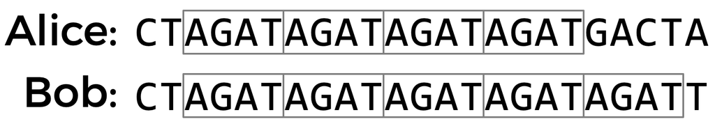

Using multiple STRs, rather than just one, can improve the accuracy of DNA profiling. If the probability that two people have the same number of repeats for a single STR is 5%, and the analyst looks at 10 different STRs, then the probability that two DNA samples match purely by chance is about 1 in 1 quadrillion (assuming all STRs are independent of each other). So if two DNA samples match in the number of repeats for each of the STRs, the analyst can be pretty confident they came from the same person. CODIS, the FBI’s [DNA database](https://www.fbi.gov/services/laboratory/biometric-analysis/codis/codis-and-ndis-fact-sheet), uses 20 different STRs as part of its DNA profiling process.

What might such a DNA database look like? Well, in its simplest form, you could imagine formatting a DNA database as a CSV file, wherein each row corresponds to an individual, and each column corresponds to a particular STR.

```
name,AGAT,AATG,TATC
Alice,28,42,14
Bob,17,22,19
Charlie,36,18,25
```

The data in the above file would suggest that Alice has the sequence `AGAT` repeated `28` times consecutively somewhere in her DNA, the sequence `AATG` repeated `42` times, and `TATC` repeated `14` times. Bob, meanwhile, has those same three STRs repeated `17` times, `22` times, and `19` times, respectively. And Charlie has those same three STRs repeated `36`, `18`, and `25` times, respectively.

So given a sequence of DNA, how might you identify to whom it belongs? Well, imagine that you looked through the DNA sequence for the longest consecutive sequence of repeated `AGAT`s and found that the longest sequence was `17` repeats long. If you then found that the longest sequence of `AATG` is `22` repeats long, and the longest sequence of TATC is `19` repeats long, that would provide pretty good evidence that the DNA was Bob’s. Of course, it’s also possible that once you take the counts for each of the STRs, it doesn’t match anyone in your DNA database, in which case you have no match.

In practice, since analysts know on which chromosome and at which location in the DNA an STR will be found, they can localize their search to just a narrow section of DNA. But we’ll ignore that detail for this problem.

Your task is to write a program that will take a sequence of DNA and a CSV file containing STR counts for a list of individuals and then output to whom the DNA (most likely) belongs.

**Specification**

In a file called `dna.py`, implement a program that identifies to whom a sequence of DNA belongs.

- The program should require as its first command-line argument the name of a CSV file containing the STR counts for a list of individuals and should require as its second command-line argument the name of a text file containing the DNA sequence to identify.
- If your program is executed with the incorrect number of command-line arguments, your program should print an error message of your choice (with `print`). If the correct number of arguments are provided, you may assume that the first argument is indeed the filename of a valid CSV file and that the second argument is the filename of a valid text file.
- Your program should open the CSV file and read its contents into memory.
- You may assume that the first row of the CSV file will be the column names. The first column will be the word name and the remaining columns will be the STR sequences themselves.
- Your program should open the DNA sequence and read its contents into memory.
- For each of the STRs (from the first line of the CSV file), your program should compute the longest run of consecutive repeats of the STR in the DNA sequence to identify. Notice that we’ve defined a helper function for you, `longest_match`, which will do just that!
- If the STR counts match exactly with any of the individuals in the CSV file, your program should print out the name of the matching individual.
- You may assume that the STR counts will not match more than one individual.
- If the STR counts do not match exactly with any of the individuals in the CSV file, your program should print `No match`.

**Usage**

Your program should behave per the example below:

```
$ python dna.py databases/large.csv sequences/5.txt
Lavender
$ python dna.py
Usage: python dna.py data.csv sequence.txt
$ python dna.py data.csv
Usage: python dna.py data.csv sequence.txt
```

**Hints**

- You may find Python’s `csv` module helpful for reading CSV files into memory. You may want to take advantage of either `csv.reader` or `csv.DictReader`.
- The open and read functions may prove useful for reading text files into memory.
- Consider what data structures might be helpful for keeping tracking of information in your program. A `list` or a `dict` may prove useful.
- Remember we’ve defined a function (`longest_match`) that, given both a DNA sequence and an STR as inputs, returns the maximum number of times that the STR repeats. You can then use that function in other parts of your program!

**Testing**

- Run your program as `python dna.py databases/small.csv sequences/1.txt`. Your program should output `Bob`.
- Run your program as `python dna.py databases/small.csv sequences/2.txt`. Your program should output `No match`.
- Run your program as `python dna.py databases/small.csv sequences/3.txt`. Your program should output `No match`.
- Run your program as `python dna.py databases/small.csv sequences/4.txt`. Your program should output `Alice`.
- Run your program as `python dna.py databases/large.csv sequences/5.txt`. Your program should output `Lavender`.
- Run your program as `python dna.py databases/large.csv sequences/6.txt`. Your program should output `Luna`.
- Run your program as `python dna.py databases/large.csv sequences/7.txt`. Your program should output `Ron`.
- Run your program as `python dna.py databases/large.csv sequences/8.txt`. Your program should output `Ginny`.
- Run your program as `python dna.py databases/large.csv sequences/9.txt`. Your program should output `Draco`.
- Run your program as `python dna.py databases/large.csv sequences/10.txt`. Your program should output `Albus`.
- Run your program as `python dna.py databases/large.csv sequences/11.txt`. Your program should output `Hermione`.
- Run your program as `python dna.py databases/large.csv sequences/12.txt`. Your program should output `Lily`.
- Run your program as `python dna.py databases/large.csv sequences/13.txt`. Your program should output `No match`.
- Run your program as `python dna.py databases/large.csv sequences/14.txt`. Your program should output `Severus`.
- Run your program as `python dna.py databases/large.csv sequences/15.txt`. Your program should output `Sirius`.
- Run your program as `python dna.py databases/large.csv sequences/16.txt`. Your program should output `No match`.
- Run your program as `python dna.py databases/large.csv sequences/17.txt`. Your program should output `Harry`.
- Run your program as `python dna.py databases/large.csv sequences/18.txt`. Your program should output `No match`.
- Run your program as `python dna.py databases/large.csv sequences/19.txt`. Your program should output `Fred`.
- Run your program as `python dna.py databases/large.csv sequences/20.txt`. Your program should output `No match`.

### Solution

```python
import csv
from pathlib import Path

db_path = Path('./Solutions/dna/databases')
str_path = Path('./Solutions/dna/sequences')

db_file = 'large.csv'
str_file = '19.txt'

def main():

    # TODO: Read database file into a variable
    database = []
    with open(db_path/db_file, 'r') as file:
        reader = csv.reader(file)
        for pair in reader:
            database.append(pair)

    # TODO: Read DNA sequence file into a variable
    tandems = [tandem for tandem in database[0][1:]]
    results = list()
    with open(str_path / str_file, 'r') as fhand:
        for line in fhand:
            sequence = line

    # TODO: Find longest match of each STR in DNA sequence
        for tandem in tandems:
            results.append(longest_match(sequence, tandem))

    # TODO: Check database for matching profiles
    number_of_tandems = len(tandems)
    for i in range(1, len(database)):
        counter = 0;
        for j in range(number_of_tandems):
            if int(database[i][j+1]) == results[j]:
                counter += 1

        if counter == number_of_tandems:
            print(f"{database[i][0]}")
            return 0

    print("No match")
    return 0


def longest_match(sequence, subsequence):
    """Returns length of longest run of subsequence in sequence."""

    # Initialize variables
    longest_run = 0
    subsequence_length = len(subsequence)
    sequence_length = len(sequence)

    # Check each character in sequence for most consecutive runs of subsequence
    for i in range(sequence_length):

        # Initialize count of consecutive runs
        count = 0
        # Check for a subsequence match in a "substring" (a subset of characters) within sequence
        # If a match, move substring to next potential match in sequence
        # Continue moving substring and checking for matches until out of consecutive matches
        while True:

            # Adjust substring start and end
            start = i + count * subsequence_length
            end = start + subsequence_length

            # If there is a match in the substring
            if sequence[start:end] == subsequence:
                count += 1

            # If there is no match in the substring
            else:
                break

        # Update most consecutive matches found
        longest_run = max(longest_run, count)

    # After checking for runs at each character in seqeuence, return longest run found
    return longest_run


main()
```

```
Fred
```

```
0
```

Complete solution for command line:

```
import sys
import csv

def main():

    # TODO: Check for command-line usage
    if len(sys.argv) != 3:
        print("Usage: python3 database.csv sequence.txt")
        sys.exit(1)

    # TODO: Read database file into a variable
    database = []
    with open(sys.argv[1], 'r') as file:
        reader = csv.reader(file)
        for pair in reader:
            database.append(pair)

    # TODO: Read DNA sequence file into a variable
    tandems = [tandem for tandem in database[0][1:]]
    results = list()
    with open(sys.argv[2], 'r') as fhand:
        for line in fhand:
            sequence = line

    # TODO: Find longest match of each STR in DNA sequence
        for tandem in tandems:
            results.append(longest_match(sequence, tandem))

    # TODO: Check database for matching profiles
    number_of_tandems = len(tandems)
    for i in range(1, len(database)):
        counter = 0;
        for j in range(number_of_tandems):
            if int(database[i][j+1]) == results[j]:
                counter += 1

        if counter == number_of_tandems:
            print(f"{database[i][0]}")
            return 0

    print("No match")
    return 0


def longest_match(sequence, subsequence):
    """Returns length of longest run of subsequence in sequence."""

    # Initialize variables
    longest_run = 0
    subsequence_length = len(subsequence)
    sequence_length = len(sequence)

    # Check each character in sequence for most consecutive runs of subsequence
    for i in range(sequence_length):

        # Initialize count of consecutive runs
        count = 0
        # Check for a subsequence match in a "substring" (a subset of characters) within sequence
        # If a match, move substring to next potential match in sequence
        # Continue moving substring and checking for matches until out of consecutive matches
        while True:

            # Adjust substring start and end
            start = i + count * subsequence_length
            end = start + subsequence_length

            # If there is a match in the substring
            if sequence[start:end] == subsequence:
                count += 1

            # If there is no match in the substring
            else:
                break

        # Update most consecutive matches found
        longest_run = max(longest_run, count)

    # After checking for runs at each character in seqeuence, return longest run found
    return longest_run


main()
```

## W6 [Frank, Ian and Glen’s Letters](https://cs50.harvard.edu/x/2023/problems/6/figlet/)

```
from sys import argv, exit
from pyfiglet import Figlet
from random import randrange


def main():

    s = input("Input: ")

    figlet = Figlet()
    lst = figlet.getFonts()

    if len(argv) == 1:
        random_num = randrange(0, len(lst))
        font =lst[random_num]

    elif len(argv) == 3:

        if argv[1] == '-f' or argv[1] == '--font':
            font=argv[2]

        else:
            exit("Invalid usage")

    else:
        exit("Invalid usage")

    figlet.setFont(font=font)

    print(f"Output: {font}")
    print(figlet.renderText(s))


main()
```